# R Notebook for Network & belongingness Paper

By Neil Yetz, MPH

[figure not shown]

# Introduction

This Document was last updated on July 26, 2018. This document is associated with the [Campus Connections](http://www.hdfs.chhs.colostate.edu/students/undergraduate/campusconnections/) Social Network Data. Please set the correct working directories in the setwd & load data section of this notebook. When run successfully, all network graphs, separated by semester and night with role attributes will be outputted and saved as a .RDS file into the MERGEALL folder of WTG. If you have any questions concerning this document, please send an email to Neil Yetz at neil.yetz@colostate.edu.

# Check for errors here.

```r
#SOurce code for problem isolates
#source("S:/Git/Campus_Connections/Belongingness & Network Embeddedness/code/Iso_source.R")
```

# Load Libraries

```r
#install.packages("CTT")
#install.packages("GGally")
#install.packages("ggplot2")
#install.packages("lattice")
#install.packages("gridExtra")
#install.packages("igraph")
#install.packages("dplyr")
#install.packages("tidyr")
#install.packages("igraph")
#install.packages("statnet")
#install.packages("ggthemes")
library(CTT)
library(GGally)
library(ggplot2)
library(lattice)
library(gridExtra)
library(reshape)
library(igraph)
library(tidyverse)
library(ggthemes)
```

# setwd & load data

```r
setwd("T:/Research folders/CCWTG/Analyses/Data for Stats Dept/FINAL DATA")
#elmk <- read_csv("CC_edgelist.csv")
#saveRDS(elmk,"cc_edgelist.rds")
elmk <- readRDS("cc_edgelist.rds")
youth_att <- read_csv("Mentee_Attributes.csv")
staff_att <- read_csv("Staff_Attributes_Final.csv")
```

# Format Edgelist

```r
elmk <- elmk %>%
  filter(Receiver_Missing == 0,
         Sender_missing == 0,
         Sender_Final_ID != Receiver_Final_ID) %>%
  mutate(sn1 = ifelse((sn1 == 1 & sn2 == 0), NA, sn1), #marking NA for nominated, but weight = 0
         sn2 = ifelse(is.na(sn1), NA, sn2)) %>%
  select(-Receiver_Missing, -Sender_missing)
```

# Format Attributes

```r
youth_att <- youth_att %>%
  mutate(Final_ID = final_ID,
         role1 = Role,
         night1 = tolower(night),
         night2 =NA,
         role2 = NA,
         mentee = NA
         ) %>%
  select(Final_ID, semester, night1, night2, mfcond, role1, role2, room, gender, mentee, impnotes, date_dropped, no_start)
staff_att <- staff_att %>%
  mutate(date_dropped = NA,
         no_start = NA,
         Final_ID = FInal_ID) %>%
  select(Final_ID, semester, night1, night2, mfcond, role1, role2, room, gender, mentee, impnotes, date_dropped, no_start)
staff_youth_att <- rbind(staff_att, youth_att)
#Mentors that did NOT consent to survey research but DID consent to social Network (separate consent process).
sn_consent <- staff_youth_att %>%
  filter(is.na(role1) | is.na(night1) & role1 != "mentee")
sn_consent <- as.vector(sn_consent$Final_ID)
#Set night & role of non-consent survey but consent Social Network.
staff_youth_att <- staff_youth_att %>%
  mutate(
        night1 = ifelse(Final_ID == sn_consent[1], "tuesday", night1), role1  = ifelse(Final_ID == sn_consent[1], "mentor",  role1),
        night1 = ifelse(Final_ID == sn_consent[2], "tuesday", night1), role1  = ifelse(Final_ID == sn_consent[2], "mentor",  role1),
        night1 = ifelse(Final_ID == sn_consent[3], "tuesday", night1), role1  = ifelse(Final_ID == sn_consent[3], "mentor",  role1)
         )
#Check sn_consent status again - Should be 0 rows
#staff_youth_att %>%
#  filter(is.na(role1) | is.na(night1) & role1 != "mentee")
staff_youth_att <- staff_youth_att %>%
    #lowercase all
  mutate(role1 = tolower(role1),
         role2 = tolower(role2),
         night1 = tolower(night1),
         night2 = tolower(night2),
         #Set role colors
         role_col = ifelse(role1 == "mentee", "orange", NA),
         role_col = ifelse(role1 == "mentor", "green", role_col),
         role_col = ifelse(role1 == "mentor coach", "dodgerblue", role_col),
         role_col = ifelse(role1 == "lead mentor coach", "red", role_col),
         role_col = ifelse(role1 == "instructor", "grey50", role_col),

         role_col2 = ifelse(role2 == "mentee", "orange", NA),
         role_col2 = ifelse(role2 == "mentor", "green", role_col2),
         role_col2 = ifelse(role2 == "mentor coach", "dodgerblue", role_col2),
         role_col2 = ifelse(role2 == "lead mentor coach", "red", role_col2),
         role_col2 = ifelse(role2 == "instructor", "grey50", role_col2)
         )
rm(sn_consent)
```

# Create Useful Functions

```r
#use this function to create plots Adjust here if necessary.
my_sn_g <- function(g, title = "", vertex.label = NA, vertex.size = 10, edge.color = "black", edge.arrow.size = 0.3 ,edge.width = (E(g)$weight / 4), layout = layout_nicely){
  plot(g,
     vertex.label = NA,
     vertex.size = 10,
     edge.color = 'black',
     edge.arrow.size = .3,
     edge.width = (E(g)$weight / 4),
     layout = layout_nicely(g),
     main = title)
}
#function to make legend creation cleaner
#Create vectors of attributes colors & corresponding colors
my_leg <- function(att, colors) {
  legend("bottomright", legend=att  , col = colors , bty = "o", pch=20 , pt.cex = 1, cex = 1, text.col= color , horiz = FALSE, inset = c(-0.06, 0))
}
```

# Set Legend

```r
#For Legend roles & corresponding colors
role <-  c("mentee", "mentor", "mentor coach", "lead mentor coach", "instructor")
color <- c("orange","green","dodgerblue", "red", "grey50")
```

# Create General Graphs

## F15

```r
temp <- elmk %>% filter(semester == "F15")
mon <- temp %>% filter(night == "monday")
tue <- temp %>% filter(night == "tuesday")
wed <- temp %>% filter(night == "wednesday")
thu <- temp %>% filter(night == "thursday")
sem <- list(mon = mon,
            tue = tue,
            wed = wed,
            thu = thu)
rm(mon);rm(tue);rm(wed);rm(thu)
```

**Summary**

```r
sem$mon <- group_by(sem$mon, survnum)
sem$tue <- group_by(sem$tue, survnum)
sem$wed <- group_by(sem$wed, survnum)
sem$thu <- group_by(sem$thu, survnum)
summarize(sem$mon, day = "mon", n = length(unique(Sender_Final_ID)), tie_count = sum(sn1, na.rm = TRUE), tie_prop = (tie_count/nrow(sem$mon))*100)
```

| survnum | day | n | tie_count | tie_prop |
| --- | --- | --- | --- | --- |
| 1 | mon | 69 | 76 | 0.3605313 |
| 2 | mon | 65 | 441 | 2.0920304 |
| 3 | mon | 61 | 672 | 3.1878558 |
| 4 | mon | 58 | 834 | 3.9563567 |
| 5 | mon | 59 | 887 | 4.2077799 |

```r
summarize(sem$tue, day = "tue", n = length(unique(Sender_Final_ID)), tie_count = sum(sn1, na.rm = TRUE), tie_prop = (tie_count/nrow(sem$tue))*100)
```

| survnum | day | n | tie_count | tie_prop |
| --- | --- | --- | --- | --- |
| 1 | tue | 62 | 73 | 0.387309 |
| 2 | tue | 61 | 389 | 2.063879 |
| 3 | tue | 60 | 623 | 3.305390 |
| 4 | tue | 60 | 760 | 4.032258 |
| 5 | tue | 61 | 871 | 4.621180 |

```r
summarize(sem$wed, day = "wed", n = length(unique(Sender_Final_ID)), tie_count = sum(sn1, na.rm = TRUE), tie_prop = (tie_count/nrow(sem$wed))*100)
```

| survnum | day | n | tie_count | tie_prop |
| --- | --- | --- | --- | --- |
| 1 | wed | 67 | 104 | 0.4820617 |
| 2 | wed | 64 | 482 | 2.2341708 |
| 3 | wed | 64 | 731 | 3.3883378 |
| 4 | wed | 64 | 859 | 3.9816446 |
| 5 | wed | 63 | 1004 | 4.6537499 |

```r
summarize(sem$thu, day = "thu", n = length(unique(Sender_Final_ID)), tie_count = sum(sn1, na.rm = TRUE), tie_prop = (tie_count/nrow(sem$thu))*100)
```

| survnum | day | n | tie_count | tie_prop |
| --- | --- | --- | --- | --- |
| 1 | thu | 71 | 126 | 0.5278592 |
| 2 | thu | 71 | 568 | 2.3795559 |
| 3 | thu | 69 | 772 | 3.2341852 |
| 4 | thu | 67 | 830 | 3.4771680 |
| 5 | thu | 67 | 877 | 3.6740679 |

```r
sem$mon <- ungroup(sem$mon)
sem$tue <- ungroup(sem$tue)
sem$wed <- ungroup(sem$wed)
sem$thu <- ungroup(sem$thu)
rm(sem)
```

**Monday**

```r
#Set to right days
temp_night <- temp            %>% filter(night == "monday")
temp_att   <- staff_youth_att %>% mutate(night =  "monday")
#Surv_1
surv_1 <- temp_night %>%
  filter(survnum == 1) %>%
  mutate(Receiver_Final_ID = ifelse(is.na(sn1), NA, Receiver_Final_ID)) #%>%
#Getting isolates
isolates1 <- surv_1 %>%
  mutate(sn1 = ifelse(is.na(sn1), 0, sn1)) %>%
  group_by(Sender_Final_ID) %>%
  summarize(isolate = sum(sn1)) %>%
  filter(isolate < 1) %>%
  select(Sender_Final_ID)
surv_1 <- surv_1 %>%
   select(Sender_Final_ID, Receiver_Final_ID) %>% filter(!(is.na(Receiver_Final_ID)))
#Surv 2
surv_2 <- temp_night %>%
  filter(survnum == 2) %>%
  mutate(Receiver_Final_ID = ifelse(is.na(sn1), NA, Receiver_Final_ID)) #%>%
#Getting isolates
isolates2 <- surv_2 %>%
  mutate(sn1 = ifelse(is.na(sn1), 0, sn1)) %>%
  group_by(Sender_Final_ID) %>%
  summarize(isolate = sum(sn1)) %>%
  filter(isolate < 1) %>%
  select(Sender_Final_ID)
surv_2 <- surv_2 %>%
   select(Sender_Final_ID, Receiver_Final_ID) %>% filter(!(is.na(Receiver_Final_ID)))
#Surv 3
surv_3 <- temp_night %>%
  filter(survnum == 3) %>%
  mutate(Receiver_Final_ID = ifelse(is.na(sn1), NA, Receiver_Final_ID)) #%>%
#Getting isolates
isolates3 <- surv_3 %>%
  mutate(sn1 = ifelse(is.na(sn1), 0, sn1)) %>%
  group_by(Sender_Final_ID) %>%
  summarize(isolate = sum(sn1)) %>%
  filter(isolate < 1) %>%
  select(Sender_Final_ID)
surv_3 <- surv_3 %>%
   select(Sender_Final_ID, Receiver_Final_ID) %>% filter(!(is.na(Receiver_Final_ID)))
#Surv 4
surv_4 <- temp_night %>%
  filter(survnum == 4) %>%
  mutate(Receiver_Final_ID = ifelse(is.na(sn1), NA, Receiver_Final_ID)) #%>%
#Getting isolates
isolates4 <- surv_4 %>%
  mutate(sn1 = ifelse(is.na(sn1), 0, sn1)) %>%
  group_by(Sender_Final_ID) %>%
  summarize(isolate = sum(sn1)) %>%
  filter(isolate < 1) %>%
  select(Sender_Final_ID)
surv_4 <- surv_4 %>%
   select(Sender_Final_ID, Receiver_Final_ID) %>% filter(!(is.na(Receiver_Final_ID)))
#Surv 5
surv_5 <- temp_night %>%
  filter(survnum == 5) %>%
  mutate(Receiver_Final_ID = ifelse(is.na(sn1), NA, Receiver_Final_ID)) #%>%
#Getting isolates
isolates5 <- surv_5 %>%
  mutate(sn1 = ifelse(is.na(sn1), 0, sn1)) %>%
  group_by(Sender_Final_ID) %>%
  summarize(isolate = sum(sn1)) %>%
  filter(isolate < 1) %>%
  select(Sender_Final_ID)
surv_5 <- surv_5 %>%
   select(Sender_Final_ID, Receiver_Final_ID) %>% filter(!(is.na(Receiver_Final_ID)))
day <- list(sur1 = surv_1,
            sur2 = surv_2,
            sur3 = surv_3,
            sur4 = surv_4,
            sur5 = surv_5,
            iso1 = isolates1,
            iso2 = isolates2,
            iso3 = isolates3,
            iso4 = isolates4,
            iso5 = isolates5)
rm(surv_1);rm(surv_2);rm(surv_3);rm(surv_4);rm(surv_5)
rm(isolates1);rm(isolates2);rm(isolates3);rm(isolates4);rm(isolates5)
```

**General Graphs**

```r
#Convert to Matrices
sur1 <- as.matrix(day$sur1)
sur2 <- as.matrix(day$sur2)
sur3 <- as.matrix(day$sur3)
sur4 <- as.matrix(day$sur4)
sur5 <- as.matrix(day$sur5)
# Convert matrix to an igraph object
g1 <- graph.edgelist(sur1, directed = TRUE) + vertices(day$iso1$Sender_Final_ID) #Graph edgelist + Add Isolates
g2 <- graph.edgelist(sur2, directed = TRUE) + vertices(day$iso2$Sender_Final_ID) #Graph edgelist + Add Isolates
g3 <- graph.edgelist(sur3, directed = TRUE) + vertices(day$iso3$Sender_Final_ID) #Graph edgelist + Add Isolates
g4 <- graph.edgelist(sur4, directed = TRUE) + vertices(day$iso4$Sender_Final_ID) #Graph edgelist + Add Isolates
g5 <- graph.edgelist(sur5, directed = TRUE) + vertices(day$iso5$Sender_Final_ID) #Graph edgelist + Add Isolates
#Capture Roles, Nights & Colors
temp_att <- temp_att %>%
  mutate(
         role1    = ifelse((!(is.na(role2)))     & (night2 == night), role2,     role1),
         night1   = ifelse((!(is.na(night2)))    & (night2 == night), night2,    night1),
         role_col = ifelse((!(is.na(role_col2))) & (night2 == night), role_col2, role_col)
         )
#Add staff Role Attribute
V(g1)$role  <- temp_att$role1[match(V(g1)$name, temp_att$Final_ID)]
V(g2)$role  <- temp_att$role1[match(V(g2)$name, temp_att$Final_ID)]
V(g3)$role  <- temp_att$role1[match(V(g3)$name, temp_att$Final_ID)]
V(g4)$role  <- temp_att$role1[match(V(g4)$name, temp_att$Final_ID)]
V(g5)$role  <- temp_att$role1[match(V(g5)$name, temp_att$Final_ID)]
#Add role colors
V(g1)$color <- temp_att$role_col[match(V(g1)$name, temp_att$Final_ID)]
V(g2)$color <- temp_att$role_col[match(V(g2)$name, temp_att$Final_ID)]
V(g3)$color <- temp_att$role_col[match(V(g3)$name, temp_att$Final_ID)]
V(g4)$color <- temp_att$role_col[match(V(g4)$name, temp_att$Final_ID)]
V(g5)$color <- temp_att$role_col[match(V(g5)$name, temp_att$Final_ID)]
#Add Edge weights - Match by edgelist rows Send/ Receive rows & temp_night Send/Receive rows. filter by survey.
w <- left_join(rename(as_data_frame(as_edgelist(g1)), Sender_Final_ID =V1, Receiver_Final_ID = V2), temp_night, by = c("Sender_Final_ID","Receiver_Final_ID")) %>%
                               filter(survnum == 1) #Match Weights
                           g1 <-  set_edge_attr(g1, "weight", value = w$sn2) #Add edge attribute
w <- left_join(rename(as_data_frame(as_edgelist(g2)), Sender_Final_ID =V1, Receiver_Final_ID = V2), temp_night, by = c("Sender_Final_ID","Receiver_Final_ID")) %>%
                               filter(survnum == 2) #Match weights
                           g2 <-  set_edge_attr(g2, "weight", value = w$sn2) #Add edge attribute
w <- left_join(rename(as_data_frame(as_edgelist(g3)), Sender_Final_ID =V1, Receiver_Final_ID = V2), temp_night, by = c("Sender_Final_ID","Receiver_Final_ID")) %>%
                               filter(survnum == 3) #Match weights
                           g3 <-  set_edge_attr(g3, "weight", value = w$sn2) #Add edge attribute
w <- left_join(rename(as_data_frame(as_edgelist(g4)), Sender_Final_ID =V1, Receiver_Final_ID = V2), temp_night, by = c("Sender_Final_ID","Receiver_Final_ID")) %>%
                               filter(survnum == 4) #Match weights
                           g4 <-  set_edge_attr(g4, "weight", value = w$sn2) #Add edge attribute
w <- left_join(rename(as_data_frame(as_edgelist(g5)), Sender_Final_ID =V1, Receiver_Final_ID = V2), temp_night, by = c("Sender_Final_ID","Receiver_Final_ID")) %>%
                               filter(survnum == 5) #Match weights
                           g5 <-  set_edge_attr(g5, "weight", value = w$sn2) #Add edge attribute
#Set graphs to list
graphs <- list(g1 = g1,g2 = g2, g3 = g3,g4 = g4, g5 = g5)
rm(g1); rm(g2); rm(g3); rm(g4); rm(g5)
rm(sur1);rm(sur2);rm(sur3);rm(sur4);rm(sur5)
rm(temp_att); rm(temp_night); rm(w)
```

**Create Monday List**

```r
monday <- list(edgelists = day, graphs = graphs)
rm(day);rm(graphs)
```

**Tuesday**

```r
temp_night <- temp            %>% filter(night == "tuesday")
temp_att   <- staff_youth_att %>% mutate(night =  "tuesday")
#Surv_1
surv_1 <- temp_night %>%
  filter(survnum == 1) %>%
  mutate(Receiver_Final_ID = ifelse(is.na(sn1), NA, Receiver_Final_ID)) #%>%
#Getting isolates
isolates1 <- surv_1 %>%
  mutate(sn1 = ifelse(is.na(sn1), 0, sn1)) %>%
  group_by(Sender_Final_ID) %>%
  summarize(isolate = sum(sn1)) %>%
  filter(isolate < 1) %>%
  select(Sender_Final_ID)
surv_1 <- surv_1 %>%
   select(Sender_Final_ID, Receiver_Final_ID) %>% filter(!(is.na(Receiver_Final_ID)))
#Surv 2
surv_2 <- temp_night %>%
  filter(survnum == 2) %>%
  mutate(Receiver_Final_ID = ifelse(is.na(sn1), NA, Receiver_Final_ID)) #%>%
#Getting isolates
isolates2 <- surv_2 %>%
  mutate(sn1 = ifelse(is.na(sn1), 0, sn1)) %>%
  group_by(Sender_Final_ID) %>%
  summarize(isolate = sum(sn1)) %>%
  filter(isolate < 1) %>%
  select(Sender_Final_ID)
surv_2 <- surv_2 %>%
   select(Sender_Final_ID, Receiver_Final_ID) %>% filter(!(is.na(Receiver_Final_ID)))
#Surv 3
surv_3 <- temp_night %>%
  filter(survnum == 3) %>%
  mutate(Receiver_Final_ID = ifelse(is.na(sn1), NA, Receiver_Final_ID)) #%>%
#Getting isolates
isolates3 <- surv_3 %>%
  mutate(sn1 = ifelse(is.na(sn1), 0, sn1)) %>%
  group_by(Sender_Final_ID) %>%
  summarize(isolate = sum(sn1)) %>%
  filter(isolate < 1) %>%
  select(Sender_Final_ID)
surv_3 <- surv_3 %>%
   select(Sender_Final_ID, Receiver_Final_ID) %>% filter(!(is.na(Receiver_Final_ID)))
#Surv 4
surv_4 <- temp_night %>%
  filter(survnum == 4) %>%
  mutate(Receiver_Final_ID = ifelse(is.na(sn1), NA, Receiver_Final_ID)) #%>%
#Getting isolates
isolates4 <- surv_4 %>%
  mutate(sn1 = ifelse(is.na(sn1), 0, sn1)) %>%
  group_by(Sender_Final_ID) %>%
  summarize(isolate = sum(sn1)) %>%
  filter(isolate < 1) %>%
  select(Sender_Final_ID)
surv_4 <- surv_4 %>%
   select(Sender_Final_ID, Receiver_Final_ID) %>% filter(!(is.na(Receiver_Final_ID)))
#Surv 5
surv_5 <- temp_night %>%
  filter(survnum == 5) %>%
  mutate(Receiver_Final_ID = ifelse(is.na(sn1), NA, Receiver_Final_ID)) #%>%
#Getting isolates
isolates5 <- surv_5 %>%
  mutate(sn1 = ifelse(is.na(sn1), 0, sn1)) %>%
  group_by(Sender_Final_ID) %>%
  summarize(isolate = sum(sn1)) %>%
  filter(isolate < 1) %>%
  select(Sender_Final_ID)
surv_5 <- surv_5 %>%
   select(Sender_Final_ID, Receiver_Final_ID) %>% filter(!(is.na(Receiver_Final_ID)))
day <- list(sur1 = surv_1,
            sur2 = surv_2,
            sur3 = surv_3,
            sur4 = surv_4,
            sur5 = surv_5,
            iso1 = isolates1,
            iso2 = isolates2,
            iso3 = isolates3,
            iso4 = isolates4,
            iso5 = isolates5)
rm(surv_1);rm(surv_2);rm(surv_3);rm(surv_4);rm(surv_5)
rm(isolates1);rm(isolates2);rm(isolates3);rm(isolates4);rm(isolates5)
```

**General Graphs**

```r
#Convert to Matrices
sur1 <- as.matrix(day$sur1)
sur2 <- as.matrix(day$sur2)
sur3 <- as.matrix(day$sur3)
sur4 <- as.matrix(day$sur4)
sur5 <- as.matrix(day$sur5)
# Convert matrix to an igraph object
g1 <- graph.edgelist(sur1, directed = TRUE) + vertices(day$iso1$Sender_Final_ID) #Graph edgelist + Add Isolates
g2 <- graph.edgelist(sur2, directed = TRUE) + vertices(day$iso2$Sender_Final_ID) #Graph edgelist + Add Isolates
g3 <- graph.edgelist(sur3, directed = TRUE) + vertices(day$iso3$Sender_Final_ID) #Graph edgelist + Add Isolates
g4 <- graph.edgelist(sur4, directed = TRUE) + vertices(day$iso4$Sender_Final_ID) #Graph edgelist + Add Isolates
g5 <- graph.edgelist(sur5, directed = TRUE) + vertices(day$iso5$Sender_Final_ID) #Graph edgelist + Add Isolates
#Capture Roles, Nights & Colors
temp_att <- temp_att %>%
  mutate(
         role1    = ifelse((!(is.na(role2)))     & (night2 == night), role2,     role1),
         night1   = ifelse((!(is.na(night2)))    & (night2 == night), night2,    night1),
         role_col = ifelse((!(is.na(role_col2))) & (night2 == night), role_col2, role_col)
         )
#Add staff Role Attribute
V(g1)$role  <- temp_att$role1[match(V(g1)$name, temp_att$Final_ID)]
V(g2)$role  <- temp_att$role1[match(V(g2)$name, temp_att$Final_ID)]
V(g3)$role  <- temp_att$role1[match(V(g3)$name, temp_att$Final_ID)]
V(g4)$role  <- temp_att$role1[match(V(g4)$name, temp_att$Final_ID)]
V(g5)$role  <- temp_att$role1[match(V(g5)$name, temp_att$Final_ID)]
#Add role colors
V(g1)$color <- temp_att$role_col[match(V(g1)$name, temp_att$Final_ID)]
V(g2)$color <- temp_att$role_col[match(V(g2)$name, temp_att$Final_ID)]
V(g3)$color <- temp_att$role_col[match(V(g3)$name, temp_att$Final_ID)]
V(g4)$color <- temp_att$role_col[match(V(g4)$name, temp_att$Final_ID)]
V(g5)$color <- temp_att$role_col[match(V(g5)$name, temp_att$Final_ID)]
#Add Edge weights - Match by edgelist rows Send/ Receive rows & temp_night Send/Receive rows. filter by survey.
w <- left_join(rename(as_data_frame(as_edgelist(g1)), Sender_Final_ID =V1, Receiver_Final_ID = V2), temp_night, by = c("Sender_Final_ID","Receiver_Final_ID")) %>%
                               filter(survnum == 1) #Match Weights
                           g1 <-  set_edge_attr(g1, "weight", value = w$sn2) #Add edge attribute
w <- left_join(rename(as_data_frame(as_edgelist(g2)), Sender_Final_ID =V1, Receiver_Final_ID = V2), temp_night, by = c("Sender_Final_ID","Receiver_Final_ID")) %>%
                               filter(survnum == 2) #Match weights
                           g2 <-  set_edge_attr(g2, "weight", value = w$sn2) #Add edge attribute
w <- left_join(rename(as_data_frame(as_edgelist(g3)), Sender_Final_ID =V1, Receiver_Final_ID = V2), temp_night, by = c("Sender_Final_ID","Receiver_Final_ID")) %>%
                               filter(survnum == 3) #Match weights
                           g3 <-  set_edge_attr(g3, "weight", value = w$sn2) #Add edge attribute
w <- left_join(rename(as_data_frame(as_edgelist(g4)), Sender_Final_ID =V1, Receiver_Final_ID = V2), temp_night, by = c("Sender_Final_ID","Receiver_Final_ID")) %>%
                               filter(survnum == 4) #Match weights
                           g4 <-  set_edge_attr(g4, "weight", value = w$sn2) #Add edge attribute
w <- left_join(rename(as_data_frame(as_edgelist(g5)), Sender_Final_ID =V1, Receiver_Final_ID = V2), temp_night, by = c("Sender_Final_ID","Receiver_Final_ID")) %>%
                               filter(survnum == 5) #Match weights
                           g5 <-  set_edge_attr(g5, "weight", value = w$sn2) #Add edge attribute
#Set graphs to list
graphs <- list(g1 = g1,g2 = g2, g3 = g3,g4 = g4, g5 = g5)
rm(g1); rm(g2); rm(g3); rm(g4); rm(g5)
rm(sur1);rm(sur2);rm(sur3);rm(sur4);rm(sur5)
rm(temp_att); rm(temp_night); rm(w)
```

**Create List**

```r
tuesday <- list(edgelists = day, graphs = graphs)
rm(day); rm(graphs)
```

**Wednesday**

```r
temp_night <- temp            %>% filter(night == "wednesday")
temp_att   <- staff_youth_att %>% mutate(night =  "wednesday")
#Surv_1
surv_1 <- temp_night %>%
  filter(survnum == 1) %>%
  mutate(Receiver_Final_ID = ifelse(is.na(sn1), NA, Receiver_Final_ID)) #%>%
#Getting isolates
isolates1 <- surv_1 %>%
  mutate(sn1 = ifelse(is.na(sn1), 0, sn1)) %>%
  group_by(Sender_Final_ID) %>%
  summarize(isolate = sum(sn1)) %>%
  filter(isolate < 1) %>%
  select(Sender_Final_ID)
surv_1 <- surv_1 %>%
   select(Sender_Final_ID, Receiver_Final_ID) %>% filter(!(is.na(Receiver_Final_ID)))
#Surv 2
surv_2 <- temp_night %>%
  filter(survnum == 2) %>%
  mutate(Receiver_Final_ID = ifelse(is.na(sn1), NA, Receiver_Final_ID)) #%>%
#Getting isolates
isolates2 <- surv_2 %>%
  mutate(sn1 = ifelse(is.na(sn1), 0, sn1)) %>%
  group_by(Sender_Final_ID) %>%
  summarize(isolate = sum(sn1)) %>%
  filter(isolate < 1) %>%
  select(Sender_Final_ID)
surv_2 <- surv_2 %>%
   select(Sender_Final_ID, Receiver_Final_ID) %>% filter(!(is.na(Receiver_Final_ID)))
#Surv 3
surv_3 <- temp_night %>%
  filter(survnum == 3) %>%
  mutate(Receiver_Final_ID = ifelse(is.na(sn1), NA, Receiver_Final_ID)) #%>%
#Getting isolates
isolates3 <- surv_3 %>%
  mutate(sn1 = ifelse(is.na(sn1), 0, sn1)) %>%
  group_by(Sender_Final_ID) %>%
  summarize(isolate = sum(sn1)) %>%
  filter(isolate < 1) %>%
  select(Sender_Final_ID)
surv_3 <- surv_3 %>%
   select(Sender_Final_ID, Receiver_Final_ID) %>% filter(!(is.na(Receiver_Final_ID)))
#Surv 4
surv_4 <- temp_night %>%
  filter(survnum == 4) %>%
  mutate(Receiver_Final_ID = ifelse(is.na(sn1), NA, Receiver_Final_ID)) #%>%
#Getting isolates
isolates4 <- surv_4 %>%
  mutate(sn1 = ifelse(is.na(sn1), 0, sn1)) %>%
  group_by(Sender_Final_ID) %>%
  summarize(isolate = sum(sn1)) %>%
  filter(isolate < 1) %>%
  select(Sender_Final_ID)
surv_4 <- surv_4 %>%
   select(Sender_Final_ID, Receiver_Final_ID) %>% filter(!(is.na(Receiver_Final_ID)))
#Surv 5
surv_5 <- temp_night %>%
  filter(survnum == 5) %>%
  mutate(Receiver_Final_ID = ifelse(is.na(sn1), NA, Receiver_Final_ID)) #%>%
#Getting isolates
isolates5 <- surv_5 %>%
  mutate(sn1 = ifelse(is.na(sn1), 0, sn1)) %>%
  group_by(Sender_Final_ID) %>%
  summarize(isolate = sum(sn1)) %>%
  filter(isolate < 1) %>%
  select(Sender_Final_ID)
surv_5 <- surv_5 %>%
   select(Sender_Final_ID, Receiver_Final_ID) %>% filter(!(is.na(Receiver_Final_ID)))
day <- list(sur1 = surv_1,
            sur2 = surv_2,
            sur3 = surv_3,
            sur4 = surv_4,
            sur5 = surv_5,
            iso1 = isolates1,
            iso2 = isolates2,
            iso3 = isolates3,
            iso4 = isolates4,
            iso5 = isolates5)
rm(surv_1);rm(surv_2);rm(surv_3);rm(surv_4);rm(surv_5)
rm(isolates1);rm(isolates2);rm(isolates3);rm(isolates4);rm(isolates5)
```

**General Graphs**

```r
#Convert to Matrices
sur1 <- as.matrix(day$sur1)
sur2 <- as.matrix(day$sur2)
sur3 <- as.matrix(day$sur3)
sur4 <- as.matrix(day$sur4)
sur5 <- as.matrix(day$sur5)
# Convert matrix to an igraph object
g1 <- graph.edgelist(sur1, directed = TRUE) + vertices(day$iso1$Sender_Final_ID) #Graph edgelist + Add Isolates
g2 <- graph.edgelist(sur2, directed = TRUE) + vertices(day$iso2$Sender_Final_ID) #Graph edgelist + Add Isolates
g3 <- graph.edgelist(sur3, directed = TRUE) + vertices(day$iso3$Sender_Final_ID) #Graph edgelist + Add Isolates
g4 <- graph.edgelist(sur4, directed = TRUE) + vertices(day$iso4$Sender_Final_ID) #Graph edgelist + Add Isolates
g5 <- graph.edgelist(sur5, directed = TRUE) + vertices(day$iso5$Sender_Final_ID) #Graph edgelist + Add Isolates
#Capture Roles, Nights & Colors
temp_att <- temp_att %>%
  mutate(
         role1    = ifelse((!(is.na(role2)))     & (night2 == night), role2,     role1),
         night1   = ifelse((!(is.na(night2)))    & (night2 == night), night2,    night1),
         role_col = ifelse((!(is.na(role_col2))) & (night2 == night), role_col2, role_col)
         )
#Add staff Role Attribute
V(g1)$role  <- temp_att$role1[match(V(g1)$name, temp_att$Final_ID)]
V(g2)$role  <- temp_att$role1[match(V(g2)$name, temp_att$Final_ID)]
V(g3)$role  <- temp_att$role1[match(V(g3)$name, temp_att$Final_ID)]
V(g4)$role  <- temp_att$role1[match(V(g4)$name, temp_att$Final_ID)]
V(g5)$role  <- temp_att$role1[match(V(g5)$name, temp_att$Final_ID)]
#Add role colors
V(g1)$color <- temp_att$role_col[match(V(g1)$name, temp_att$Final_ID)]
V(g2)$color <- temp_att$role_col[match(V(g2)$name, temp_att$Final_ID)]
V(g3)$color <- temp_att$role_col[match(V(g3)$name, temp_att$Final_ID)]
V(g4)$color <- temp_att$role_col[match(V(g4)$name, temp_att$Final_ID)]
V(g5)$color <- temp_att$role_col[match(V(g5)$name, temp_att$Final_ID)]
#Add Edge weights - Match by edgelist rows Send/ Receive rows & temp_night Send/Receive rows. filter by survey.
w <- left_join(rename(as_data_frame(as_edgelist(g1)), Sender_Final_ID =V1, Receiver_Final_ID = V2), temp_night, by = c("Sender_Final_ID","Receiver_Final_ID")) %>%
                               filter(survnum == 1) #Match Weights
                           g1 <-  set_edge_attr(g1, "weight", value = w$sn2) #Add edge attribute
w <- left_join(rename(as_data_frame(as_edgelist(g2)), Sender_Final_ID =V1, Receiver_Final_ID = V2), temp_night, by = c("Sender_Final_ID","Receiver_Final_ID")) %>%
                               filter(survnum == 2) #Match weights
                           g2 <-  set_edge_attr(g2, "weight", value = w$sn2) #Add edge attribute
w <- left_join(rename(as_data_frame(as_edgelist(g3)), Sender_Final_ID =V1, Receiver_Final_ID = V2), temp_night, by = c("Sender_Final_ID","Receiver_Final_ID")) %>%
                               filter(survnum == 3) #Match weights
                           g3 <-  set_edge_attr(g3, "weight", value = w$sn2) #Add edge attribute
w <- left_join(rename(as_data_frame(as_edgelist(g4)), Sender_Final_ID =V1, Receiver_Final_ID = V2), temp_night, by = c("Sender_Final_ID","Receiver_Final_ID")) %>%
                               filter(survnum == 4) #Match weights
                           g4 <-  set_edge_attr(g4, "weight", value = w$sn2) #Add edge attribute
w <- left_join(rename(as_data_frame(as_edgelist(g5)), Sender_Final_ID =V1, Receiver_Final_ID = V2), temp_night, by = c("Sender_Final_ID","Receiver_Final_ID")) %>%
                               filter(survnum == 5) #Match weights
                           g5 <-  set_edge_attr(g5, "weight", value = w$sn2) #Add edge attribute
#Set graphs to list
graphs <- list(g1 = g1,g2 = g2, g3 = g3,g4 = g4, g5 = g5)
rm(g1); rm(g2); rm(g3); rm(g4); rm(g5)
rm(sur1);rm(sur2);rm(sur3);rm(sur4);rm(sur5)
rm(temp_att); rm(temp_night); rm(w)
```

**Create List**

```r
wednesday <- list(edgelists = day, graphs = graphs)
rm(day); rm(graphs)
```

**Thursday**

```r
temp_night <- temp            %>% filter(night == "thursday")
temp_att   <- staff_youth_att %>% mutate(night =  "thursday")
#Surv_1
surv_1 <- temp_night %>%
  filter(survnum == 1) %>%
  mutate(Receiver_Final_ID = ifelse(is.na(sn1), NA, Receiver_Final_ID)) #%>%
#Getting isolates
isolates1 <- surv_1 %>%
  mutate(sn1 = ifelse(is.na(sn1), 0, sn1)) %>%
  group_by(Sender_Final_ID) %>%
  summarize(isolate = sum(sn1)) %>%
  filter(isolate < 1) %>%
  select(Sender_Final_ID)
surv_1 <- surv_1 %>%
   select(Sender_Final_ID, Receiver_Final_ID) %>% filter(!(is.na(Receiver_Final_ID)))
#Surv 2
surv_2 <- temp_night %>%
  filter(survnum == 2) %>%
  mutate(Receiver_Final_ID = ifelse(is.na(sn1), NA, Receiver_Final_ID)) #%>%
#Getting isolates
isolates2 <- surv_2 %>%
  mutate(sn1 = ifelse(is.na(sn1), 0, sn1)) %>%
  group_by(Sender_Final_ID) %>%
  summarize(isolate = sum(sn1)) %>%
  filter(isolate < 1) %>%
  select(Sender_Final_ID)
surv_2 <- surv_2 %>%
   select(Sender_Final_ID, Receiver_Final_ID) %>% filter(!(is.na(Receiver_Final_ID)))
#Surv 3
surv_3 <- temp_night %>%
  filter(survnum == 3) %>%
  mutate(Receiver_Final_ID = ifelse(is.na(sn1), NA, Receiver_Final_ID)) #%>%
#Getting isolates
isolates3 <- surv_3 %>%
  mutate(sn1 = ifelse(is.na(sn1), 0, sn1)) %>%
  group_by(Sender_Final_ID) %>%
  summarize(isolate = sum(sn1)) %>%
  filter(isolate < 1) %>%
  select(Sender_Final_ID)
surv_3 <- surv_3 %>%
   select(Sender_Final_ID, Receiver_Final_ID) %>% filter(!(is.na(Receiver_Final_ID)))
#Surv 4
surv_4 <- temp_night %>%
  filter(survnum == 4) %>%
  mutate(Receiver_Final_ID = ifelse(is.na(sn1), NA, Receiver_Final_ID)) #%>%
#Getting isolates
isolates4 <- surv_4 %>%
  mutate(sn1 = ifelse(is.na(sn1), 0, sn1)) %>%
  group_by(Sender_Final_ID) %>%
  summarize(isolate = sum(sn1)) %>%
  filter(isolate < 1) %>%
  select(Sender_Final_ID)
surv_4 <- surv_4 %>%
   select(Sender_Final_ID, Receiver_Final_ID) %>% filter(!(is.na(Receiver_Final_ID)))
#Surv 5
surv_5 <- temp_night %>%
  filter(survnum == 5) %>%
  mutate(Receiver_Final_ID = ifelse(is.na(sn1), NA, Receiver_Final_ID)) #%>%
#Getting isolates
isolates5 <- surv_5 %>%
  mutate(sn1 = ifelse(is.na(sn1), 0, sn1)) %>%
  group_by(Sender_Final_ID) %>%
  summarize(isolate = sum(sn1)) %>%
  filter(isolate < 1) %>%
  select(Sender_Final_ID)
surv_5 <- surv_5 %>%
   select(Sender_Final_ID, Receiver_Final_ID) %>% filter(!(is.na(Receiver_Final_ID)))
day <- list(sur1 = surv_1,
            sur2 = surv_2,
            sur3 = surv_3,
            sur4 = surv_4,
            sur5 = surv_5,
            iso1 = isolates1,
            iso2 = isolates2,
            iso3 = isolates3,
            iso4 = isolates4,
            iso5 = isolates5)
rm(surv_1);rm(surv_2);rm(surv_3);rm(surv_4);rm(surv_5)
rm(isolates1);rm(isolates2);rm(isolates3);rm(isolates4);rm(isolates5)
```

**General Graphs**

```r
#Convert to Matrices
sur1 <- as.matrix(day$sur1)
sur2 <- as.matrix(day$sur2)
sur3 <- as.matrix(day$sur3)
sur4 <- as.matrix(day$sur4)
sur5 <- as.matrix(day$sur5)
# Convert matrix to an igraph object
g1 <- graph.edgelist(sur1, directed = TRUE) + vertices(day$iso1$Sender_Final_ID) #Graph edgelist + Add Isolates
g2 <- graph.edgelist(sur2, directed = TRUE) + vertices(day$iso2$Sender_Final_ID) #Graph edgelist + Add Isolates
g3 <- graph.edgelist(sur3, directed = TRUE) + vertices(day$iso3$Sender_Final_ID) #Graph edgelist + Add Isolates
g4 <- graph.edgelist(sur4, directed = TRUE) + vertices(day$iso4$Sender_Final_ID) #Graph edgelist + Add Isolates
g5 <- graph.edgelist(sur5, directed = TRUE) + vertices(day$iso5$Sender_Final_ID) #Graph edgelist + Add Isolates
#Capture Roles, Nights & Colors
temp_att <- temp_att %>%
  mutate(
         role1    = ifelse((!(is.na(role2)))     & (night2 == night), role2,     role1),
         night1   = ifelse((!(is.na(night2)))    & (night2 == night), night2,    night1),
         role_col = ifelse((!(is.na(role_col2))) & (night2 == night), role_col2, role_col)
         )
#Add staff Role Attribute
V(g1)$role  <- temp_att$role1[match(V(g1)$name, temp_att$Final_ID)]
V(g2)$role  <- temp_att$role1[match(V(g2)$name, temp_att$Final_ID)]
V(g3)$role  <- temp_att$role1[match(V(g3)$name, temp_att$Final_ID)]
V(g4)$role  <- temp_att$role1[match(V(g4)$name, temp_att$Final_ID)]
V(g5)$role  <- temp_att$role1[match(V(g5)$name, temp_att$Final_ID)]
#Add role colors
V(g1)$color <- temp_att$role_col[match(V(g1)$name, temp_att$Final_ID)]
V(g2)$color <- temp_att$role_col[match(V(g2)$name, temp_att$Final_ID)]
V(g3)$color <- temp_att$role_col[match(V(g3)$name, temp_att$Final_ID)]
V(g4)$color <- temp_att$role_col[match(V(g4)$name, temp_att$Final_ID)]
V(g5)$color <- temp_att$role_col[match(V(g5)$name, temp_att$Final_ID)]
#Add Edge weights - Match by edgelist rows Send/ Receive rows & temp_night Send/Receive rows. filter by survey.
w <- left_join(rename(as_data_frame(as_edgelist(g1)), Sender_Final_ID =V1, Receiver_Final_ID = V2), temp_night, by = c("Sender_Final_ID","Receiver_Final_ID")) %>%
                               filter(survnum == 1) #Match Weights
                           g1 <-  set_edge_attr(g1, "weight", value = w$sn2) #Add edge attribute
w <- left_join(rename(as_data_frame(as_edgelist(g2)), Sender_Final_ID =V1, Receiver_Final_ID = V2), temp_night, by = c("Sender_Final_ID","Receiver_Final_ID")) %>%
                               filter(survnum == 2) #Match weights
                           g2 <-  set_edge_attr(g2, "weight", value = w$sn2) #Add edge attribute
w <- left_join(rename(as_data_frame(as_edgelist(g3)), Sender_Final_ID =V1, Receiver_Final_ID = V2), temp_night, by = c("Sender_Final_ID","Receiver_Final_ID")) %>%
                               filter(survnum == 3) #Match weights
                           g3 <-  set_edge_attr(g3, "weight", value = w$sn2) #Add edge attribute
w <- left_join(rename(as_data_frame(as_edgelist(g4)), Sender_Final_ID =V1, Receiver_Final_ID = V2), temp_night, by = c("Sender_Final_ID","Receiver_Final_ID")) %>%
                               filter(survnum == 4) #Match weights
                           g4 <-  set_edge_attr(g4, "weight", value = w$sn2) #Add edge attribute
w <- left_join(rename(as_data_frame(as_edgelist(g5)), Sender_Final_ID =V1, Receiver_Final_ID = V2), temp_night, by = c("Sender_Final_ID","Receiver_Final_ID")) %>%
                               filter(survnum == 5) #Match weights
                           g5 <-  set_edge_attr(g5, "weight", value = w$sn2) #Add edge attribute
#Set graphs to list
graphs <- list(g1 = g1,g2 = g2, g3 = g3,g4 = g4, g5 = g5)
rm(g1); rm(g2); rm(g3); rm(g4); rm(g5)
rm(sur1);rm(sur2);rm(sur3);rm(sur4);rm(sur5)
rm(temp_att); rm(temp_night); rm(w)
```

**Create List**

```r
thursday <- list(edgelists = day, graphs = graphs)
rm(day); rm(graphs)
```

### Plot Graphs

```r
#Set chart image
par(mfrow=c(4,5))
#Monday Graphs
   my_sn_g(monday$graphs$g1,      title = "Monday - Week 1")  ; my_leg(att = role, colors = color) #Social Network Graph ; Legend
   my_sn_g(monday$graphs$g2,      title = "Monday - Week 3")  ; my_leg(att = role, colors = color) #Social Network Graph ; Legend
```

```r
   my_sn_g(monday$graphs$g3,      title = "Monday - Week 6")  ; my_leg(att = role, colors = color) #Social Network Graph ; Legend
   my_sn_g(monday$graphs$g4,      title = "Monday - Week 9")  ; my_leg(att = role, colors = color) #Social Network Graph ; Legend
```

```r
   my_sn_g(monday$graphs$g5,      title = "Monday - Week 11") ; my_leg(att = role, colors = color) #Social Network Graph ; Legend

#Tuesday Graphs

  my_sn_g(tuesday$graphs$g1,     title = "Tuesday - Week 1")  ; my_leg(att = role, colors = color) #Social Network Graph ; Legend
```

```r
  my_sn_g(tuesday$graphs$g2,     title = "Tuesday - Week 3")  ; my_leg(att = role, colors = color) #Social Network Graph ; Legend
  my_sn_g(tuesday$graphs$g3,     title = "Tuesday - Week 6")  ; my_leg(att = role, colors = color) #Social Network Graph ; Legend
```

```r
  my_sn_g(tuesday$graphs$g4,     title = "Tuesday - Week 9")  ; my_leg(att = role, colors = color) #Social Network Graph ; Legend
  my_sn_g(tuesday$graphs$g5,     title = "Tuesday - Week 11") ; my_leg(att = role, colors = color) #Social Network Graph ; Legend
```

```r
#Wednesday Graphs

  my_sn_g(wednesday$graphs$g1,   title = "Wednesday - Week 1")  ; my_leg(att = role, colors = color) #Social Network Graph ; Legend
  my_sn_g(wednesday$graphs$g2,   title = "Wednesday - Week 3")  ; my_leg(att = role, colors = color) #Social Network Graph ; Legend
```

```r
  my_sn_g(wednesday$graphs$g3,   title = "Wednesday - Week 6")  ; my_leg(att = role, colors = color) #Social Network Graph ; Legend
  my_sn_g(wednesday$graphs$g4,   title = "Wednesday - Week 9")  ; my_leg(att = role, colors = color) #Social Network Graph ; Legend
```

```r
  my_sn_g(wednesday$graphs$g5,   title = "Wednesday - Week 11") ; my_leg(att = role, colors = color) #Social Network Graph ; Legend
  my_sn_g(thursday$graphs$g1,    title = "Thursday - Week 1")  ; my_leg(att = role, colors = color) #Social Network Graph ; Legend
```

```r
  my_sn_g(thursday$graphs$g2,    title = "Thursday - Week 3")  ; my_leg(att = role, colors = color) #Social Network Graph ; Legend
  my_sn_g(thursday$graphs$g3,    title = "Thursday - Week 6")  ; my_leg(att = role, colors = color) #Social Network Graph ; Legend
```

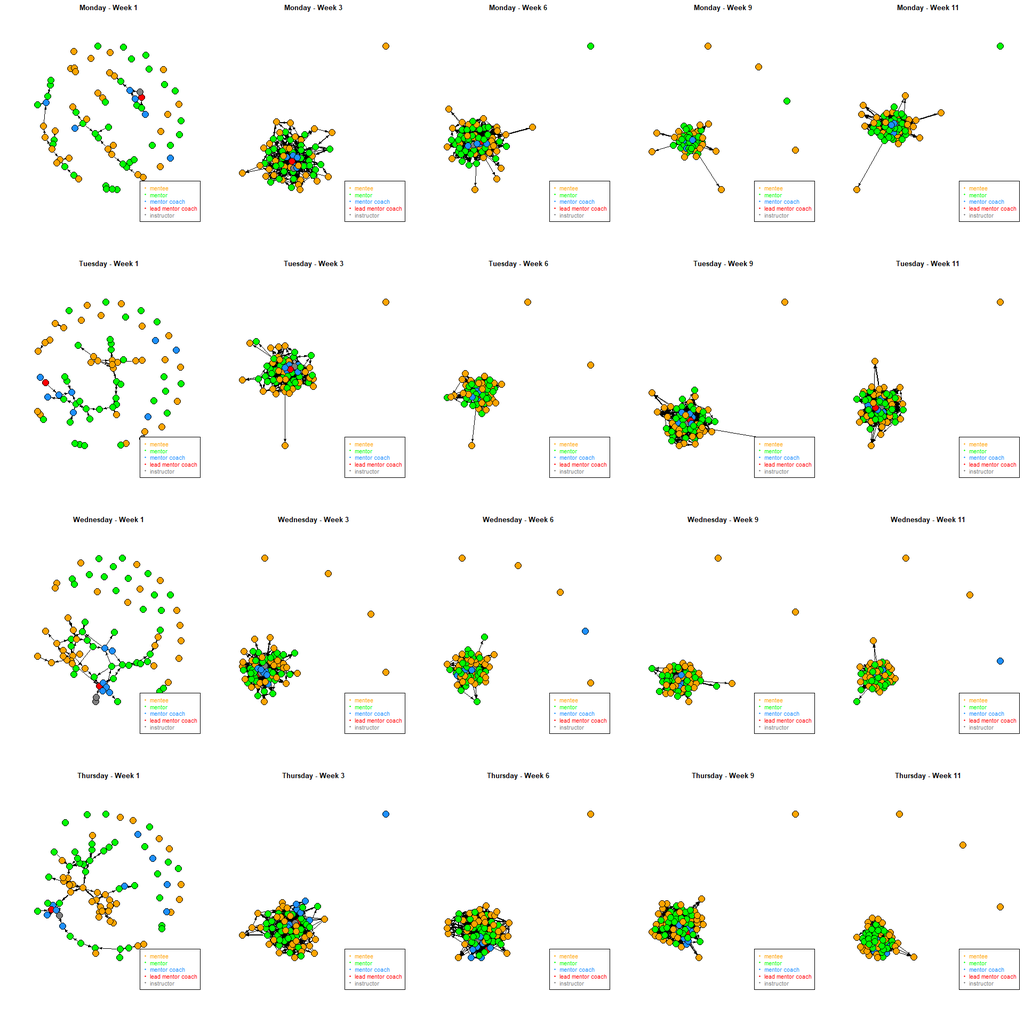

```r
  my_sn_g(thursday$graphs$g4,    title = "Thursday - Week 9")  ; my_leg(att = role, colors = color) #Social Network Graph ; Legend
  my_sn_g(thursday$graphs$g5,    title = "Thursday - Week 11") ; my_leg(att = role, colors = color) #Social Network Graph ; Legend
```

```r
#Plot With purrr::walk()
  #walk(.x = monday$graphs, .f = my_sn_g, title = "Monday");my_leg(role, color)
  #walk(.x = tuesday$graphs, .f = my_sn_g, title = "Tuesday");my_leg(role, color)
  #walk(.x =wednesday$graphs, .f = my_sn_g, title = "Wednesday");my_leg(role, color)
  #walk(.x = thursday$graphs, .f = my_sn_g, title = "Thursday");my_leg(role, color)
```

**Create Semester List**

```r
F15 <- list(monday = monday, tuesday = tuesday, wednesday = wednesday, thursday = thursday)
rm(monday);rm(tuesday);rm(wednesday);rm(thursday)
rm(temp)
```

## S16

```r
temp <- elmk %>% filter(semester == "S16")
mon <- temp %>% filter(night == "monday")
tue <- temp %>% filter(night == "tuesday")
wed <- temp %>% filter(night == "wednesday")
thu <- temp %>% filter(night == "thursday")
sem <- list(mon = mon,
            tue = tue,
            wed = wed,
            thu = thu)
rm(mon);rm(tue);rm(wed);rm(thu)
```

**Summary**

```r
sem$mon <- group_by(sem$mon, survnum)
sem$tue <- group_by(sem$tue, survnum)
sem$wed <- group_by(sem$wed, survnum)
sem$thu <- group_by(sem$thu, survnum)
summarize(sem$mon, day = "mon", n = length(unique(Sender_Final_ID)), tie_count = sum(sn1, na.rm = TRUE), tie_prop = (tie_count/nrow(sem$mon))*100)
```

| survnum | day | n | tie_count | tie_prop |
| --- | --- | --- | --- | --- |
| 1 | mon | 74 | 86 | 0.3438075 |
| 2 | mon | 71 | 454 | 1.8149836 |
| 3 | mon | 66 | 652 | 2.6065403 |
| 4 | mon | 66 | 799 | 3.1942112 |
| 5 | mon | 64 | 789 | 3.1542336 |

```r
summarize(sem$tue, day = "tue", n = length(unique(Sender_Final_ID)), tie_count = sum(sn1, na.rm = TRUE), tie_prop = (tie_count/nrow(sem$tue))*100)
```

| survnum | day | n | tie_count | tie_prop |
| --- | --- | --- | --- | --- |
| 1 | tue | 67 | 85 | 0.3643065 |
| 2 | tue | 68 | 419 | 1.7958169 |
| 3 | tue | 63 | 679 | 2.9101663 |
| 4 | tue | 64 | 923 | 3.9559403 |
| 5 | tue | 63 | 1062 | 4.5516887 |

```r
summarize(sem$wed, day = "wed", n = length(unique(Sender_Final_ID)), tie_count = sum(sn1, na.rm = TRUE), tie_prop = (tie_count/nrow(sem$wed))*100)
```

| survnum | day | n | tie_count | tie_prop |
| --- | --- | --- | --- | --- |
| 1 | wed | 75 | 110 | 0.4321182 |
| 2 | wed | 73 | 404 | 1.5870522 |
| 3 | wed | 66 | 674 | 2.6477058 |
| 4 | wed | 67 | 854 | 3.3548083 |
| 5 | wed | 67 | 917 | 3.6022942 |

```r
summarize(sem$thu, day = "thu", n = length(unique(Sender_Final_ID)), tie_count = sum(sn1, na.rm = TRUE), tie_prop = (tie_count/nrow(sem$thu))*100)
```

| survnum | day | n | tie_count | tie_prop |
| --- | --- | --- | --- | --- |
| 1 | thu | 72 | 136 | 0.5457245 |
| 2 | thu | 71 | 545 | 2.1869106 |
| 3 | thu | 70 | 827 | 3.3184864 |
| 4 | thu | 69 | 924 | 3.7077164 |
| 5 | thu | 69 | 1035 | 4.1531239 |

```r
sem$mon <- ungroup(sem$mon)
sem$tue <- ungroup(sem$tue)
sem$wed <- ungroup(sem$wed)
sem$thu <- ungroup(sem$thu)
rm(sem)
```

**Monday**

```r
temp_night <- temp            %>% filter(night == "monday")
temp_att   <- staff_youth_att %>% mutate(night =  "monday")
#Surv_1
surv_1 <- temp_night %>%
  filter(survnum == 1) %>%
  mutate(Receiver_Final_ID = ifelse(is.na(sn1), NA, Receiver_Final_ID)) #%>%
#Getting isolates
isolates1 <- surv_1 %>%
  mutate(sn1 = ifelse(is.na(sn1), 0, sn1)) %>%
  group_by(Sender_Final_ID) %>%
  summarize(isolate = sum(sn1)) %>%
  filter(isolate < 1) %>%
  select(Sender_Final_ID)
surv_1 <- surv_1 %>%
   select(Sender_Final_ID, Receiver_Final_ID) %>% filter(!(is.na(Receiver_Final_ID)))
#Surv 2
surv_2 <- temp_night %>%
  filter(survnum == 2) %>%
  mutate(Receiver_Final_ID = ifelse(is.na(sn1), NA, Receiver_Final_ID)) #%>%
#Getting isolates
isolates2 <- surv_2 %>%
  mutate(sn1 = ifelse(is.na(sn1), 0, sn1)) %>%
  group_by(Sender_Final_ID) %>%
  summarize(isolate = sum(sn1)) %>%
  filter(isolate < 1) %>%
  select(Sender_Final_ID)
surv_2 <- surv_2 %>%
   select(Sender_Final_ID, Receiver_Final_ID) %>% filter(!(is.na(Receiver_Final_ID)))
#Surv 3
surv_3 <- temp_night %>%
  filter(survnum == 3) %>%
  mutate(Receiver_Final_ID = ifelse(is.na(sn1), NA, Receiver_Final_ID)) #%>%
#Getting isolates
isolates3 <- surv_3 %>%
  mutate(sn1 = ifelse(is.na(sn1), 0, sn1)) %>%
  group_by(Sender_Final_ID) %>%
  summarize(isolate = sum(sn1)) %>%
  filter(isolate < 1) %>%
  select(Sender_Final_ID)
surv_3 <- surv_3 %>%
   select(Sender_Final_ID, Receiver_Final_ID) %>% filter(!(is.na(Receiver_Final_ID)))
#Surv 4
surv_4 <- temp_night %>%
  filter(survnum == 4) %>%
  mutate(Receiver_Final_ID = ifelse(is.na(sn1), NA, Receiver_Final_ID)) #%>%
#Getting isolates
isolates4 <- surv_4 %>%
  mutate(sn1 = ifelse(is.na(sn1), 0, sn1)) %>%
  group_by(Sender_Final_ID) %>%
  summarize(isolate = sum(sn1)) %>%
  filter(isolate < 1) %>%
  select(Sender_Final_ID)
surv_4 <- surv_4 %>%
   select(Sender_Final_ID, Receiver_Final_ID) %>% filter(!(is.na(Receiver_Final_ID)))
#Surv 5
surv_5 <- temp_night %>%
  filter(survnum == 5) %>%
  mutate(Receiver_Final_ID = ifelse(is.na(sn1), NA, Receiver_Final_ID)) #%>%
#Getting isolates
isolates5 <- surv_5 %>%
  mutate(sn1 = ifelse(is.na(sn1), 0, sn1)) %>%
  group_by(Sender_Final_ID) %>%
  summarize(isolate = sum(sn1)) %>%
  filter(isolate < 1) %>%
  select(Sender_Final_ID)
surv_5 <- surv_5 %>%
   select(Sender_Final_ID, Receiver_Final_ID) %>% filter(!(is.na(Receiver_Final_ID)))
day <- list(sur1 = surv_1,
            sur2 = surv_2,
            sur3 = surv_3,
            sur4 = surv_4,
            sur5 = surv_5,
            iso1 = isolates1,
            iso2 = isolates2,
            iso3 = isolates3,
            iso4 = isolates4,
            iso5 = isolates5)
rm(surv_1);rm(surv_2);rm(surv_3);rm(surv_4);rm(surv_5)
rm(isolates1);rm(isolates2);rm(isolates3);rm(isolates4);rm(isolates5)
```

**General Graphs**

```r
#Convert to Matrices
sur1 <- as.matrix(day$sur1)
sur2 <- as.matrix(day$sur2)
sur3 <- as.matrix(day$sur3)
sur4 <- as.matrix(day$sur4)
sur5 <- as.matrix(day$sur5)
# Convert matrix to an igraph object
g1 <- graph.edgelist(sur1, directed = TRUE) + vertices(day$iso1$Sender_Final_ID) #Graph edgelist + Add Isolates
g2 <- graph.edgelist(sur2, directed = TRUE) + vertices(day$iso2$Sender_Final_ID) #Graph edgelist + Add Isolates
g3 <- graph.edgelist(sur3, directed = TRUE) + vertices(day$iso3$Sender_Final_ID) #Graph edgelist + Add Isolates
g4 <- graph.edgelist(sur4, directed = TRUE) + vertices(day$iso4$Sender_Final_ID) #Graph edgelist + Add Isolates
g5 <- graph.edgelist(sur5, directed = TRUE) + vertices(day$iso5$Sender_Final_ID) #Graph edgelist + Add Isolates
#Capture Roles, Nights & Colors
temp_att <- temp_att %>%
  mutate(
         role1    = ifelse((!(is.na(role2)))     & (night2 == night), role2,     role1),
         night1   = ifelse((!(is.na(night2)))    & (night2 == night), night2,    night1),
         role_col = ifelse((!(is.na(role_col2))) & (night2 == night), role_col2, role_col)
         )
#Add staff Role Attribute
V(g1)$role  <- temp_att$role1[match(V(g1)$name, temp_att$Final_ID)]
V(g2)$role  <- temp_att$role1[match(V(g2)$name, temp_att$Final_ID)]
V(g3)$role  <- temp_att$role1[match(V(g3)$name, temp_att$Final_ID)]
V(g4)$role  <- temp_att$role1[match(V(g4)$name, temp_att$Final_ID)]
V(g5)$role  <- temp_att$role1[match(V(g5)$name, temp_att$Final_ID)]
#Add role colors
V(g1)$color <- temp_att$role_col[match(V(g1)$name, temp_att$Final_ID)]
V(g2)$color <- temp_att$role_col[match(V(g2)$name, temp_att$Final_ID)]
V(g3)$color <- temp_att$role_col[match(V(g3)$name, temp_att$Final_ID)]
V(g4)$color <- temp_att$role_col[match(V(g4)$name, temp_att$Final_ID)]
V(g5)$color <- temp_att$role_col[match(V(g5)$name, temp_att$Final_ID)]
#Add Edge weights - Match by edgelist rows Send/ Receive rows & temp_night Send/Receive rows. filter by survey.
w <- left_join(rename(as_data_frame(as_edgelist(g1)), Sender_Final_ID =V1, Receiver_Final_ID = V2), temp_night, by = c("Sender_Final_ID","Receiver_Final_ID")) %>%
                               filter(survnum == 1) #Match Weights
                           g1 <-  set_edge_attr(g1, "weight", value = w$sn2) #Add edge attribute
w <- left_join(rename(as_data_frame(as_edgelist(g2)), Sender_Final_ID =V1, Receiver_Final_ID = V2), temp_night, by = c("Sender_Final_ID","Receiver_Final_ID")) %>%
                               filter(survnum == 2) #Match weights
                           g2 <-  set_edge_attr(g2, "weight", value = w$sn2) #Add edge attribute
w <- left_join(rename(as_data_frame(as_edgelist(g3)), Sender_Final_ID =V1, Receiver_Final_ID = V2), temp_night, by = c("Sender_Final_ID","Receiver_Final_ID")) %>%
                               filter(survnum == 3) #Match weights
                           g3 <-  set_edge_attr(g3, "weight", value = w$sn2) #Add edge attribute
w <- left_join(rename(as_data_frame(as_edgelist(g4)), Sender_Final_ID =V1, Receiver_Final_ID = V2), temp_night, by = c("Sender_Final_ID","Receiver_Final_ID")) %>%
                               filter(survnum == 4) #Match weights
                           g4 <-  set_edge_attr(g4, "weight", value = w$sn2) #Add edge attribute
w <- left_join(rename(as_data_frame(as_edgelist(g5)), Sender_Final_ID =V1, Receiver_Final_ID = V2), temp_night, by = c("Sender_Final_ID","Receiver_Final_ID")) %>%
                               filter(survnum == 5) #Match weights
                           g5 <-  set_edge_attr(g5, "weight", value = w$sn2) #Add edge attribute
#Set graphs to list
graphs <- list(g1 = g1,g2 = g2, g3 = g3,g4 = g4, g5 = g5)
rm(g1); rm(g2); rm(g3); rm(g4); rm(g5)
rm(sur1);rm(sur2);rm(sur3);rm(sur4);rm(sur5)
rm(temp_att); rm(temp_night); rm(w)
```

**Create List**

```r
monday <- list(edgelists = day, graphs = graphs)
rm(day);rm(graphs)
```

**Tuesday**

```r
temp_night <- temp            %>% filter(night == "tuesday")
temp_att   <- staff_youth_att %>% mutate(night =  "tuesday")
#Surv_1
surv_1 <- temp_night %>%
  filter(survnum == 1) %>%
  mutate(Receiver_Final_ID = ifelse(is.na(sn1), NA, Receiver_Final_ID)) #%>%
#Getting isolates
isolates1 <- surv_1 %>%
  mutate(sn1 = ifelse(is.na(sn1), 0, sn1)) %>%
  group_by(Sender_Final_ID) %>%
  summarize(isolate = sum(sn1)) %>%
  filter(isolate < 1) %>%
  select(Sender_Final_ID)
surv_1 <- surv_1 %>%
   select(Sender_Final_ID, Receiver_Final_ID) %>% filter(!(is.na(Receiver_Final_ID)))
#Surv 2
surv_2 <- temp_night %>%
  filter(survnum == 2) %>%
  mutate(Receiver_Final_ID = ifelse(is.na(sn1), NA, Receiver_Final_ID)) #%>%
#Getting isolates
isolates2 <- surv_2 %>%
  mutate(sn1 = ifelse(is.na(sn1), 0, sn1)) %>%
  group_by(Sender_Final_ID) %>%
  summarize(isolate = sum(sn1)) %>%
  filter(isolate < 1) %>%
  select(Sender_Final_ID)
surv_2 <- surv_2 %>%
   select(Sender_Final_ID, Receiver_Final_ID) %>% filter(!(is.na(Receiver_Final_ID)))
#Surv 3
surv_3 <- temp_night %>%
  filter(survnum == 3) %>%
  mutate(Receiver_Final_ID = ifelse(is.na(sn1), NA, Receiver_Final_ID)) #%>%
#Getting isolates
isolates3 <- surv_3 %>%
  mutate(sn1 = ifelse(is.na(sn1), 0, sn1)) %>%
  group_by(Sender_Final_ID) %>%
  summarize(isolate = sum(sn1)) %>%
  filter(isolate < 1) %>%
  select(Sender_Final_ID)
surv_3 <- surv_3 %>%
   select(Sender_Final_ID, Receiver_Final_ID) %>% filter(!(is.na(Receiver_Final_ID)))
#Surv 4
surv_4 <- temp_night %>%
  filter(survnum == 4) %>%
  mutate(Receiver_Final_ID = ifelse(is.na(sn1), NA, Receiver_Final_ID)) #%>%
#Getting isolates
isolates4 <- surv_4 %>%
  mutate(sn1 = ifelse(is.na(sn1), 0, sn1)) %>%
  group_by(Sender_Final_ID) %>%
  summarize(isolate = sum(sn1)) %>%
  filter(isolate < 1) %>%
  select(Sender_Final_ID)
surv_4 <- surv_4 %>%
   select(Sender_Final_ID, Receiver_Final_ID) %>% filter(!(is.na(Receiver_Final_ID)))
#Surv 5
surv_5 <- temp_night %>%
  filter(survnum == 5) %>%
  mutate(Receiver_Final_ID = ifelse(is.na(sn1), NA, Receiver_Final_ID)) #%>%
#Getting isolates
isolates5 <- surv_5 %>%
  mutate(sn1 = ifelse(is.na(sn1), 0, sn1)) %>%
  group_by(Sender_Final_ID) %>%
  summarize(isolate = sum(sn1)) %>%
  filter(isolate < 1) %>%
  select(Sender_Final_ID)
surv_5 <- surv_5 %>%
   select(Sender_Final_ID, Receiver_Final_ID) %>% filter(!(is.na(Receiver_Final_ID)))
day <- list(sur1 = surv_1,
            sur2 = surv_2,
            sur3 = surv_3,
            sur4 = surv_4,
            sur5 = surv_5,
            iso1 = isolates1,
            iso2 = isolates2,
            iso3 = isolates3,
            iso4 = isolates4,
            iso5 = isolates5)
rm(surv_1);rm(surv_2);rm(surv_3);rm(surv_4);rm(surv_5)
rm(isolates1);rm(isolates2);rm(isolates3);rm(isolates4);rm(isolates5)
```

**General Graphs**

```r
#Convert to Matrices
sur1 <- as.matrix(day$sur1)
sur2 <- as.matrix(day$sur2)
sur3 <- as.matrix(day$sur3)
sur4 <- as.matrix(day$sur4)
sur5 <- as.matrix(day$sur5)
# Convert matrix to an igraph object
g1 <- graph.edgelist(sur1, directed = TRUE) + vertices(day$iso1$Sender_Final_ID) #Graph edgelist + Add Isolates
g2 <- graph.edgelist(sur2, directed = TRUE) + vertices(day$iso2$Sender_Final_ID) #Graph edgelist + Add Isolates
g3 <- graph.edgelist(sur3, directed = TRUE) + vertices(day$iso3$Sender_Final_ID) #Graph edgelist + Add Isolates
g4 <- graph.edgelist(sur4, directed = TRUE) + vertices(day$iso4$Sender_Final_ID) #Graph edgelist + Add Isolates
g5 <- graph.edgelist(sur5, directed = TRUE) + vertices(day$iso5$Sender_Final_ID) #Graph edgelist + Add Isolates
#Capture Roles, Nights & Colors
temp_att <- temp_att %>%
  mutate(
         role1    = ifelse((!(is.na(role2)))     & (night2 == night), role2,     role1),
         night1   = ifelse((!(is.na(night2)))    & (night2 == night), night2,    night1),
         role_col = ifelse((!(is.na(role_col2))) & (night2 == night), role_col2, role_col)
         )
#Add staff Role Attribute
V(g1)$role  <- temp_att$role1[match(V(g1)$name, temp_att$Final_ID)]
V(g2)$role  <- temp_att$role1[match(V(g2)$name, temp_att$Final_ID)]
V(g3)$role  <- temp_att$role1[match(V(g3)$name, temp_att$Final_ID)]
V(g4)$role  <- temp_att$role1[match(V(g4)$name, temp_att$Final_ID)]
V(g5)$role  <- temp_att$role1[match(V(g5)$name, temp_att$Final_ID)]
#Add role colors
V(g1)$color <- temp_att$role_col[match(V(g1)$name, temp_att$Final_ID)]
V(g2)$color <- temp_att$role_col[match(V(g2)$name, temp_att$Final_ID)]
V(g3)$color <- temp_att$role_col[match(V(g3)$name, temp_att$Final_ID)]
V(g4)$color <- temp_att$role_col[match(V(g4)$name, temp_att$Final_ID)]
V(g5)$color <- temp_att$role_col[match(V(g5)$name, temp_att$Final_ID)]
#Add Edge weights - Match by edgelist rows Send/ Receive rows & temp_night Send/Receive rows. filter by survey.
w <- left_join(rename(as_data_frame(as_edgelist(g1)), Sender_Final_ID =V1, Receiver_Final_ID = V2), temp_night, by = c("Sender_Final_ID","Receiver_Final_ID")) %>%
                               filter(survnum == 1) #Match Weights
                           g1 <-  set_edge_attr(g1, "weight", value = w$sn2) #Add edge attribute
w <- left_join(rename(as_data_frame(as_edgelist(g2)), Sender_Final_ID =V1, Receiver_Final_ID = V2), temp_night, by = c("Sender_Final_ID","Receiver_Final_ID")) %>%
                               filter(survnum == 2) #Match weights
                           g2 <-  set_edge_attr(g2, "weight", value = w$sn2) #Add edge attribute
w <- left_join(rename(as_data_frame(as_edgelist(g3)), Sender_Final_ID =V1, Receiver_Final_ID = V2), temp_night, by = c("Sender_Final_ID","Receiver_Final_ID")) %>%
                               filter(survnum == 3) #Match weights
                           g3 <-  set_edge_attr(g3, "weight", value = w$sn2) #Add edge attribute
w <- left_join(rename(as_data_frame(as_edgelist(g4)), Sender_Final_ID =V1, Receiver_Final_ID = V2), temp_night, by = c("Sender_Final_ID","Receiver_Final_ID")) %>%
                               filter(survnum == 4) #Match weights
                           g4 <-  set_edge_attr(g4, "weight", value = w$sn2) #Add edge attribute
w <- left_join(rename(as_data_frame(as_edgelist(g5)), Sender_Final_ID =V1, Receiver_Final_ID = V2), temp_night, by = c("Sender_Final_ID","Receiver_Final_ID")) %>%
                               filter(survnum == 5) #Match weights
                           g5 <-  set_edge_attr(g5, "weight", value = w$sn2) #Add edge attribute
#Set graphs to list
graphs <- list(g1 = g1,g2 = g2, g3 = g3,g4 = g4, g5 = g5)
rm(g1); rm(g2); rm(g3); rm(g4); rm(g5)
rm(sur1);rm(sur2);rm(sur3);rm(sur4);rm(sur5)
rm(temp_att); rm(temp_night); rm(w)
```

**Create List**

```r
tuesday <- list(edgelists = day, graphs = graphs)
rm(day); rm(graphs)
```

**Wednesday**

```r
temp_night <- temp            %>% filter(night == "wednesday")
temp_att   <- staff_youth_att %>% mutate(night =  "wednesday")
#Surv_1
surv_1 <- temp_night %>%
  filter(survnum == 1) %>%
  mutate(Receiver_Final_ID = ifelse(is.na(sn1), NA, Receiver_Final_ID)) #%>%
#Getting isolates
isolates1 <- surv_1 %>%
  mutate(sn1 = ifelse(is.na(sn1), 0, sn1)) %>%
  group_by(Sender_Final_ID) %>%
  summarize(isolate = sum(sn1)) %>%
  filter(isolate < 1) %>%
  select(Sender_Final_ID)
surv_1 <- surv_1 %>%
   select(Sender_Final_ID, Receiver_Final_ID) %>% filter(!(is.na(Receiver_Final_ID)))
#Surv 2
surv_2 <- temp_night %>%
  filter(survnum == 2) %>%
  mutate(Receiver_Final_ID = ifelse(is.na(sn1), NA, Receiver_Final_ID)) #%>%
#Getting isolates
isolates2 <- surv_2 %>%
  mutate(sn1 = ifelse(is.na(sn1), 0, sn1)) %>%
  group_by(Sender_Final_ID) %>%
  summarize(isolate = sum(sn1)) %>%
  filter(isolate < 1) %>%
  select(Sender_Final_ID)
surv_2 <- surv_2 %>%
   select(Sender_Final_ID, Receiver_Final_ID) %>% filter(!(is.na(Receiver_Final_ID)))
#Surv 3
surv_3 <- temp_night %>%
  filter(survnum == 3) %>%
  mutate(Receiver_Final_ID = ifelse(is.na(sn1), NA, Receiver_Final_ID)) #%>%
#Getting isolates
isolates3 <- surv_3 %>%
  mutate(sn1 = ifelse(is.na(sn1), 0, sn1)) %>%
  group_by(Sender_Final_ID) %>%
  summarize(isolate = sum(sn1)) %>%
  filter(isolate < 1) %>%
  select(Sender_Final_ID)
surv_3 <- surv_3 %>%
   select(Sender_Final_ID, Receiver_Final_ID) %>% filter(!(is.na(Receiver_Final_ID)))
#Surv 4
surv_4 <- temp_night %>%
  filter(survnum == 4) %>%
  mutate(Receiver_Final_ID = ifelse(is.na(sn1), NA, Receiver_Final_ID)) #%>%
#Getting isolates
isolates4 <- surv_4 %>%
  mutate(sn1 = ifelse(is.na(sn1), 0, sn1)) %>%
  group_by(Sender_Final_ID) %>%
  summarize(isolate = sum(sn1)) %>%
  filter(isolate < 1) %>%
  select(Sender_Final_ID)
surv_4 <- surv_4 %>%
   select(Sender_Final_ID, Receiver_Final_ID) %>% filter(!(is.na(Receiver_Final_ID)))
#Surv 5
surv_5 <- temp_night %>%
  filter(survnum == 5) %>%
  mutate(Receiver_Final_ID = ifelse(is.na(sn1), NA, Receiver_Final_ID)) #%>%
#Getting isolates
isolates5 <- surv_5 %>%
  mutate(sn1 = ifelse(is.na(sn1), 0, sn1)) %>%
  group_by(Sender_Final_ID) %>%
  summarize(isolate = sum(sn1)) %>%
  filter(isolate < 1) %>%
  select(Sender_Final_ID)
surv_5 <- surv_5 %>%
   select(Sender_Final_ID, Receiver_Final_ID) %>% filter(!(is.na(Receiver_Final_ID)))
day <- list(sur1 = surv_1,
            sur2 = surv_2,
            sur3 = surv_3,
            sur4 = surv_4,
            sur5 = surv_5,
            iso1 = isolates1,
            iso2 = isolates2,
            iso3 = isolates3,
            iso4 = isolates4,
            iso5 = isolates5)
rm(surv_1);rm(surv_2);rm(surv_3);rm(surv_4);rm(surv_5)
rm(isolates1);rm(isolates2);rm(isolates3);rm(isolates4);rm(isolates5)
```

**General Graphs**

```r
#Convert to Matrices
sur1 <- as.matrix(day$sur1)
sur2 <- as.matrix(day$sur2)
sur3 <- as.matrix(day$sur3)
sur4 <- as.matrix(day$sur4)
sur5 <- as.matrix(day$sur5)
# Convert matrix to an igraph object
g1 <- graph.edgelist(sur1, directed = TRUE) + vertices(day$iso1$Sender_Final_ID) #Graph edgelist + Add Isolates
g2 <- graph.edgelist(sur2, directed = TRUE) + vertices(day$iso2$Sender_Final_ID) #Graph edgelist + Add Isolates
g3 <- graph.edgelist(sur3, directed = TRUE) + vertices(day$iso3$Sender_Final_ID) #Graph edgelist + Add Isolates
g4 <- graph.edgelist(sur4, directed = TRUE) + vertices(day$iso4$Sender_Final_ID) #Graph edgelist + Add Isolates
g5 <- graph.edgelist(sur5, directed = TRUE) + vertices(day$iso5$Sender_Final_ID) #Graph edgelist + Add Isolates
#Capture Roles, Nights & Colors
temp_att <- temp_att %>%
  mutate(
         role1    = ifelse((!(is.na(role2)))     & (night2 == night), role2,     role1),
         night1   = ifelse((!(is.na(night2)))    & (night2 == night), night2,    night1),
         role_col = ifelse((!(is.na(role_col2))) & (night2 == night), role_col2, role_col)
         )
#Add staff Role Attribute
V(g1)$role  <- temp_att$role1[match(V(g1)$name, temp_att$Final_ID)]
V(g2)$role  <- temp_att$role1[match(V(g2)$name, temp_att$Final_ID)]
V(g3)$role  <- temp_att$role1[match(V(g3)$name, temp_att$Final_ID)]
V(g4)$role  <- temp_att$role1[match(V(g4)$name, temp_att$Final_ID)]
V(g5)$role  <- temp_att$role1[match(V(g5)$name, temp_att$Final_ID)]
#Add role colors
V(g1)$color <- temp_att$role_col[match(V(g1)$name, temp_att$Final_ID)]
V(g2)$color <- temp_att$role_col[match(V(g2)$name, temp_att$Final_ID)]
V(g3)$color <- temp_att$role_col[match(V(g3)$name, temp_att$Final_ID)]
V(g4)$color <- temp_att$role_col[match(V(g4)$name, temp_att$Final_ID)]
V(g5)$color <- temp_att$role_col[match(V(g5)$name, temp_att$Final_ID)]
#Add Edge weights - Match by edgelist rows Send/ Receive rows & temp_night Send/Receive rows. filter by survey.
w <- left_join(rename(as_data_frame(as_edgelist(g1)), Sender_Final_ID =V1, Receiver_Final_ID = V2), temp_night, by = c("Sender_Final_ID","Receiver_Final_ID")) %>%
                               filter(survnum == 1) #Match Weights
                           g1 <-  set_edge_attr(g1, "weight", value = w$sn2) #Add edge attribute
w <- left_join(rename(as_data_frame(as_edgelist(g2)), Sender_Final_ID =V1, Receiver_Final_ID = V2), temp_night, by = c("Sender_Final_ID","Receiver_Final_ID")) %>%
                               filter(survnum == 2) #Match weights
                           g2 <-  set_edge_attr(g2, "weight", value = w$sn2) #Add edge attribute
w <- left_join(rename(as_data_frame(as_edgelist(g3)), Sender_Final_ID =V1, Receiver_Final_ID = V2), temp_night, by = c("Sender_Final_ID","Receiver_Final_ID")) %>%
                               filter(survnum == 3) #Match weights
                           g3 <-  set_edge_attr(g3, "weight", value = w$sn2) #Add edge attribute
w <- left_join(rename(as_data_frame(as_edgelist(g4)), Sender_Final_ID =V1, Receiver_Final_ID = V2), temp_night, by = c("Sender_Final_ID","Receiver_Final_ID")) %>%
                               filter(survnum == 4) #Match weights
                           g4 <-  set_edge_attr(g4, "weight", value = w$sn2) #Add edge attribute
w <- left_join(rename(as_data_frame(as_edgelist(g5)), Sender_Final_ID =V1, Receiver_Final_ID = V2), temp_night, by = c("Sender_Final_ID","Receiver_Final_ID")) %>%
                               filter(survnum == 5) #Match weights
                           g5 <-  set_edge_attr(g5, "weight", value = w$sn2) #Add edge attribute
#Set graphs to list
graphs <- list(g1 = g1,g2 = g2, g3 = g3,g4 = g4, g5 = g5)
rm(g1); rm(g2); rm(g3); rm(g4); rm(g5)
rm(sur1);rm(sur2);rm(sur3);rm(sur4);rm(sur5)
rm(temp_att); rm(temp_night); rm(w)
```

**Create List**

```r
wednesday <- list(edgelists = day, graphs = graphs)
rm(day); rm(graphs)
```

**Thursday**

```r
temp_night <- temp            %>% filter(night == "thursday")
temp_att   <- staff_youth_att %>% mutate(night =  "thursday")
#Surv_1
surv_1 <- temp_night %>%
  filter(survnum == 1) %>%
  mutate(Receiver_Final_ID = ifelse(is.na(sn1), NA, Receiver_Final_ID)) #%>%
#Getting isolates
isolates1 <- surv_1 %>%
  mutate(sn1 = ifelse(is.na(sn1), 0, sn1)) %>%
  group_by(Sender_Final_ID) %>%
  summarize(isolate = sum(sn1)) %>%
  filter(isolate < 1) %>%
  select(Sender_Final_ID)
surv_1 <- surv_1 %>%
   select(Sender_Final_ID, Receiver_Final_ID) %>% filter(!(is.na(Receiver_Final_ID)))
#Surv 2
surv_2 <- temp_night %>%
  filter(survnum == 2) %>%
  mutate(Receiver_Final_ID = ifelse(is.na(sn1), NA, Receiver_Final_ID)) #%>%
#Getting isolates
isolates2 <- surv_2 %>%
  mutate(sn1 = ifelse(is.na(sn1), 0, sn1)) %>%
  group_by(Sender_Final_ID) %>%
  summarize(isolate = sum(sn1)) %>%
  filter(isolate < 1) %>%
  select(Sender_Final_ID)
surv_2 <- surv_2 %>%
   select(Sender_Final_ID, Receiver_Final_ID) %>% filter(!(is.na(Receiver_Final_ID)))
#Surv 3
surv_3 <- temp_night %>%
  filter(survnum == 3) %>%
  mutate(Receiver_Final_ID = ifelse(is.na(sn1), NA, Receiver_Final_ID)) #%>%
#Getting isolates
isolates3 <- surv_3 %>%
  mutate(sn1 = ifelse(is.na(sn1), 0, sn1)) %>%
  group_by(Sender_Final_ID) %>%
  summarize(isolate = sum(sn1)) %>%
  filter(isolate < 1) %>%
  select(Sender_Final_ID)
surv_3 <- surv_3 %>%
   select(Sender_Final_ID, Receiver_Final_ID) %>% filter(!(is.na(Receiver_Final_ID)))
#Surv 4
surv_4 <- temp_night %>%
  filter(survnum == 4) %>%
  mutate(Receiver_Final_ID = ifelse(is.na(sn1), NA, Receiver_Final_ID)) #%>%
#Getting isolates
isolates4 <- surv_4 %>%
  mutate(sn1 = ifelse(is.na(sn1), 0, sn1)) %>%
  group_by(Sender_Final_ID) %>%
  summarize(isolate = sum(sn1)) %>%
  filter(isolate < 1) %>%
  select(Sender_Final_ID)
surv_4 <- surv_4 %>%
   select(Sender_Final_ID, Receiver_Final_ID) %>% filter(!(is.na(Receiver_Final_ID)))
#Surv 5
surv_5 <- temp_night %>%
  filter(survnum == 5) %>%
  mutate(Receiver_Final_ID = ifelse(is.na(sn1), NA, Receiver_Final_ID)) #%>%
#Getting isolates
isolates5 <- surv_5 %>%
  mutate(sn1 = ifelse(is.na(sn1), 0, sn1)) %>%
  group_by(Sender_Final_ID) %>%
  summarize(isolate = sum(sn1)) %>%
  filter(isolate < 1) %>%
  select(Sender_Final_ID)
surv_5 <- surv_5 %>%
   select(Sender_Final_ID, Receiver_Final_ID) %>% filter(!(is.na(Receiver_Final_ID)))
day <- list(sur1 = surv_1,
            sur2 = surv_2,
            sur3 = surv_3,
            sur4 = surv_4,
            sur5 = surv_5,
            iso1 = isolates1,
            iso2 = isolates2,
            iso3 = isolates3,
            iso4 = isolates4,
            iso5 = isolates5)
rm(surv_1);rm(surv_2);rm(surv_3);rm(surv_4);rm(surv_5)
rm(isolates1);rm(isolates2);rm(isolates3);rm(isolates4);rm(isolates5)
```

**General Graphs**

```r
#Convert to Matrices
sur1 <- as.matrix(day$sur1)
sur2 <- as.matrix(day$sur2)
sur3 <- as.matrix(day$sur3)
sur4 <- as.matrix(day$sur4)
sur5 <- as.matrix(day$sur5)
# Convert matrix to an igraph object
g1 <- graph.edgelist(sur1, directed = TRUE) + vertices(day$iso1$Sender_Final_ID) #Graph edgelist + Add Isolates
g2 <- graph.edgelist(sur2, directed = TRUE) + vertices(day$iso2$Sender_Final_ID) #Graph edgelist + Add Isolates
g3 <- graph.edgelist(sur3, directed = TRUE) + vertices(day$iso3$Sender_Final_ID) #Graph edgelist + Add Isolates
g4 <- graph.edgelist(sur4, directed = TRUE) + vertices(day$iso4$Sender_Final_ID) #Graph edgelist + Add Isolates
g5 <- graph.edgelist(sur5, directed = TRUE) + vertices(day$iso5$Sender_Final_ID) #Graph edgelist + Add Isolates
#Capture Roles, Nights & Colors
temp_att <- temp_att %>%
  mutate(
         role1    = ifelse((!(is.na(role2)))     & (night2 == night), role2,     role1),
         night1   = ifelse((!(is.na(night2)))    & (night2 == night), night2,    night1),
         role_col = ifelse((!(is.na(role_col2))) & (night2 == night), role_col2, role_col)
         )
#Add staff Role Attribute
V(g1)$role  <- temp_att$role1[match(V(g1)$name, temp_att$Final_ID)]
V(g2)$role  <- temp_att$role1[match(V(g2)$name, temp_att$Final_ID)]
V(g3)$role  <- temp_att$role1[match(V(g3)$name, temp_att$Final_ID)]
V(g4)$role  <- temp_att$role1[match(V(g4)$name, temp_att$Final_ID)]
V(g5)$role  <- temp_att$role1[match(V(g5)$name, temp_att$Final_ID)]
#Add role colors
V(g1)$color <- temp_att$role_col[match(V(g1)$name, temp_att$Final_ID)]
V(g2)$color <- temp_att$role_col[match(V(g2)$name, temp_att$Final_ID)]
V(g3)$color <- temp_att$role_col[match(V(g3)$name, temp_att$Final_ID)]
V(g4)$color <- temp_att$role_col[match(V(g4)$name, temp_att$Final_ID)]
V(g5)$color <- temp_att$role_col[match(V(g5)$name, temp_att$Final_ID)]
#Add Edge weights - Match by edgelist rows Send/ Receive rows & temp_night Send/Receive rows. filter by survey.
w <- left_join(rename(as_data_frame(as_edgelist(g1)), Sender_Final_ID =V1, Receiver_Final_ID = V2), temp_night, by = c("Sender_Final_ID","Receiver_Final_ID")) %>%
                               filter(survnum == 1) #Match Weights
                           g1 <-  set_edge_attr(g1, "weight", value = w$sn2) #Add edge attribute
w <- left_join(rename(as_data_frame(as_edgelist(g2)), Sender_Final_ID =V1, Receiver_Final_ID = V2), temp_night, by = c("Sender_Final_ID","Receiver_Final_ID")) %>%
                               filter(survnum == 2) #Match weights
                           g2 <-  set_edge_attr(g2, "weight", value = w$sn2) #Add edge attribute
w <- left_join(rename(as_data_frame(as_edgelist(g3)), Sender_Final_ID =V1, Receiver_Final_ID = V2), temp_night, by = c("Sender_Final_ID","Receiver_Final_ID")) %>%
                               filter(survnum == 3) #Match weights
                           g3 <-  set_edge_attr(g3, "weight", value = w$sn2) #Add edge attribute
w <- left_join(rename(as_data_frame(as_edgelist(g4)), Sender_Final_ID =V1, Receiver_Final_ID = V2), temp_night, by = c("Sender_Final_ID","Receiver_Final_ID")) %>%
                               filter(survnum == 4) #Match weights
                           g4 <-  set_edge_attr(g4, "weight", value = w$sn2) #Add edge attribute
w <- left_join(rename(as_data_frame(as_edgelist(g5)), Sender_Final_ID =V1, Receiver_Final_ID = V2), temp_night, by = c("Sender_Final_ID","Receiver_Final_ID")) %>%
                               filter(survnum == 5) #Match weights
                           g5 <-  set_edge_attr(g5, "weight", value = w$sn2) #Add edge attribute
#Set graphs to list
graphs <- list(g1 = g1,g2 = g2, g3 = g3,g4 = g4, g5 = g5)
rm(g1); rm(g2); rm(g3); rm(g4); rm(g5)
rm(sur1);rm(sur2);rm(sur3);rm(sur4);rm(sur5)
rm(temp_att); rm(temp_night); rm(w)
```

**Create List**

```r
thursday <- list(edgelists = day, graphs = graphs)
rm(day); rm(graphs)
```

### Plot Graphs

```r
#Set chart image
par(mfrow=c(4,5))
#Monday Graphs
   my_sn_g(monday$graphs$g1,      title = "Monday - Week 1")  ; my_leg(att = role, colors = color) #Social Network Graph ; Legend
   my_sn_g(monday$graphs$g2,      title = "Monday - Week 3")  ; my_leg(att = role, colors = color) #Social Network Graph ; Legend
```

```r
   my_sn_g(monday$graphs$g3,      title = "Monday - Week 6")  ; my_leg(att = role, colors = color) #Social Network Graph ; Legend
   my_sn_g(monday$graphs$g4,      title = "Monday - Week 9")  ; my_leg(att = role, colors = color) #Social Network Graph ; Legend
```

```r
   my_sn_g(monday$graphs$g5,      title = "Monday - Week 11") ; my_leg(att = role, colors = color) #Social Network Graph ; Legend

#Tuesday Graphs

  my_sn_g(tuesday$graphs$g1,     title = "Tuesday - Week 1")  ; my_leg(att = role, colors = color) #Social Network Graph ; Legend
```

```r
  my_sn_g(tuesday$graphs$g2,     title = "Tuesday - Week 3")  ; my_leg(att = role, colors = color) #Social Network Graph ; Legend
  my_sn_g(tuesday$graphs$g3,     title = "Tuesday - Week 6")  ; my_leg(att = role, colors = color) #Social Network Graph ; Legend
```

```r
  my_sn_g(tuesday$graphs$g4,     title = "Tuesday - Week 9")  ; my_leg(att = role, colors = color) #Social Network Graph ; Legend
  my_sn_g(tuesday$graphs$g5,     title = "Tuesday - Week 11") ; my_leg(att = role, colors = color) #Social Network Graph ; Legend
```

```r
#Wednesday Graphs

  my_sn_g(wednesday$graphs$g1,   title = "Wednesday - Week 1")  ; my_leg(att = role, colors = color) #Social Network Graph ; Legend
  my_sn_g(wednesday$graphs$g2,   title = "Wednesday - Week 3")  ; my_leg(att = role, colors = color) #Social Network Graph ; Legend
```

```r
  my_sn_g(wednesday$graphs$g3,   title = "Wednesday - Week 6")  ; my_leg(att = role, colors = color) #Social Network Graph ; Legend
  my_sn_g(wednesday$graphs$g4,   title = "Wednesday - Week 9")  ; my_leg(att = role, colors = color) #Social Network Graph ; Legend
```

```r
  my_sn_g(wednesday$graphs$g5,   title = "Wednesday - Week 11") ; my_leg(att = role, colors = color) #Social Network Graph ; Legend
  my_sn_g(thursday$graphs$g1,    title = "Thursday - Week 1")  ; my_leg(att = role, colors = color) #Social Network Graph ; Legend
```

```r
  my_sn_g(thursday$graphs$g2,    title = "Thursday - Week 3")  ; my_leg(att = role, colors = color) #Social Network Graph ; Legend
  my_sn_g(thursday$graphs$g3,    title = "Thursday - Week 6")  ; my_leg(att = role, colors = color) #Social Network Graph ; Legend
```

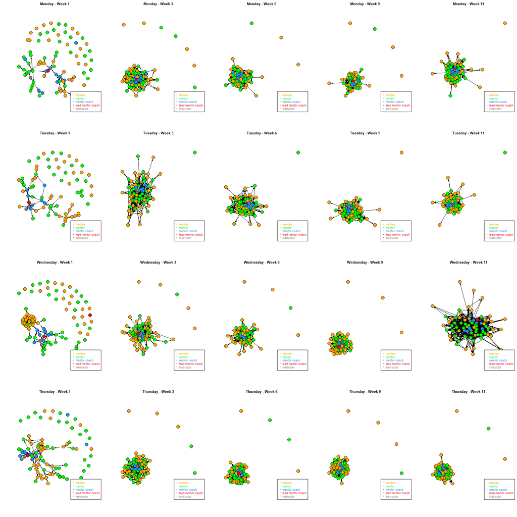

```r
  my_sn_g(thursday$graphs$g4,    title = "Thursday - Week 9")  ; my_leg(att = role, colors = color) #Social Network Graph ; Legend
  my_sn_g(thursday$graphs$g5,    title = "Thursday - Week 11") ; my_leg(att = role, colors = color) #Social Network Graph ; Legend
```

```r
#Plot With purrr::walk()
  #walk(.x = monday$graphs, .f = my_sn_g, title = "Monday");my_leg(role, color)
  #walk(.x = tuesday$graphs, .f = my_sn_g, title = "Tuesday");my_leg(role, color)
  #walk(.x =wednesday$graphs, .f = my_sn_g, title = "Wednesday");my_leg(role, color)
  #walk(.x = thursday$graphs, .f = my_sn_g, title = "Thursday");my_leg(role, color)
```

**Create Semester List**

```r
S16 <- list(monday = monday, tuesday = tuesday, wednesday = wednesday, thursday = thursday)
rm(monday);rm(tuesday);rm(wednesday);rm(thursday)
rm(temp)
```

## F16

```r
temp <- elmk %>% filter(semester == "F16")
mon <- temp %>% filter(night == "monday")
tue <- temp %>% filter(night == "tuesday")
wed <- temp %>% filter(night == "wednesday")
thu <- temp %>% filter(night == "thursday")
sem <- list(mon = mon,
            tue = tue,
            wed = wed,
            thu = thu)
rm(mon);rm(tue);rm(wed);rm(thu)
```

**Summary**

```r
sem$mon <- group_by(sem$mon, survnum)
sem$tue <- group_by(sem$tue, survnum)
sem$wed <- group_by(sem$wed, survnum)
sem$thu <- group_by(sem$thu, survnum)
summarize(sem$mon, day = "mon", n = length(unique(Sender_Final_ID)), tie_count = sum(sn1, na.rm = TRUE), tie_prop = (tie_count/nrow(sem$mon))*100)
```

| survnum | day | n | tie_count | tie_prop |
| --- | --- | --- | --- | --- |
| 1 | mon | 63 | 73 | 0.3827199 |
| 2 | mon | 60 | 482 | 2.5270001 |
| 3 | mon | 60 | 705 | 3.6961309 |
| 4 | mon | 58 | 794 | 4.1627346 |
| 5 | mon | 58 | 842 | 4.4143861 |

```r
summarize(sem$tue, day = "tue", n = length(unique(Sender_Final_ID)), tie_count = sum(sn1, na.rm = TRUE), tie_prop = (tie_count/nrow(sem$tue))*100)
```

| survnum | day | n | tie_count | tie_prop |
| --- | --- | --- | --- | --- |
| 1 | tue | 64 | 76 | 0.3942318 |
| 2 | tue | 61 | 319 | 1.6547360 |
| 3 | tue | 61 | 623 | 3.2316630 |
| 4 | tue | 60 | 804 | 4.1705571 |
| 5 | tue | 60 | 912 | 4.7307812 |

```r
summarize(sem$wed, day = "wed", n = length(unique(Sender_Final_ID)), tie_count = sum(sn1, na.rm = TRUE), tie_prop = (tie_count/nrow(sem$wed))*100)
```

| survnum | day | n | tie_count | tie_prop |
| --- | --- | --- | --- | --- |
| 1 | wed | 66 | 93 | 0.4657685 |
| 2 | wed | 64 | 382 | 1.9131567 |
| 3 | wed | 62 | 632 | 3.1652226 |
| 4 | wed | 62 | 808 | 4.0466770 |
| 5 | wed | 60 | 716 | 3.5859168 |

```r
summarize(sem$thu, day = "thu", n = length(unique(Sender_Final_ID)), tie_count = sum(sn1, na.rm = TRUE), tie_prop = (tie_count/nrow(sem$thu))*100)
```

| survnum | day | n | tie_count | tie_prop |
| --- | --- | --- | --- | --- |
| 1 | thu | 64 | 96 | 0.4739804 |
| 2 | thu | 62 | 535 | 2.6414535 |
| 3 | thu | 62 | 814 | 4.0189592 |
| 4 | thu | 61 | 909 | 4.4880024 |
| 5 | thu | 58 | 902 | 4.4534413 |

```r
sem$mon <- ungroup(sem$mon)
sem$tue <- ungroup(sem$tue)
sem$wed <- ungroup(sem$wed)
sem$thu <- ungroup(sem$thu)
rm(sem)
```

**Monday**

```r
temp_night <- temp            %>% filter(night == "monday")
temp_att   <- staff_youth_att %>% mutate(night =  "monday")
#Surv_1
surv_1 <- temp_night %>%
  filter(survnum == 1) %>%
  mutate(Receiver_Final_ID = ifelse(is.na(sn1), NA, Receiver_Final_ID)) #%>%
#Getting isolates
isolates1 <- surv_1 %>%
  mutate(sn1 = ifelse(is.na(sn1), 0, sn1)) %>%
  group_by(Sender_Final_ID) %>%
  summarize(isolate = sum(sn1)) %>%
  filter(isolate < 1) %>%
  select(Sender_Final_ID)
surv_1 <- surv_1 %>%
   select(Sender_Final_ID, Receiver_Final_ID) %>% filter(!(is.na(Receiver_Final_ID)))
#Surv 2
surv_2 <- temp_night %>%
  filter(survnum == 2) %>%
  mutate(Receiver_Final_ID = ifelse(is.na(sn1), NA, Receiver_Final_ID)) #%>%
#Getting isolates
isolates2 <- surv_2 %>%
  mutate(sn1 = ifelse(is.na(sn1), 0, sn1)) %>%
  group_by(Sender_Final_ID) %>%
  summarize(isolate = sum(sn1)) %>%
  filter(isolate < 1) %>%
  select(Sender_Final_ID)
surv_2 <- surv_2 %>%
   select(Sender_Final_ID, Receiver_Final_ID) %>% filter(!(is.na(Receiver_Final_ID)))
#Surv 3
surv_3 <- temp_night %>%
  filter(survnum == 3) %>%
  mutate(Receiver_Final_ID = ifelse(is.na(sn1), NA, Receiver_Final_ID)) #%>%
#Getting isolates
isolates3 <- surv_3 %>%
  mutate(sn1 = ifelse(is.na(sn1), 0, sn1)) %>%
  group_by(Sender_Final_ID) %>%
  summarize(isolate = sum(sn1)) %>%
  filter(isolate < 1) %>%
  select(Sender_Final_ID)
surv_3 <- surv_3 %>%
   select(Sender_Final_ID, Receiver_Final_ID) %>% filter(!(is.na(Receiver_Final_ID)))
#Surv 4
surv_4 <- temp_night %>%
  filter(survnum == 4) %>%
  mutate(Receiver_Final_ID = ifelse(is.na(sn1), NA, Receiver_Final_ID)) #%>%
#Getting isolates
isolates4 <- surv_4 %>%
  mutate(sn1 = ifelse(is.na(sn1), 0, sn1)) %>%
  group_by(Sender_Final_ID) %>%
  summarize(isolate = sum(sn1)) %>%
  filter(isolate < 1) %>%
  select(Sender_Final_ID)
surv_4 <- surv_4 %>%
   select(Sender_Final_ID, Receiver_Final_ID) %>% filter(!(is.na(Receiver_Final_ID)))
#Surv 5
surv_5 <- temp_night %>%
  filter(survnum == 5) %>%
  mutate(Receiver_Final_ID = ifelse(is.na(sn1), NA, Receiver_Final_ID)) #%>%
#Getting isolates
isolates5 <- surv_5 %>%
  mutate(sn1 = ifelse(is.na(sn1), 0, sn1)) %>%
  group_by(Sender_Final_ID) %>%
  summarize(isolate = sum(sn1)) %>%
  filter(isolate < 1) %>%
  select(Sender_Final_ID)
surv_5 <- surv_5 %>%
   select(Sender_Final_ID, Receiver_Final_ID) %>% filter(!(is.na(Receiver_Final_ID)))
day <- list(sur1 = surv_1,
            sur2 = surv_2,
            sur3 = surv_3,
            sur4 = surv_4,
            sur5 = surv_5,
            iso1 = isolates1,
            iso2 = isolates2,
            iso3 = isolates3,
            iso4 = isolates4,
            iso5 = isolates5)
rm(surv_1);rm(surv_2);rm(surv_3);rm(surv_4);rm(surv_5)
rm(isolates1);rm(isolates2);rm(isolates3);rm(isolates4);rm(isolates5)
```

**General Graphs**

```r
#Convert to Matrices
sur1 <- as.matrix(day$sur1)
sur2 <- as.matrix(day$sur2)
sur3 <- as.matrix(day$sur3)
sur4 <- as.matrix(day$sur4)
sur5 <- as.matrix(day$sur5)
# Convert matrix to an igraph object
g1 <- graph.edgelist(sur1, directed = TRUE) + vertices(day$iso1$Sender_Final_ID) #Graph edgelist + Add Isolates
g2 <- graph.edgelist(sur2, directed = TRUE) + vertices(day$iso2$Sender_Final_ID) #Graph edgelist + Add Isolates
g3 <- graph.edgelist(sur3, directed = TRUE) + vertices(day$iso3$Sender_Final_ID) #Graph edgelist + Add Isolates
g4 <- graph.edgelist(sur4, directed = TRUE) + vertices(day$iso4$Sender_Final_ID) #Graph edgelist + Add Isolates
g5 <- graph.edgelist(sur5, directed = TRUE) + vertices(day$iso5$Sender_Final_ID) #Graph edgelist + Add Isolates
#Capture Roles, Nights & Colors
temp_att <- temp_att %>%
  mutate(
         role1    = ifelse((!(is.na(role2)))     & (night2 == night), role2,     role1),
         night1   = ifelse((!(is.na(night2)))    & (night2 == night), night2,    night1),
         role_col = ifelse((!(is.na(role_col2))) & (night2 == night), role_col2, role_col)
         )
#Add staff Role Attribute
V(g1)$role  <- temp_att$role1[match(V(g1)$name, temp_att$Final_ID)]
V(g2)$role  <- temp_att$role1[match(V(g2)$name, temp_att$Final_ID)]
V(g3)$role  <- temp_att$role1[match(V(g3)$name, temp_att$Final_ID)]
V(g4)$role  <- temp_att$role1[match(V(g4)$name, temp_att$Final_ID)]
V(g5)$role  <- temp_att$role1[match(V(g5)$name, temp_att$Final_ID)]
#Add role colors
V(g1)$color <- temp_att$role_col[match(V(g1)$name, temp_att$Final_ID)]
V(g2)$color <- temp_att$role_col[match(V(g2)$name, temp_att$Final_ID)]
V(g3)$color <- temp_att$role_col[match(V(g3)$name, temp_att$Final_ID)]
V(g4)$color <- temp_att$role_col[match(V(g4)$name, temp_att$Final_ID)]
V(g5)$color <- temp_att$role_col[match(V(g5)$name, temp_att$Final_ID)]
#Add Edge weights - Match by edgelist rows Send/ Receive rows & temp_night Send/Receive rows. filter by survey.
w <- left_join(rename(as_data_frame(as_edgelist(g1)), Sender_Final_ID =V1, Receiver_Final_ID = V2), temp_night, by = c("Sender_Final_ID","Receiver_Final_ID")) %>%
                               filter(survnum == 1) #Match Weights
                           g1 <-  set_edge_attr(g1, "weight", value = w$sn2) #Add edge attribute
w <- left_join(rename(as_data_frame(as_edgelist(g2)), Sender_Final_ID =V1, Receiver_Final_ID = V2), temp_night, by = c("Sender_Final_ID","Receiver_Final_ID")) %>%
                               filter(survnum == 2) #Match weights
                           g2 <-  set_edge_attr(g2, "weight", value = w$sn2) #Add edge attribute
w <- left_join(rename(as_data_frame(as_edgelist(g3)), Sender_Final_ID =V1, Receiver_Final_ID = V2), temp_night, by = c("Sender_Final_ID","Receiver_Final_ID")) %>%
                               filter(survnum == 3) #Match weights
                           g3 <-  set_edge_attr(g3, "weight", value = w$sn2) #Add edge attribute
w <- left_join(rename(as_data_frame(as_edgelist(g4)), Sender_Final_ID =V1, Receiver_Final_ID = V2), temp_night, by = c("Sender_Final_ID","Receiver_Final_ID")) %>%
                               filter(survnum == 4) #Match weights
                           g4 <-  set_edge_attr(g4, "weight", value = w$sn2) #Add edge attribute
w <- left_join(rename(as_data_frame(as_edgelist(g5)), Sender_Final_ID =V1, Receiver_Final_ID = V2), temp_night, by = c("Sender_Final_ID","Receiver_Final_ID")) %>%
                               filter(survnum == 5) #Match weights
                           g5 <-  set_edge_attr(g5, "weight", value = w$sn2) #Add edge attribute
#Set graphs to list
graphs <- list(g1 = g1,g2 = g2, g3 = g3,g4 = g4, g5 = g5)
rm(g1); rm(g2); rm(g3); rm(g4); rm(g5)
rm(sur1);rm(sur2);rm(sur3);rm(sur4);rm(sur5)
rm(temp_att); rm(temp_night); rm(w)
```

**Create List**

```r
monday <- list(edgelists = day, graphs = graphs)
rm(day);rm(graphs)
```

**Tuesday**

```r
temp_night <- temp            %>% filter(night == "tuesday")
temp_att   <- staff_youth_att %>% mutate(night =  "tuesday")
#Surv_1
surv_1 <- temp_night %>%
  filter(survnum == 1) %>%
  mutate(Receiver_Final_ID = ifelse(is.na(sn1), NA, Receiver_Final_ID)) #%>%
#Getting isolates
isolates1 <- surv_1 %>%
  mutate(sn1 = ifelse(is.na(sn1), 0, sn1)) %>%
  group_by(Sender_Final_ID) %>%
  summarize(isolate = sum(sn1)) %>%
  filter(isolate < 1) %>%
  select(Sender_Final_ID)
surv_1 <- surv_1 %>%
   select(Sender_Final_ID, Receiver_Final_ID) %>% filter(!(is.na(Receiver_Final_ID)))
#Surv 2
surv_2 <- temp_night %>%
  filter(survnum == 2) %>%
  mutate(Receiver_Final_ID = ifelse(is.na(sn1), NA, Receiver_Final_ID)) #%>%
#Getting isolates
isolates2 <- surv_2 %>%
  mutate(sn1 = ifelse(is.na(sn1), 0, sn1)) %>%
  group_by(Sender_Final_ID) %>%
  summarize(isolate = sum(sn1)) %>%
  filter(isolate < 1) %>%
  select(Sender_Final_ID)
surv_2 <- surv_2 %>%
   select(Sender_Final_ID, Receiver_Final_ID) %>% filter(!(is.na(Receiver_Final_ID)))
#Surv 3
surv_3 <- temp_night %>%
  filter(survnum == 3) %>%
  mutate(Receiver_Final_ID = ifelse(is.na(sn1), NA, Receiver_Final_ID)) #%>%
#Getting isolates
isolates3 <- surv_3 %>%
  mutate(sn1 = ifelse(is.na(sn1), 0, sn1)) %>%
  group_by(Sender_Final_ID) %>%
  summarize(isolate = sum(sn1)) %>%
  filter(isolate < 1) %>%
  select(Sender_Final_ID)
surv_3 <- surv_3 %>%
   select(Sender_Final_ID, Receiver_Final_ID) %>% filter(!(is.na(Receiver_Final_ID)))
#Surv 4
surv_4 <- temp_night %>%
  filter(survnum == 4) %>%
  mutate(Receiver_Final_ID = ifelse(is.na(sn1), NA, Receiver_Final_ID)) #%>%
#Getting isolates
isolates4 <- surv_4 %>%
  mutate(sn1 = ifelse(is.na(sn1), 0, sn1)) %>%
  group_by(Sender_Final_ID) %>%
  summarize(isolate = sum(sn1)) %>%
  filter(isolate < 1) %>%
  select(Sender_Final_ID)
surv_4 <- surv_4 %>%
   select(Sender_Final_ID, Receiver_Final_ID) %>% filter(!(is.na(Receiver_Final_ID)))
#Surv 5
surv_5 <- temp_night %>%
  filter(survnum == 5) %>%
  mutate(Receiver_Final_ID = ifelse(is.na(sn1), NA, Receiver_Final_ID)) #%>%
#Getting isolates
isolates5 <- surv_5 %>%
  mutate(sn1 = ifelse(is.na(sn1), 0, sn1)) %>%
  group_by(Sender_Final_ID) %>%
  summarize(isolate = sum(sn1)) %>%
  filter(isolate < 1) %>%
  select(Sender_Final_ID)
surv_5 <- surv_5 %>%
   select(Sender_Final_ID, Receiver_Final_ID) %>% filter(!(is.na(Receiver_Final_ID)))
day <- list(sur1 = surv_1,
            sur2 = surv_2,
            sur3 = surv_3,
            sur4 = surv_4,
            sur5 = surv_5,
            iso1 = isolates1,
            iso2 = isolates2,
            iso3 = isolates3,
            iso4 = isolates4,
            iso5 = isolates5)
rm(surv_1);rm(surv_2);rm(surv_3);rm(surv_4);rm(surv_5)
rm(isolates1);rm(isolates2);rm(isolates3);rm(isolates4);rm(isolates5)
```

**General Graphs**

```r
#Convert to Matrices
sur1 <- as.matrix(day$sur1)
sur2 <- as.matrix(day$sur2)
sur3 <- as.matrix(day$sur3)
sur4 <- as.matrix(day$sur4)
sur5 <- as.matrix(day$sur5)
# Convert matrix to an igraph object
g1 <- graph.edgelist(sur1, directed = TRUE) + vertices(day$iso1$Sender_Final_ID) #Graph edgelist + Add Isolates
g2 <- graph.edgelist(sur2, directed = TRUE) + vertices(day$iso2$Sender_Final_ID) #Graph edgelist + Add Isolates
g3 <- graph.edgelist(sur3, directed = TRUE) + vertices(day$iso3$Sender_Final_ID) #Graph edgelist + Add Isolates
g4 <- graph.edgelist(sur4, directed = TRUE) + vertices(day$iso4$Sender_Final_ID) #Graph edgelist + Add Isolates
g5 <- graph.edgelist(sur5, directed = TRUE) + vertices(day$iso5$Sender_Final_ID) #Graph edgelist + Add Isolates
#Capture Roles, Nights & Colors
temp_att <- temp_att %>%
  mutate(
         role1    = ifelse((!(is.na(role2)))     & (night2 == night), role2,     role1),
         night1   = ifelse((!(is.na(night2)))    & (night2 == night), night2,    night1),
         role_col = ifelse((!(is.na(role_col2))) & (night2 == night), role_col2, role_col)
         )
#Add staff Role Attribute
V(g1)$role  <- temp_att$role1[match(V(g1)$name, temp_att$Final_ID)]
V(g2)$role  <- temp_att$role1[match(V(g2)$name, temp_att$Final_ID)]
V(g3)$role  <- temp_att$role1[match(V(g3)$name, temp_att$Final_ID)]
V(g4)$role  <- temp_att$role1[match(V(g4)$name, temp_att$Final_ID)]
V(g5)$role  <- temp_att$role1[match(V(g5)$name, temp_att$Final_ID)]
#Add role colors
V(g1)$color <- temp_att$role_col[match(V(g1)$name, temp_att$Final_ID)]
V(g2)$color <- temp_att$role_col[match(V(g2)$name, temp_att$Final_ID)]
V(g3)$color <- temp_att$role_col[match(V(g3)$name, temp_att$Final_ID)]
V(g4)$color <- temp_att$role_col[match(V(g4)$name, temp_att$Final_ID)]
V(g5)$color <- temp_att$role_col[match(V(g5)$name, temp_att$Final_ID)]
#Add Edge weights - Match by edgelist rows Send/ Receive rows & temp_night Send/Receive rows. filter by survey.
w <- left_join(rename(as_data_frame(as_edgelist(g1)), Sender_Final_ID =V1, Receiver_Final_ID = V2), temp_night, by = c("Sender_Final_ID","Receiver_Final_ID")) %>%
                               filter(survnum == 1) #Match Weights
                           g1 <-  set_edge_attr(g1, "weight", value = w$sn2) #Add edge attribute
w <- left_join(rename(as_data_frame(as_edgelist(g2)), Sender_Final_ID =V1, Receiver_Final_ID = V2), temp_night, by = c("Sender_Final_ID","Receiver_Final_ID")) %>%
                               filter(survnum == 2) #Match weights
                           g2 <-  set_edge_attr(g2, "weight", value = w$sn2) #Add edge attribute
w <- left_join(rename(as_data_frame(as_edgelist(g3)), Sender_Final_ID =V1, Receiver_Final_ID = V2), temp_night, by = c("Sender_Final_ID","Receiver_Final_ID")) %>%
                               filter(survnum == 3) #Match weights
                           g3 <-  set_edge_attr(g3, "weight", value = w$sn2) #Add edge attribute
w <- left_join(rename(as_data_frame(as_edgelist(g4)), Sender_Final_ID =V1, Receiver_Final_ID = V2), temp_night, by = c("Sender_Final_ID","Receiver_Final_ID")) %>%
                               filter(survnum == 4) #Match weights
                           g4 <-  set_edge_attr(g4, "weight", value = w$sn2) #Add edge attribute

w <- left_join(rename(as_data_frame(as_edgelist(g5)), Sender_Final_ID =V1, Receiver_Final_ID = V2), temp_night, by = c("Sender_Final_ID","Receiver_Final_ID")) %>%
                               filter(survnum == 5) #Match weights
                           g5 <-  set_edge_attr(g5, "weight", value = w$sn2) #Add edge attribute
#Set graphs to list
graphs <- list(g1 = g1,g2 = g2, g3 = g3,g4 = g4, g5 = g5)
rm(g1); rm(g2); rm(g3); rm(g4); rm(g5)
rm(sur1);rm(sur2);rm(sur3);rm(sur4);rm(sur5)
rm(temp_att); rm(temp_night); rm(w)
```

**Create List**

```r
tuesday <- list(edgelists = day, graphs = graphs)
rm(day); rm(graphs)
```

**Wednesday**

```r
temp_night <- temp            %>% filter(night == "wednesday")
temp_att   <- staff_youth_att %>% mutate(night =  "wednesday")
#Surv_1
surv_1 <- temp_night %>%
  filter(survnum == 1) %>%
  mutate(Receiver_Final_ID = ifelse(is.na(sn1), NA, Receiver_Final_ID)) #%>%
#Getting isolates
isolates1 <- surv_1 %>%
  mutate(sn1 = ifelse(is.na(sn1), 0, sn1)) %>%
  group_by(Sender_Final_ID) %>%
  summarize(isolate = sum(sn1)) %>%
  filter(isolate < 1) %>%
  select(Sender_Final_ID)
surv_1 <- surv_1 %>%
   select(Sender_Final_ID, Receiver_Final_ID) %>% filter(!(is.na(Receiver_Final_ID)))
#Surv 2
surv_2 <- temp_night %>%
  filter(survnum == 2) %>%
  mutate(Receiver_Final_ID = ifelse(is.na(sn1), NA, Receiver_Final_ID)) #%>%
#Getting isolates
isolates2 <- surv_2 %>%
  mutate(sn1 = ifelse(is.na(sn1), 0, sn1)) %>%
  group_by(Sender_Final_ID) %>%
  summarize(isolate = sum(sn1)) %>%
  filter(isolate < 1) %>%
  select(Sender_Final_ID)
surv_2 <- surv_2 %>%
   select(Sender_Final_ID, Receiver_Final_ID) %>% filter(!(is.na(Receiver_Final_ID)))
#Surv 3
surv_3 <- temp_night %>%
  filter(survnum == 3) %>%
  mutate(Receiver_Final_ID = ifelse(is.na(sn1), NA, Receiver_Final_ID)) #%>%
#Getting isolates
isolates3 <- surv_3 %>%
  mutate(sn1 = ifelse(is.na(sn1), 0, sn1)) %>%
  group_by(Sender_Final_ID) %>%
  summarize(isolate = sum(sn1)) %>%
  filter(isolate < 1) %>%
  select(Sender_Final_ID)
surv_3 <- surv_3 %>%
   select(Sender_Final_ID, Receiver_Final_ID) %>% filter(!(is.na(Receiver_Final_ID)))
#Surv 4
surv_4 <- temp_night %>%
  filter(survnum == 4) %>%
  mutate(Receiver_Final_ID = ifelse(is.na(sn1), NA, Receiver_Final_ID)) #%>%
#Getting isolates
isolates4 <- surv_4 %>%
  mutate(sn1 = ifelse(is.na(sn1), 0, sn1)) %>%
  group_by(Sender_Final_ID) %>%
  summarize(isolate = sum(sn1)) %>%
  filter(isolate < 1) %>%
  select(Sender_Final_ID)
surv_4 <- surv_4 %>%
   select(Sender_Final_ID, Receiver_Final_ID) %>% filter(!(is.na(Receiver_Final_ID)))
#Surv 5
surv_5 <- temp_night %>%
  filter(survnum == 5) %>%
  mutate(Receiver_Final_ID = ifelse(is.na(sn1), NA, Receiver_Final_ID)) #%>%
#Getting isolates
isolates5 <- surv_5 %>%
  mutate(sn1 = ifelse(is.na(sn1), 0, sn1)) %>%
  group_by(Sender_Final_ID) %>%
  summarize(isolate = sum(sn1)) %>%
  filter(isolate < 1) %>%
  select(Sender_Final_ID)
surv_5 <- surv_5 %>%
   select(Sender_Final_ID, Receiver_Final_ID) %>% filter(!(is.na(Receiver_Final_ID)))
day <- list(sur1 = surv_1,
            sur2 = surv_2,
            sur3 = surv_3,
            sur4 = surv_4,
            sur5 = surv_5,
            iso1 = isolates1,
            iso2 = isolates2,
            iso3 = isolates3,
            iso4 = isolates4,
            iso5 = isolates5)
rm(surv_1);rm(surv_2);rm(surv_3);rm(surv_4);rm(surv_5)
rm(isolates1);rm(isolates2);rm(isolates3);rm(isolates4);rm(isolates5)
```

**General Graphs**

```r
#Convert to Matrices
sur1 <- as.matrix(day$sur1)
sur2 <- as.matrix(day$sur2)
sur3 <- as.matrix(day$sur3)
sur4 <- as.matrix(day$sur4)
sur5 <- as.matrix(day$sur5)
# Convert matrix to an igraph object
g1 <- graph.edgelist(sur1, directed = TRUE) + vertices(day$iso1$Sender_Final_ID) #Graph edgelist + Add Isolates
g2 <- graph.edgelist(sur2, directed = TRUE) + vertices(day$iso2$Sender_Final_ID) #Graph edgelist + Add Isolates
g3 <- graph.edgelist(sur3, directed = TRUE) + vertices(day$iso3$Sender_Final_ID) #Graph edgelist + Add Isolates
g4 <- graph.edgelist(sur4, directed = TRUE) + vertices(day$iso4$Sender_Final_ID) #Graph edgelist + Add Isolates
g5 <- graph.edgelist(sur5, directed = TRUE) + vertices(day$iso5$Sender_Final_ID) #Graph edgelist + Add Isolates
#Capture Roles, Nights & Colors
temp_att <- temp_att %>%
  mutate(
         role1    = ifelse((!(is.na(role2)))     & (night2 == night), role2,     role1),
         night1   = ifelse((!(is.na(night2)))    & (night2 == night), night2,    night1),
         role_col = ifelse((!(is.na(role_col2))) & (night2 == night), role_col2, role_col)
         )
#Add staff Role Attribute
V(g1)$role  <- temp_att$role1[match(V(g1)$name, temp_att$Final_ID)]
V(g2)$role  <- temp_att$role1[match(V(g2)$name, temp_att$Final_ID)]
V(g3)$role  <- temp_att$role1[match(V(g3)$name, temp_att$Final_ID)]
V(g4)$role  <- temp_att$role1[match(V(g4)$name, temp_att$Final_ID)]
V(g5)$role  <- temp_att$role1[match(V(g5)$name, temp_att$Final_ID)]
#Add role colors
V(g1)$color <- temp_att$role_col[match(V(g1)$name, temp_att$Final_ID)]
V(g2)$color <- temp_att$role_col[match(V(g2)$name, temp_att$Final_ID)]
V(g3)$color <- temp_att$role_col[match(V(g3)$name, temp_att$Final_ID)]
V(g4)$color <- temp_att$role_col[match(V(g4)$name, temp_att$Final_ID)]
V(g5)$color <- temp_att$role_col[match(V(g5)$name, temp_att$Final_ID)]
#Add Edge weights - Match by edgelist rows Send/ Receive rows & temp_night Send/Receive rows. filter by survey.
w <- left_join(rename(as_data_frame(as_edgelist(g1)), Sender_Final_ID =V1, Receiver_Final_ID = V2), temp_night, by = c("Sender_Final_ID","Receiver_Final_ID")) %>%
                               filter(survnum == 1) #Match Weights
                           g1 <-  set_edge_attr(g1, "weight", value = w$sn2) #Add edge attribute
w <- left_join(rename(as_data_frame(as_edgelist(g2)), Sender_Final_ID =V1, Receiver_Final_ID = V2), temp_night, by = c("Sender_Final_ID","Receiver_Final_ID")) %>%
                               filter(survnum == 2) #Match weights
                           g2 <-  set_edge_attr(g2, "weight", value = w$sn2) #Add edge attribute
w <- left_join(rename(as_data_frame(as_edgelist(g3)), Sender_Final_ID =V1, Receiver_Final_ID = V2), temp_night, by = c("Sender_Final_ID","Receiver_Final_ID")) %>%
                               filter(survnum == 3) #Match weights
                           g3 <-  set_edge_attr(g3, "weight", value = w$sn2) #Add edge attribute
w <- left_join(rename(as_data_frame(as_edgelist(g4)), Sender_Final_ID =V1, Receiver_Final_ID = V2), temp_night, by = c("Sender_Final_ID","Receiver_Final_ID")) %>%
                               filter(survnum == 4) #Match weights
                           g4 <-  set_edge_attr(g4, "weight", value = w$sn2) #Add edge attribute
w <- left_join(rename(as_data_frame(as_edgelist(g5)), Sender_Final_ID =V1, Receiver_Final_ID = V2), temp_night, by = c("Sender_Final_ID","Receiver_Final_ID")) %>%
                               filter(survnum == 5) #Match weights
                           g5 <-  set_edge_attr(g5, "weight", value = w$sn2) #Add edge attribute
#Set graphs to list
graphs <- list(g1 = g1,g2 = g2, g3 = g3,g4 = g4, g5 = g5)
rm(g1); rm(g2); rm(g3); rm(g4); rm(g5)
rm(sur1);rm(sur2);rm(sur3);rm(sur4);rm(sur5)
rm(temp_att); rm(temp_night); rm(w)
```

**Create List**

```r
wednesday <- list(edgelists = day, graphs = graphs)
rm(day); rm(graphs)
```

**Thursday**

```r
temp_night <- temp            %>% filter(night == "thursday")
temp_att   <- staff_youth_att %>% mutate(night =  "thursday")
#Surv_1
surv_1 <- temp_night %>%
  filter(survnum == 1) %>%
  mutate(Receiver_Final_ID = ifelse(is.na(sn1), NA, Receiver_Final_ID)) #%>%
#Getting isolates
isolates1 <- surv_1 %>%
  mutate(sn1 = ifelse(is.na(sn1), 0, sn1)) %>%
  group_by(Sender_Final_ID) %>%
  summarize(isolate = sum(sn1)) %>%
  filter(isolate < 1) %>%
  select(Sender_Final_ID)
surv_1 <- surv_1 %>%
   select(Sender_Final_ID, Receiver_Final_ID) %>% filter(!(is.na(Receiver_Final_ID)))
#Surv 2
surv_2 <- temp_night %>%
  filter(survnum == 2) %>%
  mutate(Receiver_Final_ID = ifelse(is.na(sn1), NA, Receiver_Final_ID)) #%>%
#Getting isolates
isolates2 <- surv_2 %>%
  mutate(sn1 = ifelse(is.na(sn1), 0, sn1)) %>%
  group_by(Sender_Final_ID) %>%
  summarize(isolate = sum(sn1)) %>%
  filter(isolate < 1) %>%
  select(Sender_Final_ID)
surv_2 <- surv_2 %>%
   select(Sender_Final_ID, Receiver_Final_ID) %>% filter(!(is.na(Receiver_Final_ID)))
#Surv 3
surv_3 <- temp_night %>%
  filter(survnum == 3) %>%
  mutate(Receiver_Final_ID = ifelse(is.na(sn1), NA, Receiver_Final_ID)) #%>%
#Getting isolates
isolates3 <- surv_3 %>%
  mutate(sn1 = ifelse(is.na(sn1), 0, sn1)) %>%
  group_by(Sender_Final_ID) %>%
  summarize(isolate = sum(sn1)) %>%
  filter(isolate < 1) %>%
  select(Sender_Final_ID)
surv_3 <- surv_3 %>%
   select(Sender_Final_ID, Receiver_Final_ID) %>% filter(!(is.na(Receiver_Final_ID)))
#Surv 4
surv_4 <- temp_night %>%
  filter(survnum == 4) %>%
  mutate(Receiver_Final_ID = ifelse(is.na(sn1), NA, Receiver_Final_ID)) #%>%
#Getting isolates
isolates4 <- surv_4 %>%
  mutate(sn1 = ifelse(is.na(sn1), 0, sn1)) %>%
  group_by(Sender_Final_ID) %>%
  summarize(isolate = sum(sn1)) %>%
  filter(isolate < 1) %>%
  select(Sender_Final_ID)
surv_4 <- surv_4 %>%
   select(Sender_Final_ID, Receiver_Final_ID) %>% filter(!(is.na(Receiver_Final_ID)))
#Surv 5
surv_5 <- temp_night %>%
  filter(survnum == 5) %>%
  mutate(Receiver_Final_ID = ifelse(is.na(sn1), NA, Receiver_Final_ID)) #%>%
#Getting isolates
isolates5 <- surv_5 %>%
  mutate(sn1 = ifelse(is.na(sn1), 0, sn1)) %>%
  group_by(Sender_Final_ID) %>%
  summarize(isolate = sum(sn1)) %>%
  filter(isolate < 1) %>%
  select(Sender_Final_ID)
surv_5 <- surv_5 %>%
   select(Sender_Final_ID, Receiver_Final_ID) %>% filter(!(is.na(Receiver_Final_ID)))
day <- list(sur1 = surv_1,
            sur2 = surv_2,
            sur3 = surv_3,
            sur4 = surv_4,
            sur5 = surv_5,
            iso1 = isolates1,
            iso2 = isolates2,
            iso3 = isolates3,
            iso4 = isolates4,
            iso5 = isolates5)
rm(surv_1);rm(surv_2);rm(surv_3);rm(surv_4);rm(surv_5)
rm(isolates1);rm(isolates2);rm(isolates3);rm(isolates4);rm(isolates5)
```

**General Graphs**

```r
#Convert to Matrices
sur1 <- as.matrix(day$sur1)
sur2 <- as.matrix(day$sur2)
sur3 <- as.matrix(day$sur3)
sur4 <- as.matrix(day$sur4)
sur5 <- as.matrix(day$sur5)
# Convert matrix to an igraph object
g1 <- graph.edgelist(sur1, directed = TRUE) + vertices(day$iso1$Sender_Final_ID) #Graph edgelist + Add Isolates
g2 <- graph.edgelist(sur2, directed = TRUE) + vertices(day$iso2$Sender_Final_ID) #Graph edgelist + Add Isolates
g3 <- graph.edgelist(sur3, directed = TRUE) + vertices(day$iso3$Sender_Final_ID) #Graph edgelist + Add Isolates
g4 <- graph.edgelist(sur4, directed = TRUE) + vertices(day$iso4$Sender_Final_ID) #Graph edgelist + Add Isolates
g5 <- graph.edgelist(sur5, directed = TRUE) + vertices(day$iso5$Sender_Final_ID) #Graph edgelist + Add Isolates
#Capture Roles, Nights & Colors
temp_att <- temp_att %>%
  mutate(
         role1    = ifelse((!(is.na(role2)))     & (night2 == night), role2,     role1),
         night1   = ifelse((!(is.na(night2)))    & (night2 == night), night2,    night1),
         role_col = ifelse((!(is.na(role_col2))) & (night2 == night), role_col2, role_col)
         )
#Add staff Role Attribute
V(g1)$role  <- temp_att$role1[match(V(g1)$name, temp_att$Final_ID)]
V(g2)$role  <- temp_att$role1[match(V(g2)$name, temp_att$Final_ID)]
V(g3)$role  <- temp_att$role1[match(V(g3)$name, temp_att$Final_ID)]
V(g4)$role  <- temp_att$role1[match(V(g4)$name, temp_att$Final_ID)]
V(g5)$role  <- temp_att$role1[match(V(g5)$name, temp_att$Final_ID)]
#Add role colors
V(g1)$color <- temp_att$role_col[match(V(g1)$name, temp_att$Final_ID)]
V(g2)$color <- temp_att$role_col[match(V(g2)$name, temp_att$Final_ID)]
V(g3)$color <- temp_att$role_col[match(V(g3)$name, temp_att$Final_ID)]
V(g4)$color <- temp_att$role_col[match(V(g4)$name, temp_att$Final_ID)]
V(g5)$color <- temp_att$role_col[match(V(g5)$name, temp_att$Final_ID)]
#Add Edge weights - Match by edgelist rows Send/ Receive rows & temp_night Send/Receive rows. filter by survey.
w <- left_join(rename(as_data_frame(as_edgelist(g1)), Sender_Final_ID =V1, Receiver_Final_ID = V2), temp_night, by = c("Sender_Final_ID","Receiver_Final_ID")) %>%
                               filter(survnum == 1) #Match Weights
                           g1 <-  set_edge_attr(g1, "weight", value = w$sn2) #Add edge attribute
w <- left_join(rename(as_data_frame(as_edgelist(g2)), Sender_Final_ID =V1, Receiver_Final_ID = V2), temp_night, by = c("Sender_Final_ID","Receiver_Final_ID")) %>%
                               filter(survnum == 2) #Match weights
                           g2 <-  set_edge_attr(g2, "weight", value = w$sn2) #Add edge attribute
w <- left_join(rename(as_data_frame(as_edgelist(g3)), Sender_Final_ID =V1, Receiver_Final_ID = V2), temp_night, by = c("Sender_Final_ID","Receiver_Final_ID")) %>%
                               filter(survnum == 3) #Match weights
                           g3 <-  set_edge_attr(g3, "weight", value = w$sn2) #Add edge attribute
w <- left_join(rename(as_data_frame(as_edgelist(g4)), Sender_Final_ID =V1, Receiver_Final_ID = V2), temp_night, by = c("Sender_Final_ID","Receiver_Final_ID")) %>%
                               filter(survnum == 4) #Match weights
                           g4 <-  set_edge_attr(g4, "weight", value = w$sn2) #Add edge attribute
w <- left_join(rename(as_data_frame(as_edgelist(g5)), Sender_Final_ID =V1, Receiver_Final_ID = V2), temp_night, by = c("Sender_Final_ID","Receiver_Final_ID")) %>%
                               filter(survnum == 5) #Match weights
                           g5 <-  set_edge_attr(g5, "weight", value = w$sn2) #Add edge attribute
#Set graphs to list
graphs <- list(g1 = g1,g2 = g2, g3 = g3,g4 = g4, g5 = g5)
rm(g1); rm(g2); rm(g3); rm(g4); rm(g5)
rm(sur1);rm(sur2);rm(sur3);rm(sur4);rm(sur5)
rm(temp_att); rm(temp_night); rm(w)
```

**Create List**

```r
thursday <- list(edgelists = day, graphs = graphs)
rm(day); rm(graphs)
```

### Plot Graphs

```r
#Set chart image
par(mfrow=c(4,5))
#Monday Graphs
   my_sn_g(monday$graphs$g1,      title = "Monday - Week 1")  ; my_leg(att = role, colors = color) #Social Network Graph ; Legend
   my_sn_g(monday$graphs$g2,      title = "Monday - Week 3")  ; my_leg(att = role, colors = color) #Social Network Graph ; Legend
```

```r
   my_sn_g(monday$graphs$g3,      title = "Monday - Week 6")  ; my_leg(att = role, colors = color) #Social Network Graph ; Legend
   my_sn_g(monday$graphs$g4,      title = "Monday - Week 9")  ; my_leg(att = role, colors = color) #Social Network Graph ; Legend
```

```r
   my_sn_g(monday$graphs$g5,      title = "Monday - Week 11") ; my_leg(att = role, colors = color) #Social Network Graph ; Legend

#Tuesday Graphs

  my_sn_g(tuesday$graphs$g1,     title = "Tuesday - Week 1")  ; my_leg(att = role, colors = color) #Social Network Graph ; Legend
```

```r
  my_sn_g(tuesday$graphs$g2,     title = "Tuesday - Week 3")  ; my_leg(att = role, colors = color) #Social Network Graph ; Legend
  my_sn_g(tuesday$graphs$g3,     title = "Tuesday - Week 6")  ; my_leg(att = role, colors = color) #Social Network Graph ; Legend
```

```r
  my_sn_g(tuesday$graphs$g4,     title = "Tuesday - Week 9")  ; my_leg(att = role, colors = color) #Social Network Graph ; Legend
  my_sn_g(tuesday$graphs$g5,     title = "Tuesday - Week 11") ; my_leg(att = role, colors = color) #Social Network Graph ; Legend
```

```r
#Wednesday Graphs

  my_sn_g(wednesday$graphs$g1,   title = "Wednesday - Week 1")  ; my_leg(att = role, colors = color) #Social Network Graph ; Legend
  my_sn_g(wednesday$graphs$g2,   title = "Wednesday - Week 3")  ; my_leg(att = role, colors = color) #Social Network Graph ; Legend
```

```r
  my_sn_g(wednesday$graphs$g3,   title = "Wednesday - Week 6")  ; my_leg(att = role, colors = color) #Social Network Graph ; Legend
  my_sn_g(wednesday$graphs$g4,   title = "Wednesday - Week 9")  ; my_leg(att = role, colors = color) #Social Network Graph ; Legend
```

```r
  my_sn_g(wednesday$graphs$g5,   title = "Wednesday - Week 11") ; my_leg(att = role, colors = color) #Social Network Graph ; Legend
  my_sn_g(thursday$graphs$g1,    title = "Thursday - Week 1")  ; my_leg(att = role, colors = color) #Social Network Graph ; Legend
```

```r
  my_sn_g(thursday$graphs$g2,    title = "Thursday - Week 3")  ; my_leg(att = role, colors = color) #Social Network Graph ; Legend
  my_sn_g(thursday$graphs$g3,    title = "Thursday - Week 6")  ; my_leg(att = role, colors = color) #Social Network Graph ; Legend
```

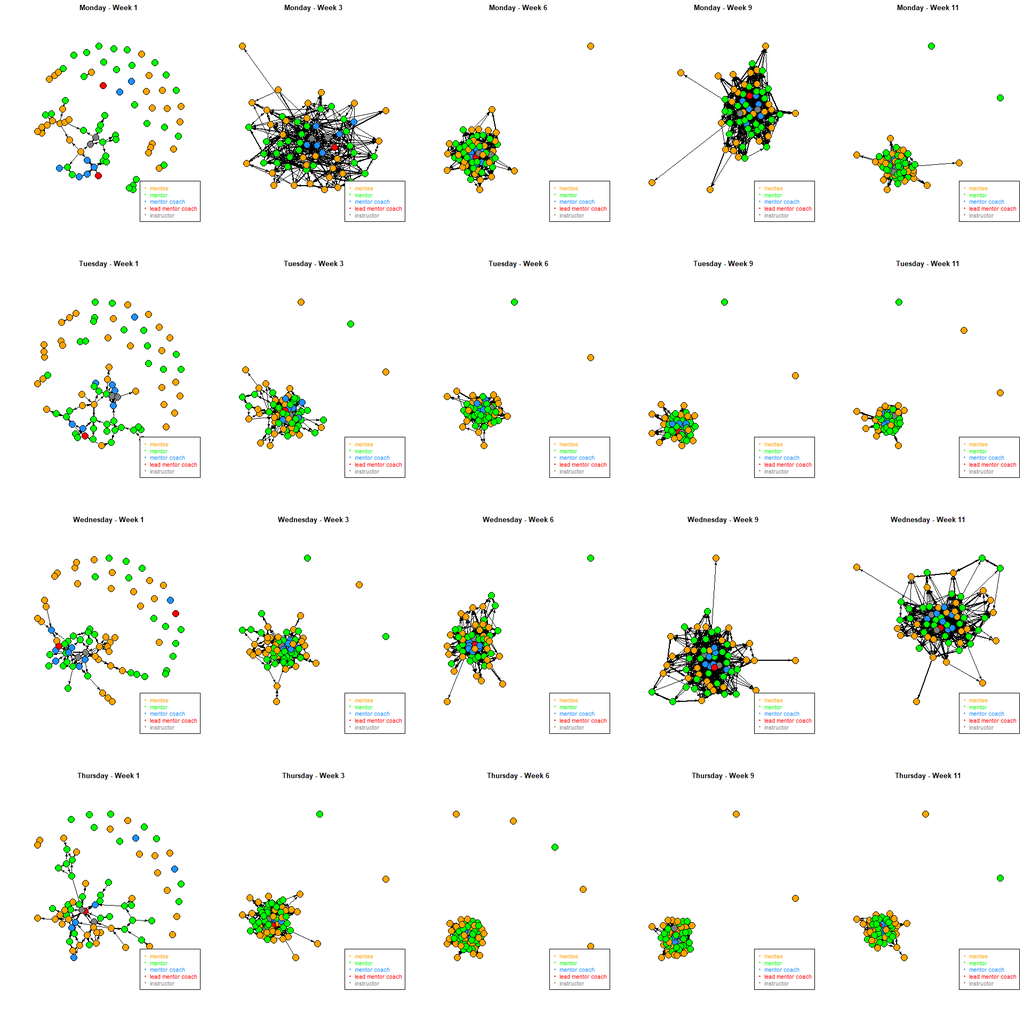

```r
  my_sn_g(thursday$graphs$g4,    title = "Thursday - Week 9")  ; my_leg(att = role, colors = color) #Social Network Graph ; Legend
  my_sn_g(thursday$graphs$g5,    title = "Thursday - Week 11") ; my_leg(att = role, colors = color) #Social Network Graph ; Legend
```

```r
#Plot With purrr::walk()
  #walk(.x = monday$graphs, .f = my_sn_g, title = "Monday");my_leg(role, color)
  #walk(.x = tuesday$graphs, .f = my_sn_g, title = "Tuesday");my_leg(role, color)
  #walk(.x =wednesday$graphs, .f = my_sn_g, title = "Wednesday");my_leg(role, color)
  #walk(.x = thursday$graphs, .f = my_sn_g, title = "Thursday");my_leg(role, color)
```

**Create Semester List**

```r
F16 <- list(monday = monday, tuesday = tuesday, wednesday = wednesday, thursday = thursday)
rm(monday);rm(tuesday);rm(wednesday);rm(thursday)
rm(temp)
```

## S17

```r
temp <- elmk %>% filter(semester == "S17")
mon <- temp %>% filter(night == "monday")
tue <- temp %>% filter(night == "tuesday")
wed <- temp %>% filter(night == "wednesday")
thu <- temp %>% filter(night == "thursday")
sem <- list(mon = mon,
            tue = tue,
            wed = wed,
            thu = thu)
rm(mon);rm(tue);rm(wed);rm(thu)
```

**Summary**

```r
sem$mon <- group_by(sem$mon, survnum)
sem$tue <- group_by(sem$tue, survnum)
sem$wed <- group_by(sem$wed, survnum)
sem$thu <- group_by(sem$thu, survnum)
summarize(sem$mon, day = "mon", n = length(unique(Sender_Final_ID)), tie_count = sum(sn1, na.rm = TRUE), tie_prop = (tie_count/nrow(sem$mon))*100)
```

| survnum | day | n | tie_count | tie_prop |
| --- | --- | --- | --- | --- |
| 1 | mon | 66 | 149 | 0.701804 |
| 2 | mon | 65 | 451 | 2.124252 |
| 3 | mon | 63 | 664 | 3.127502 |
| 4 | mon | 62 | 797 | 3.753945 |
| 5 | mon | 61 | 839 | 3.951769 |

```r
summarize(sem$tue, day = "tue", n = length(unique(Sender_Final_ID)), tie_count = sum(sn1, na.rm = TRUE), tie_prop = (tie_count/nrow(sem$tue))*100)
```

| survnum | day | n | tie_count | tie_prop |
| --- | --- | --- | --- | --- |
| 1 | tue | 65 | 86 | 0.4093873 |
| 2 | tue | 64 | 466 | 2.2183082 |
| 3 | tue | 63 | 768 | 3.6559242 |
| 4 | tue | 62 | 841 | 4.0034274 |
| 5 | tue | 62 | 1006 | 4.7888799 |

```r
summarize(sem$wed, day = "wed", n = length(unique(Sender_Final_ID)), tie_count = sum(sn1, na.rm = TRUE), tie_prop = (tie_count/nrow(sem$wed))*100)
```

| survnum | day | n | tie_count | tie_prop |
| --- | --- | --- | --- | --- |
| 1 | wed | 64 | 139 | 0.6851003 |
| 2 | wed | 64 | 432 | 2.1292326 |
| 3 | wed | 62 | 648 | 3.1938489 |
| 4 | wed | 62 | 846 | 4.1697472 |
| 5 | wed | 62 | 932 | 4.5936222 |

```r
summarize(sem$thu, day = "thu", n = length(unique(Sender_Final_ID)), tie_count = sum(sn1, na.rm = TRUE), tie_prop = (tie_count/nrow(sem$thu))*100)
```

| survnum | day | n | tie_count | tie_prop |
| --- | --- | --- | --- | --- |
| 1 | thu | 65 | 92 | 0.4277478 |
| 2 | thu | 65 | 440 | 2.0457504 |
| 3 | thu | 64 | 700 | 3.2546029 |
| 4 | thu | 63 | 867 | 4.0310582 |
| 5 | thu | 63 | 954 | 4.4355589 |

```r
sem$mon <- ungroup(sem$mon)
sem$tue <- ungroup(sem$tue)
sem$wed <- ungroup(sem$wed)
sem$thu <- ungroup(sem$thu)
rm(sem)
```

**Monday**

```r
temp_night <- temp            %>% filter(night == "monday")
temp_att   <- staff_youth_att %>% mutate(night =  "monday")
#Surv_1
surv_1 <- temp_night %>%
  filter(survnum == 1) %>%
  mutate(Receiver_Final_ID = ifelse(is.na(sn1), NA, Receiver_Final_ID)) #%>%
#Getting isolates
isolates1 <- surv_1 %>%
  mutate(sn1 = ifelse(is.na(sn1), 0, sn1)) %>%
  group_by(Sender_Final_ID) %>%
  summarize(isolate = sum(sn1)) %>%
  filter(isolate < 1) %>%
  select(Sender_Final_ID)
surv_1 <- surv_1 %>%
   select(Sender_Final_ID, Receiver_Final_ID) %>% filter(!(is.na(Receiver_Final_ID)))
#Surv 2
surv_2 <- temp_night %>%
  filter(survnum == 2) %>%
  mutate(Receiver_Final_ID = ifelse(is.na(sn1), NA, Receiver_Final_ID)) #%>%
#Getting isolates
isolates2 <- surv_2 %>%
  mutate(sn1 = ifelse(is.na(sn1), 0, sn1)) %>%
  group_by(Sender_Final_ID) %>%
  summarize(isolate = sum(sn1)) %>%
  filter(isolate < 1) %>%
  select(Sender_Final_ID)
surv_2 <- surv_2 %>%
   select(Sender_Final_ID, Receiver_Final_ID) %>% filter(!(is.na(Receiver_Final_ID)))
#Surv 3
surv_3 <- temp_night %>%
  filter(survnum == 3) %>%
  mutate(Receiver_Final_ID = ifelse(is.na(sn1), NA, Receiver_Final_ID)) #%>%
#Getting isolates
isolates3 <- surv_3 %>%
  mutate(sn1 = ifelse(is.na(sn1), 0, sn1)) %>%
  group_by(Sender_Final_ID) %>%
  summarize(isolate = sum(sn1)) %>%
  filter(isolate < 1) %>%
  select(Sender_Final_ID)
surv_3 <- surv_3 %>%
   select(Sender_Final_ID, Receiver_Final_ID) %>% filter(!(is.na(Receiver_Final_ID)))
#Surv 4
surv_4 <- temp_night %>%
  filter(survnum == 4) %>%
  mutate(Receiver_Final_ID = ifelse(is.na(sn1), NA, Receiver_Final_ID)) #%>%
#Getting isolates
isolates4 <- surv_4 %>%
  mutate(sn1 = ifelse(is.na(sn1), 0, sn1)) %>%
  group_by(Sender_Final_ID) %>%
  summarize(isolate = sum(sn1)) %>%
  filter(isolate < 1) %>%
  select(Sender_Final_ID)
surv_4 <- surv_4 %>%
   select(Sender_Final_ID, Receiver_Final_ID) %>% filter(!(is.na(Receiver_Final_ID)))
#Surv 5
surv_5 <- temp_night %>%
  filter(survnum == 5) %>%
  mutate(Receiver_Final_ID = ifelse(is.na(sn1), NA, Receiver_Final_ID)) #%>%
#Getting isolates
isolates5 <- surv_5 %>%
  mutate(sn1 = ifelse(is.na(sn1), 0, sn1)) %>%
  group_by(Sender_Final_ID) %>%
  summarize(isolate = sum(sn1)) %>%
  filter(isolate < 1) %>%
  select(Sender_Final_ID)
surv_5 <- surv_5 %>%
   select(Sender_Final_ID, Receiver_Final_ID) %>% filter(!(is.na(Receiver_Final_ID)))
day <- list(sur1 = surv_1,
            sur2 = surv_2,
            sur3 = surv_3,
            sur4 = surv_4,
            sur5 = surv_5,
            iso1 = isolates1,
            iso2 = isolates2,
            iso3 = isolates3,
            iso4 = isolates4,
            iso5 = isolates5)
rm(surv_1);rm(surv_2);rm(surv_3);rm(surv_4);rm(surv_5)
rm(isolates1);rm(isolates2);rm(isolates3);rm(isolates4);rm(isolates5)
```

**General Graphs**

```r
#Convert to Matrices
sur1 <- as.matrix(day$sur1)
sur2 <- as.matrix(day$sur2)
sur3 <- as.matrix(day$sur3)
sur4 <- as.matrix(day$sur4)
sur5 <- as.matrix(day$sur5)
# Convert matrix to an igraph object
g1 <- graph.edgelist(sur1, directed = TRUE) + vertices(day$iso1$Sender_Final_ID) #Graph edgelist + Add Isolates
g2 <- graph.edgelist(sur2, directed = TRUE) + vertices(day$iso2$Sender_Final_ID) #Graph edgelist + Add Isolates
g3 <- graph.edgelist(sur3, directed = TRUE) + vertices(day$iso3$Sender_Final_ID) #Graph edgelist + Add Isolates
g4 <- graph.edgelist(sur4, directed = TRUE) + vertices(day$iso4$Sender_Final_ID) #Graph edgelist + Add Isolates
g5 <- graph.edgelist(sur5, directed = TRUE) + vertices(day$iso5$Sender_Final_ID) #Graph edgelist + Add Isolates
#Capture Roles, Nights & Colors
temp_att <- temp_att %>%
  mutate(
         role1    = ifelse((!(is.na(role2)))     & (night2 == night), role2,     role1),
         night1   = ifelse((!(is.na(night2)))    & (night2 == night), night2,    night1),
         role_col = ifelse((!(is.na(role_col2))) & (night2 == night), role_col2, role_col)
         )
#Add staff Role Attribute
V(g1)$role  <- temp_att$role1[match(V(g1)$name, temp_att$Final_ID)]
V(g2)$role  <- temp_att$role1[match(V(g2)$name, temp_att$Final_ID)]
V(g3)$role  <- temp_att$role1[match(V(g3)$name, temp_att$Final_ID)]
V(g4)$role  <- temp_att$role1[match(V(g4)$name, temp_att$Final_ID)]
V(g5)$role  <- temp_att$role1[match(V(g5)$name, temp_att$Final_ID)]
#Add role colors
V(g1)$color <- temp_att$role_col[match(V(g1)$name, temp_att$Final_ID)]
V(g2)$color <- temp_att$role_col[match(V(g2)$name, temp_att$Final_ID)]
V(g3)$color <- temp_att$role_col[match(V(g3)$name, temp_att$Final_ID)]
V(g4)$color <- temp_att$role_col[match(V(g4)$name, temp_att$Final_ID)]
V(g5)$color <- temp_att$role_col[match(V(g5)$name, temp_att$Final_ID)]
#Add Edge weights - Match by edgelist rows Send/ Receive rows & temp_night Send/Receive rows. filter by survey.
w <- left_join(rename(as_data_frame(as_edgelist(g1)), Sender_Final_ID =V1, Receiver_Final_ID = V2), temp_night, by = c("Sender_Final_ID","Receiver_Final_ID")) %>%
                               filter(survnum == 1) #Match Weights
                           g1 <-  set_edge_attr(g1, "weight", value = w$sn2) #Add edge attribute
w <- left_join(rename(as_data_frame(as_edgelist(g2)), Sender_Final_ID =V1, Receiver_Final_ID = V2), temp_night, by = c("Sender_Final_ID","Receiver_Final_ID")) %>%
                               filter(survnum == 2) #Match weights
                           g2 <-  set_edge_attr(g2, "weight", value = w$sn2) #Add edge attribute
w <- left_join(rename(as_data_frame(as_edgelist(g3)), Sender_Final_ID =V1, Receiver_Final_ID = V2), temp_night, by = c("Sender_Final_ID","Receiver_Final_ID")) %>%
                               filter(survnum == 3) #Match weights
                           g3 <-  set_edge_attr(g3, "weight", value = w$sn2) #Add edge attribute
w <- left_join(rename(as_data_frame(as_edgelist(g4)), Sender_Final_ID =V1, Receiver_Final_ID = V2), temp_night, by = c("Sender_Final_ID","Receiver_Final_ID")) %>%
                               filter(survnum == 4) #Match weights
                           g4 <-  set_edge_attr(g4, "weight", value = w$sn2) #Add edge attribute
w <- left_join(rename(as_data_frame(as_edgelist(g5)), Sender_Final_ID =V1, Receiver_Final_ID = V2), temp_night, by = c("Sender_Final_ID","Receiver_Final_ID")) %>%
                               filter(survnum == 5) #Match weights
                           g5 <-  set_edge_attr(g5, "weight", value = w$sn2) #Add edge attribute
#Set graphs to list
graphs <- list(g1 = g1,g2 = g2, g3 = g3,g4 = g4, g5 = g5)
rm(g1); rm(g2); rm(g3); rm(g4); rm(g5)
rm(sur1);rm(sur2);rm(sur3);rm(sur4);rm(sur5)
rm(temp_att); rm(temp_night); rm(w)
```

**Create List**

```r
monday <- list(edgelists = day, graphs = graphs)
rm(day);rm(graphs)
```

**Tuesday**

```r
temp_night <- temp            %>% filter(night == "tuesday")
temp_att   <- staff_youth_att %>% mutate(night =  "tuesday")
#Surv_1
surv_1 <- temp_night %>%
  filter(survnum == 1) %>%
  mutate(Receiver_Final_ID = ifelse(is.na(sn1), NA, Receiver_Final_ID)) #%>%
#Getting isolates
isolates1 <- surv_1 %>%
  mutate(sn1 = ifelse(is.na(sn1), 0, sn1)) %>%
  group_by(Sender_Final_ID) %>%
  summarize(isolate = sum(sn1)) %>%
  filter(isolate < 1) %>%
  select(Sender_Final_ID)
surv_1 <- surv_1 %>%
   select(Sender_Final_ID, Receiver_Final_ID) %>% filter(!(is.na(Receiver_Final_ID)))
#Surv 2
surv_2 <- temp_night %>%
  filter(survnum == 2) %>%
  mutate(Receiver_Final_ID = ifelse(is.na(sn1), NA, Receiver_Final_ID)) #%>%
#Getting isolates
isolates2 <- surv_2 %>%
  mutate(sn1 = ifelse(is.na(sn1), 0, sn1)) %>%
  group_by(Sender_Final_ID) %>%
  summarize(isolate = sum(sn1)) %>%
  filter(isolate < 1) %>%
  select(Sender_Final_ID)
surv_2 <- surv_2 %>%
   select(Sender_Final_ID, Receiver_Final_ID) %>% filter(!(is.na(Receiver_Final_ID)))
#Surv 3
surv_3 <- temp_night %>%
  filter(survnum == 3) %>%
  mutate(Receiver_Final_ID = ifelse(is.na(sn1), NA, Receiver_Final_ID)) #%>%
#Getting isolates
isolates3 <- surv_3 %>%
  mutate(sn1 = ifelse(is.na(sn1), 0, sn1)) %>%
  group_by(Sender_Final_ID) %>%
  summarize(isolate = sum(sn1)) %>%
  filter(isolate < 1) %>%
  select(Sender_Final_ID)
surv_3 <- surv_3 %>%
   select(Sender_Final_ID, Receiver_Final_ID) %>% filter(!(is.na(Receiver_Final_ID)))
#Surv 4
surv_4 <- temp_night %>%
  filter(survnum == 4) %>%
  mutate(Receiver_Final_ID = ifelse(is.na(sn1), NA, Receiver_Final_ID)) #%>%
#Getting isolates
isolates4 <- surv_4 %>%
  mutate(sn1 = ifelse(is.na(sn1), 0, sn1)) %>%
  group_by(Sender_Final_ID) %>%
  summarize(isolate = sum(sn1)) %>%
  filter(isolate < 1) %>%
  select(Sender_Final_ID)
surv_4 <- surv_4 %>%
   select(Sender_Final_ID, Receiver_Final_ID) %>% filter(!(is.na(Receiver_Final_ID)))
#Surv 5
surv_5 <- temp_night %>%
  filter(survnum == 5) %>%
  mutate(Receiver_Final_ID = ifelse(is.na(sn1), NA, Receiver_Final_ID)) #%>%
#Getting isolates
isolates5 <- surv_5 %>%
  mutate(sn1 = ifelse(is.na(sn1), 0, sn1)) %>%
  group_by(Sender_Final_ID) %>%
  summarize(isolate = sum(sn1)) %>%
  filter(isolate < 1) %>%
  select(Sender_Final_ID)
surv_5 <- surv_5 %>%
   select(Sender_Final_ID, Receiver_Final_ID) %>% filter(!(is.na(Receiver_Final_ID)))
day <- list(sur1 = surv_1,
            sur2 = surv_2,
            sur3 = surv_3,
            sur4 = surv_4,
            sur5 = surv_5,
            iso1 = isolates1,
            iso2 = isolates2,
            iso3 = isolates3,
            iso4 = isolates4,
            iso5 = isolates5)
rm(surv_1);rm(surv_2);rm(surv_3);rm(surv_4);rm(surv_5)
rm(isolates1);rm(isolates2);rm(isolates3);rm(isolates4);rm(isolates5)
```

**General Graphs**

```r
#Convert to Matrices
sur1 <- as.matrix(day$sur1)
sur2 <- as.matrix(day$sur2)
sur3 <- as.matrix(day$sur3)
sur4 <- as.matrix(day$sur4)
sur5 <- as.matrix(day$sur5)
# Convert matrix to an igraph object
g1 <- graph.edgelist(sur1, directed = TRUE) + vertices(day$iso1$Sender_Final_ID) #Graph edgelist + Add Isolates
g2 <- graph.edgelist(sur2, directed = TRUE) + vertices(day$iso2$Sender_Final_ID) #Graph edgelist + Add Isolates
g3 <- graph.edgelist(sur3, directed = TRUE) + vertices(day$iso3$Sender_Final_ID) #Graph edgelist + Add Isolates
g4 <- graph.edgelist(sur4, directed = TRUE) + vertices(day$iso4$Sender_Final_ID) #Graph edgelist + Add Isolates
g5 <- graph.edgelist(sur5, directed = TRUE) + vertices(day$iso5$Sender_Final_ID) #Graph edgelist + Add Isolates
#Capture Roles, Nights & Colors
temp_att <- temp_att %>%
  mutate(
         role1    = ifelse((!(is.na(role2)))     & (night2 == night), role2,     role1),
         night1   = ifelse((!(is.na(night2)))    & (night2 == night), night2,    night1),
         role_col = ifelse((!(is.na(role_col2))) & (night2 == night), role_col2, role_col)
         )
#Add staff Role Attribute
V(g1)$role  <- temp_att$role1[match(V(g1)$name, temp_att$Final_ID)]
V(g2)$role  <- temp_att$role1[match(V(g2)$name, temp_att$Final_ID)]
V(g3)$role  <- temp_att$role1[match(V(g3)$name, temp_att$Final_ID)]
V(g4)$role  <- temp_att$role1[match(V(g4)$name, temp_att$Final_ID)]
V(g5)$role  <- temp_att$role1[match(V(g5)$name, temp_att$Final_ID)]
#Add role colors
V(g1)$color <- temp_att$role_col[match(V(g1)$name, temp_att$Final_ID)]
V(g2)$color <- temp_att$role_col[match(V(g2)$name, temp_att$Final_ID)]
V(g3)$color <- temp_att$role_col[match(V(g3)$name, temp_att$Final_ID)]
V(g4)$color <- temp_att$role_col[match(V(g4)$name, temp_att$Final_ID)]
V(g5)$color <- temp_att$role_col[match(V(g5)$name, temp_att$Final_ID)]
#Add Edge weights - Match by edgelist rows Send/ Receive rows & temp_night Send/Receive rows. filter by survey.
w <- left_join(rename(as_data_frame(as_edgelist(g1)), Sender_Final_ID =V1, Receiver_Final_ID = V2), temp_night, by = c("Sender_Final_ID","Receiver_Final_ID")) %>%
                               filter(survnum == 1) #Match Weights
                           g1 <-  set_edge_attr(g1, "weight", value = w$sn2) #Add edge attribute
w <- left_join(rename(as_data_frame(as_edgelist(g2)), Sender_Final_ID =V1, Receiver_Final_ID = V2), temp_night, by = c("Sender_Final_ID","Receiver_Final_ID")) %>%
                               filter(survnum == 2) #Match weights
                           g2 <-  set_edge_attr(g2, "weight", value = w$sn2) #Add edge attribute
w <- left_join(rename(as_data_frame(as_edgelist(g3)), Sender_Final_ID =V1, Receiver_Final_ID = V2), temp_night, by = c("Sender_Final_ID","Receiver_Final_ID")) %>%
                               filter(survnum == 3) #Match weights
                           g3 <-  set_edge_attr(g3, "weight", value = w$sn2) #Add edge attribute
w <- left_join(rename(as_data_frame(as_edgelist(g4)), Sender_Final_ID =V1, Receiver_Final_ID = V2), temp_night, by = c("Sender_Final_ID","Receiver_Final_ID")) %>%
                               filter(survnum == 4) #Match weights
                           g4 <-  set_edge_attr(g4, "weight", value = w$sn2) #Add edge attribute
w <- left_join(rename(as_data_frame(as_edgelist(g5)), Sender_Final_ID =V1, Receiver_Final_ID = V2), temp_night, by = c("Sender_Final_ID","Receiver_Final_ID")) %>%
                               filter(survnum == 5) #Match weights
                           g5 <-  set_edge_attr(g5, "weight", value = w$sn2) #Add edge attribute
#Set graphs to list
graphs <- list(g1 = g1,g2 = g2, g3 = g3,g4 = g4, g5 = g5)
rm(g1); rm(g2); rm(g3); rm(g4); rm(g5)
rm(sur1);rm(sur2);rm(sur3);rm(sur4);rm(sur5)
rm(temp_att); rm(temp_night); rm(w)
```

**Create List**

```r
tuesday <- list(edgelists = day, graphs = graphs)
rm(day); rm(graphs)
```

**Wednesday**

```r
temp_night <- temp            %>% filter(night == "wednesday")
temp_att   <- staff_youth_att %>% mutate(night =  "wednesday")
#Surv_1
surv_1 <- temp_night %>%
  filter(survnum == 1) %>%
  mutate(Receiver_Final_ID = ifelse(is.na(sn1), NA, Receiver_Final_ID)) #%>%
#Getting isolates
isolates1 <- surv_1 %>%
  mutate(sn1 = ifelse(is.na(sn1), 0, sn1)) %>%
  group_by(Sender_Final_ID) %>%
  summarize(isolate = sum(sn1)) %>%
  filter(isolate < 1) %>%
  select(Sender_Final_ID)
surv_1 <- surv_1 %>%
   select(Sender_Final_ID, Receiver_Final_ID) %>% filter(!(is.na(Receiver_Final_ID)))
#Surv 2
surv_2 <- temp_night %>%
  filter(survnum == 2) %>%
  mutate(Receiver_Final_ID = ifelse(is.na(sn1), NA, Receiver_Final_ID)) #%>%
#Getting isolates
isolates2 <- surv_2 %>%
  mutate(sn1 = ifelse(is.na(sn1), 0, sn1)) %>%
  group_by(Sender_Final_ID) %>%
  summarize(isolate = sum(sn1)) %>%
  filter(isolate < 1) %>%
  select(Sender_Final_ID)
surv_2 <- surv_2 %>%
   select(Sender_Final_ID, Receiver_Final_ID) %>% filter(!(is.na(Receiver_Final_ID)))
#Surv 3
surv_3 <- temp_night %>%
  filter(survnum == 3) %>%
  mutate(Receiver_Final_ID = ifelse(is.na(sn1), NA, Receiver_Final_ID)) #%>%
#Getting isolates
isolates3 <- surv_3 %>%
  mutate(sn1 = ifelse(is.na(sn1), 0, sn1)) %>%
  group_by(Sender_Final_ID) %>%
  summarize(isolate = sum(sn1)) %>%
  filter(isolate < 1) %>%
  select(Sender_Final_ID)
surv_3 <- surv_3 %>%
   select(Sender_Final_ID, Receiver_Final_ID) %>% filter(!(is.na(Receiver_Final_ID)))
#Surv 4
surv_4 <- temp_night %>%
  filter(survnum == 4) %>%
  mutate(Receiver_Final_ID = ifelse(is.na(sn1), NA, Receiver_Final_ID)) #%>%
#Getting isolates
isolates4 <- surv_4 %>%
  mutate(sn1 = ifelse(is.na(sn1), 0, sn1)) %>%
  group_by(Sender_Final_ID) %>%
  summarize(isolate = sum(sn1)) %>%
  filter(isolate < 1) %>%
  select(Sender_Final_ID)
surv_4 <- surv_4 %>%
   select(Sender_Final_ID, Receiver_Final_ID) %>% filter(!(is.na(Receiver_Final_ID)))
#Surv 5
surv_5 <- temp_night %>%
  filter(survnum == 5) %>%
  mutate(Receiver_Final_ID = ifelse(is.na(sn1), NA, Receiver_Final_ID)) #%>%
#Getting isolates
isolates5 <- surv_5 %>%
  mutate(sn1 = ifelse(is.na(sn1), 0, sn1)) %>%
  group_by(Sender_Final_ID) %>%
  summarize(isolate = sum(sn1)) %>%
  filter(isolate < 1) %>%
  select(Sender_Final_ID)
surv_5 <- surv_5 %>%
   select(Sender_Final_ID, Receiver_Final_ID) %>% filter(!(is.na(Receiver_Final_ID)))
day <- list(sur1 = surv_1,
            sur2 = surv_2,
            sur3 = surv_3,
            sur4 = surv_4,
            sur5 = surv_5,
            iso1 = isolates1,
            iso2 = isolates2,
            iso3 = isolates3,
            iso4 = isolates4,
            iso5 = isolates5)
rm(surv_1);rm(surv_2);rm(surv_3);rm(surv_4);rm(surv_5)
rm(isolates1);rm(isolates2);rm(isolates3);rm(isolates4);rm(isolates5)
```

**General Graphs**

```r
#Convert to Matrices
sur1 <- as.matrix(day$sur1)
sur2 <- as.matrix(day$sur2)
sur3 <- as.matrix(day$sur3)
sur4 <- as.matrix(day$sur4)
sur5 <- as.matrix(day$sur5)
# Convert matrix to an igraph object
g1 <- graph.edgelist(sur1, directed = TRUE) + vertices(day$iso1$Sender_Final_ID) #Graph edgelist + Add Isolates
g2 <- graph.edgelist(sur2, directed = TRUE) + vertices(day$iso2$Sender_Final_ID) #Graph edgelist + Add Isolates
g3 <- graph.edgelist(sur3, directed = TRUE) + vertices(day$iso3$Sender_Final_ID) #Graph edgelist + Add Isolates
g4 <- graph.edgelist(sur4, directed = TRUE) + vertices(day$iso4$Sender_Final_ID) #Graph edgelist + Add Isolates
g5 <- graph.edgelist(sur5, directed = TRUE) + vertices(day$iso5$Sender_Final_ID) #Graph edgelist + Add Isolates
#Capture Roles, Nights & Colors
temp_att <- temp_att %>%
  mutate(
         role1    = ifelse((!(is.na(role2)))     & (night2 == night), role2,     role1),
         night1   = ifelse((!(is.na(night2)))    & (night2 == night), night2,    night1),
         role_col = ifelse((!(is.na(role_col2))) & (night2 == night), role_col2, role_col)
         )
#Add staff Role Attribute
V(g1)$role  <- temp_att$role1[match(V(g1)$name, temp_att$Final_ID)]
V(g2)$role  <- temp_att$role1[match(V(g2)$name, temp_att$Final_ID)]
V(g3)$role  <- temp_att$role1[match(V(g3)$name, temp_att$Final_ID)]
V(g4)$role  <- temp_att$role1[match(V(g4)$name, temp_att$Final_ID)]
V(g5)$role  <- temp_att$role1[match(V(g5)$name, temp_att$Final_ID)]
#Add role colors
V(g1)$color <- temp_att$role_col[match(V(g1)$name, temp_att$Final_ID)]
V(g2)$color <- temp_att$role_col[match(V(g2)$name, temp_att$Final_ID)]
V(g3)$color <- temp_att$role_col[match(V(g3)$name, temp_att$Final_ID)]
V(g4)$color <- temp_att$role_col[match(V(g4)$name, temp_att$Final_ID)]
V(g5)$color <- temp_att$role_col[match(V(g5)$name, temp_att$Final_ID)]
#Add Edge weights - Match by edgelist rows Send/ Receive rows & temp_night Send/Receive rows. filter by survey.
w <- left_join(rename(as_data_frame(as_edgelist(g1)), Sender_Final_ID =V1, Receiver_Final_ID = V2), temp_night, by = c("Sender_Final_ID","Receiver_Final_ID")) %>%
                               filter(survnum == 1) #Match Weights
                           g1 <-  set_edge_attr(g1, "weight", value = w$sn2) #Add edge attribute
w <- left_join(rename(as_data_frame(as_edgelist(g2)), Sender_Final_ID =V1, Receiver_Final_ID = V2), temp_night, by = c("Sender_Final_ID","Receiver_Final_ID")) %>%
                               filter(survnum == 2) #Match weights
                           g2 <-  set_edge_attr(g2, "weight", value = w$sn2) #Add edge attribute
w <- left_join(rename(as_data_frame(as_edgelist(g3)), Sender_Final_ID =V1, Receiver_Final_ID = V2), temp_night, by = c("Sender_Final_ID","Receiver_Final_ID")) %>%
                               filter(survnum == 3) #Match weights
                           g3 <-  set_edge_attr(g3, "weight", value = w$sn2) #Add edge attribute
w <- left_join(rename(as_data_frame(as_edgelist(g4)), Sender_Final_ID =V1, Receiver_Final_ID = V2), temp_night, by = c("Sender_Final_ID","Receiver_Final_ID")) %>%
                               filter(survnum == 4) #Match weights
                           g4 <-  set_edge_attr(g4, "weight", value = w$sn2) #Add edge attribute
w <- left_join(rename(as_data_frame(as_edgelist(g5)), Sender_Final_ID =V1, Receiver_Final_ID = V2), temp_night, by = c("Sender_Final_ID","Receiver_Final_ID")) %>%
                               filter(survnum == 5) #Match weights
                           g5 <-  set_edge_attr(g5, "weight", value = w$sn2) #Add edge attribute
#Set graphs to list
graphs <- list(g1 = g1,g2 = g2, g3 = g3,g4 = g4, g5 = g5)
rm(g1); rm(g2); rm(g3); rm(g4); rm(g5)
rm(sur1);rm(sur2);rm(sur3);rm(sur4);rm(sur5)
rm(temp_att); rm(temp_night); rm(w)
```

**Create List**

```r
wednesday <- list(edgelists = day, graphs = graphs)
rm(day); rm(graphs)
```

**Thursday**

```r
temp_night <- temp            %>% filter(night == "thursday")
temp_att   <- staff_youth_att %>% mutate(night =  "thursday")
#Surv_1
surv_1 <- temp_night %>%
  filter(survnum == 1) %>%
  mutate(Receiver_Final_ID = ifelse(is.na(sn1), NA, Receiver_Final_ID)) #%>%
#Getting isolates
isolates1 <- surv_1 %>%
  mutate(sn1 = ifelse(is.na(sn1), 0, sn1)) %>%
  group_by(Sender_Final_ID) %>%
  summarize(isolate = sum(sn1)) %>%
  filter(isolate < 1) %>%
  select(Sender_Final_ID)
surv_1 <- surv_1 %>%
   select(Sender_Final_ID, Receiver_Final_ID) %>% filter(!(is.na(Receiver_Final_ID)))
#Surv 2
surv_2 <- temp_night %>%
  filter(survnum == 2) %>%
  mutate(Receiver_Final_ID = ifelse(is.na(sn1), NA, Receiver_Final_ID)) #%>%
#Getting isolates
isolates2 <- surv_2 %>%
  mutate(sn1 = ifelse(is.na(sn1), 0, sn1)) %>%
  group_by(Sender_Final_ID) %>%
  summarize(isolate = sum(sn1)) %>%
  filter(isolate < 1) %>%
  select(Sender_Final_ID)
surv_2 <- surv_2 %>%
   select(Sender_Final_ID, Receiver_Final_ID) %>% filter(!(is.na(Receiver_Final_ID)))
#Surv 3
surv_3 <- temp_night %>%
  filter(survnum == 3) %>%
  mutate(Receiver_Final_ID = ifelse(is.na(sn1), NA, Receiver_Final_ID)) #%>%
#Getting isolates
isolates3 <- surv_3 %>%
  mutate(sn1 = ifelse(is.na(sn1), 0, sn1)) %>%
  group_by(Sender_Final_ID) %>%
  summarize(isolate = sum(sn1)) %>%
  filter(isolate < 1) %>%
  select(Sender_Final_ID)
surv_3 <- surv_3 %>%
   select(Sender_Final_ID, Receiver_Final_ID) %>% filter(!(is.na(Receiver_Final_ID)))
#Surv 4
surv_4 <- temp_night %>%
  filter(survnum == 4) %>%
  mutate(Receiver_Final_ID = ifelse(is.na(sn1), NA, Receiver_Final_ID)) #%>%
#Getting isolates
isolates4 <- surv_4 %>%
  mutate(sn1 = ifelse(is.na(sn1), 0, sn1)) %>%
  group_by(Sender_Final_ID) %>%
  summarize(isolate = sum(sn1)) %>%
  filter(isolate < 1) %>%
  select(Sender_Final_ID)
surv_4 <- surv_4 %>%
   select(Sender_Final_ID, Receiver_Final_ID) %>% filter(!(is.na(Receiver_Final_ID)))
#Surv 5
surv_5 <- temp_night %>%
  filter(survnum == 5) %>%
  mutate(Receiver_Final_ID = ifelse(is.na(sn1), NA, Receiver_Final_ID)) #%>%
#Getting isolates
isolates5 <- surv_5 %>%
  mutate(sn1 = ifelse(is.na(sn1), 0, sn1)) %>%
  group_by(Sender_Final_ID) %>%
  summarize(isolate = sum(sn1)) %>%
  filter(isolate < 1) %>%
  select(Sender_Final_ID)
surv_5 <- surv_5 %>%
   select(Sender_Final_ID, Receiver_Final_ID) %>% filter(!(is.na(Receiver_Final_ID)))
day <- list(sur1 = surv_1,
            sur2 = surv_2,
            sur3 = surv_3,
            sur4 = surv_4,
            sur5 = surv_5,
            iso1 = isolates1,
            iso2 = isolates2,
            iso3 = isolates3,
            iso4 = isolates4,
            iso5 = isolates5)
rm(surv_1);rm(surv_2);rm(surv_3);rm(surv_4);rm(surv_5)
rm(isolates1);rm(isolates2);rm(isolates3);rm(isolates4);rm(isolates5)
```

**General Graphs**

```r
#Convert to Matrices
sur1 <- as.matrix(day$sur1)
sur2 <- as.matrix(day$sur2)
sur3 <- as.matrix(day$sur3)
sur4 <- as.matrix(day$sur4)
sur5 <- as.matrix(day$sur5)
# Convert matrix to an igraph object
g1 <- graph.edgelist(sur1, directed = TRUE) + vertices(day$iso1$Sender_Final_ID) #Graph edgelist + Add Isolates
g2 <- graph.edgelist(sur2, directed = TRUE) + vertices(day$iso2$Sender_Final_ID) #Graph edgelist + Add Isolates
g3 <- graph.edgelist(sur3, directed = TRUE) + vertices(day$iso3$Sender_Final_ID) #Graph edgelist + Add Isolates
g4 <- graph.edgelist(sur4, directed = TRUE) + vertices(day$iso4$Sender_Final_ID) #Graph edgelist + Add Isolates
g5 <- graph.edgelist(sur5, directed = TRUE) + vertices(day$iso5$Sender_Final_ID) #Graph edgelist + Add Isolates
#Capture Roles, Nights & Colors
temp_att <- temp_att %>%
  mutate(
         role1    = ifelse((!(is.na(role2)))     & (night2 == night), role2,     role1),
         night1   = ifelse((!(is.na(night2)))    & (night2 == night), night2,    night1),
         role_col = ifelse((!(is.na(role_col2))) & (night2 == night), role_col2, role_col)
         )
#Add staff Role Attribute
V(g1)$role  <- temp_att$role1[match(V(g1)$name, temp_att$Final_ID)]
V(g2)$role  <- temp_att$role1[match(V(g2)$name, temp_att$Final_ID)]
V(g3)$role  <- temp_att$role1[match(V(g3)$name, temp_att$Final_ID)]
V(g4)$role  <- temp_att$role1[match(V(g4)$name, temp_att$Final_ID)]
V(g5)$role  <- temp_att$role1[match(V(g5)$name, temp_att$Final_ID)]
#Add role colors
V(g1)$color <- temp_att$role_col[match(V(g1)$name, temp_att$Final_ID)]
V(g2)$color <- temp_att$role_col[match(V(g2)$name, temp_att$Final_ID)]
V(g3)$color <- temp_att$role_col[match(V(g3)$name, temp_att$Final_ID)]
V(g4)$color <- temp_att$role_col[match(V(g4)$name, temp_att$Final_ID)]
V(g5)$color <- temp_att$role_col[match(V(g5)$name, temp_att$Final_ID)]
#Add Edge weights - Match by edgelist rows Send/ Receive rows & temp_night Send/Receive rows. filter by survey.
w <- left_join(rename(as_data_frame(as_edgelist(g1)), Sender_Final_ID =V1, Receiver_Final_ID = V2), temp_night, by = c("Sender_Final_ID","Receiver_Final_ID")) %>%
                               filter(survnum == 1) #Match Weights
                           g1 <-  set_edge_attr(g1, "weight", value = w$sn2) #Add edge attribute
w <- left_join(rename(as_data_frame(as_edgelist(g2)), Sender_Final_ID =V1, Receiver_Final_ID = V2), temp_night, by = c("Sender_Final_ID","Receiver_Final_ID")) %>%
                               filter(survnum == 2) #Match weights
                           g2 <-  set_edge_attr(g2, "weight", value = w$sn2) #Add edge attribute
w <- left_join(rename(as_data_frame(as_edgelist(g3)), Sender_Final_ID =V1, Receiver_Final_ID = V2), temp_night, by = c("Sender_Final_ID","Receiver_Final_ID")) %>%
                               filter(survnum == 3) #Match weights
                           g3 <-  set_edge_attr(g3, "weight", value = w$sn2) #Add edge attribute
w <- left_join(rename(as_data_frame(as_edgelist(g4)), Sender_Final_ID =V1, Receiver_Final_ID = V2), temp_night, by = c("Sender_Final_ID","Receiver_Final_ID")) %>%
                               filter(survnum == 4) #Match weights
                           g4 <-  set_edge_attr(g4, "weight", value = w$sn2) #Add edge attribute
w <- left_join(rename(as_data_frame(as_edgelist(g5)), Sender_Final_ID =V1, Receiver_Final_ID = V2), temp_night, by = c("Sender_Final_ID","Receiver_Final_ID")) %>%
                               filter(survnum == 5) #Match weights
                           g5 <-  set_edge_attr(g5, "weight", value = w$sn2) #Add edge attribute
#Set graphs to list
graphs <- list(g1 = g1,g2 = g2, g3 = g3,g4 = g4, g5 = g5)
rm(g1); rm(g2); rm(g3); rm(g4); rm(g5)
rm(sur1);rm(sur2);rm(sur3);rm(sur4);rm(sur5)
rm(temp_att); rm(temp_night); rm(w)
```

**Create List**

```r
thursday <- list(edgelists = day, graphs = graphs)
rm(day); rm(graphs)
```

### Plot Graphs

```r
#Set chart image
par(mfrow=c(4,5))
#Monday Graphs
   my_sn_g(monday$graphs$g1,      title = "Monday - Week 1")  ; my_leg(att = role, colors = color) #Social Network Graph ; Legend
   my_sn_g(monday$graphs$g2,      title = "Monday - Week 3")  ; my_leg(att = role, colors = color) #Social Network Graph ; Legend
```

```r
   my_sn_g(monday$graphs$g3,      title = "Monday - Week 6")  ; my_leg(att = role, colors = color) #Social Network Graph ; Legend
   my_sn_g(monday$graphs$g4,      title = "Monday - Week 9")  ; my_leg(att = role, colors = color) #Social Network Graph ; Legend
```

```r
   my_sn_g(monday$graphs$g5,      title = "Monday - Week 11") ; my_leg(att = role, colors = color) #Social Network Graph ; Legend

#Tuesday Graphs

  my_sn_g(tuesday$graphs$g1,     title = "Tuesday - Week 1")  ; my_leg(att = role, colors = color) #Social Network Graph ; Legend
```

```r
  my_sn_g(tuesday$graphs$g2,     title = "Tuesday - Week 3")  ; my_leg(att = role, colors = color) #Social Network Graph ; Legend
  my_sn_g(tuesday$graphs$g3,     title = "Tuesday - Week 6")  ; my_leg(att = role, colors = color) #Social Network Graph ; Legend
```

```r
  my_sn_g(tuesday$graphs$g4,     title = "Tuesday - Week 9")  ; my_leg(att = role, colors = color) #Social Network Graph ; Legend
  my_sn_g(tuesday$graphs$g5,     title = "Tuesday - Week 11") ; my_leg(att = role, colors = color) #Social Network Graph ; Legend
```

```r
#Wednesday Graphs

  my_sn_g(wednesday$graphs$g1,   title = "Wednesday - Week 1")  ; my_leg(att = role, colors = color) #Social Network Graph ; Legend
  my_sn_g(wednesday$graphs$g2,   title = "Wednesday - Week 3")  ; my_leg(att = role, colors = color) #Social Network Graph ; Legend
```

```r
  my_sn_g(wednesday$graphs$g3,   title = "Wednesday - Week 6")  ; my_leg(att = role, colors = color) #Social Network Graph ; Legend
  my_sn_g(wednesday$graphs$g4,   title = "Wednesday - Week 9")  ; my_leg(att = role, colors = color) #Social Network Graph ; Legend
```

```r
  my_sn_g(wednesday$graphs$g5,   title = "Wednesday - Week 11") ; my_leg(att = role, colors = color) #Social Network Graph ; Legend
  my_sn_g(thursday$graphs$g1,    title = "Thursday - Week 1")  ; my_leg(att = role, colors = color) #Social Network Graph ; Legend
```

```r
  my_sn_g(thursday$graphs$g2,    title = "Thursday - Week 3")  ; my_leg(att = role, colors = color) #Social Network Graph ; Legend
  my_sn_g(thursday$graphs$g3,    title = "Thursday - Week 6")  ; my_leg(att = role, colors = color) #Social Network Graph ; Legend
```

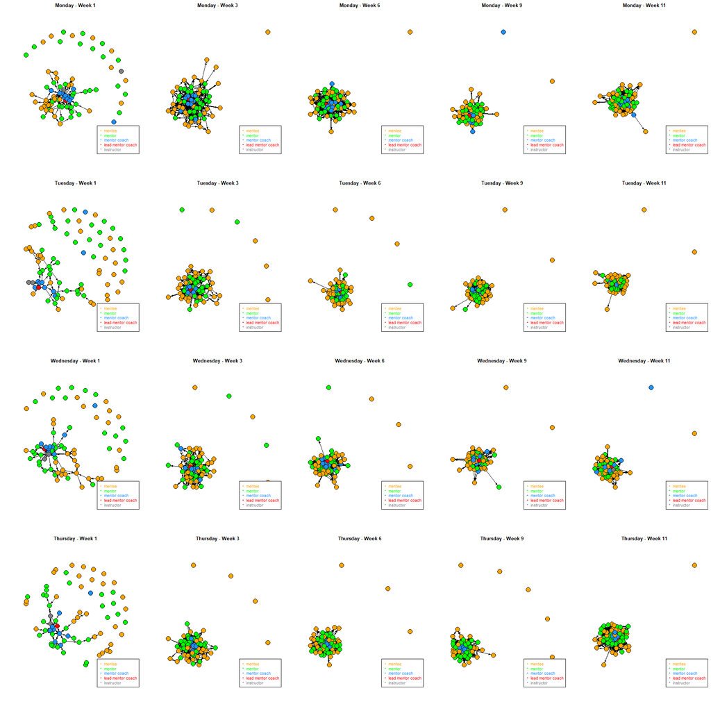

```r
  my_sn_g(thursday$graphs$g4,    title = "Thursday - Week 9")  ; my_leg(att = role, colors = color) #Social Network Graph ; Legend
  my_sn_g(thursday$graphs$g5,    title = "Thursday - Week 11") ; my_leg(att = role, colors = color) #Social Network Graph ; Legend
```

```r
#Plot With purrr::walk()
  #walk(.x = monday$graphs, .f = my_sn_g, title = "Monday");my_leg(role, color)
  #walk(.x = tuesday$graphs, .f = my_sn_g, title = "Tuesday");my_leg(role, color)
  #walk(.x =wednesday$graphs, .f = my_sn_g, title = "Wednesday");my_leg(role, color)
  #walk(.x = thursday$graphs, .f = my_sn_g, title = "Thursday");my_leg(role, color)
```

**Create Semester List**

```r
S17 <- list(monday = monday, tuesday = tuesday, wednesday = wednesday, thursday = thursday)
rm(monday);rm(tuesday);rm(wednesday);rm(thursday)
rm(temp)
```

# Combine Semesters to list

```r
ALL <- list(F15 = F15, S16 = S16, F16 = F16, S17 = S17)
rm(F15);rm(S16);rm(F16);rm(S17)
```

# Save All Networks to permanant RData File

```r
saveRDS(ALL, file="T:/Research folders/CCWTG/Data/MERGEALL/ALL_NETWORKS.RDS")
```

# Examine Cliques

## F15

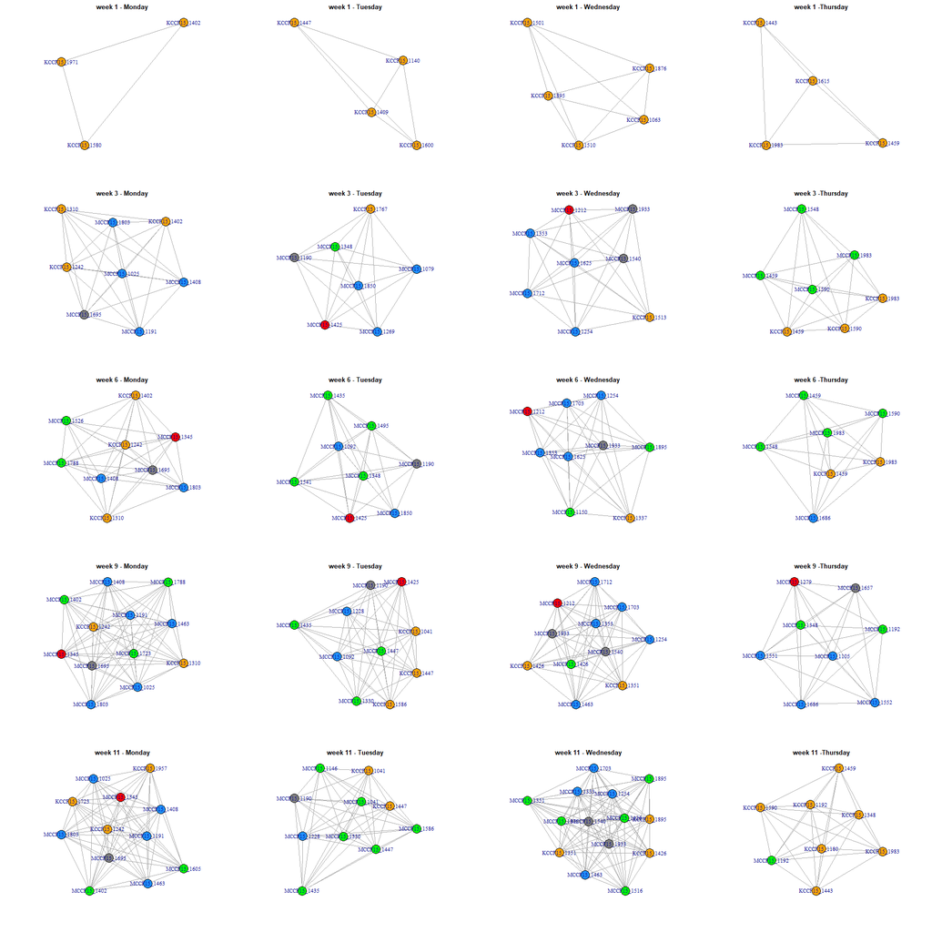

## S16

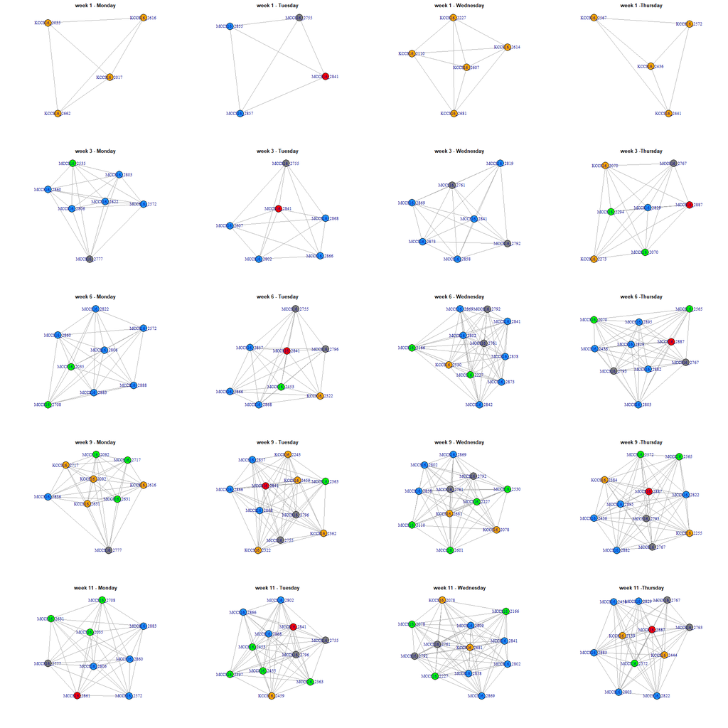

## F16

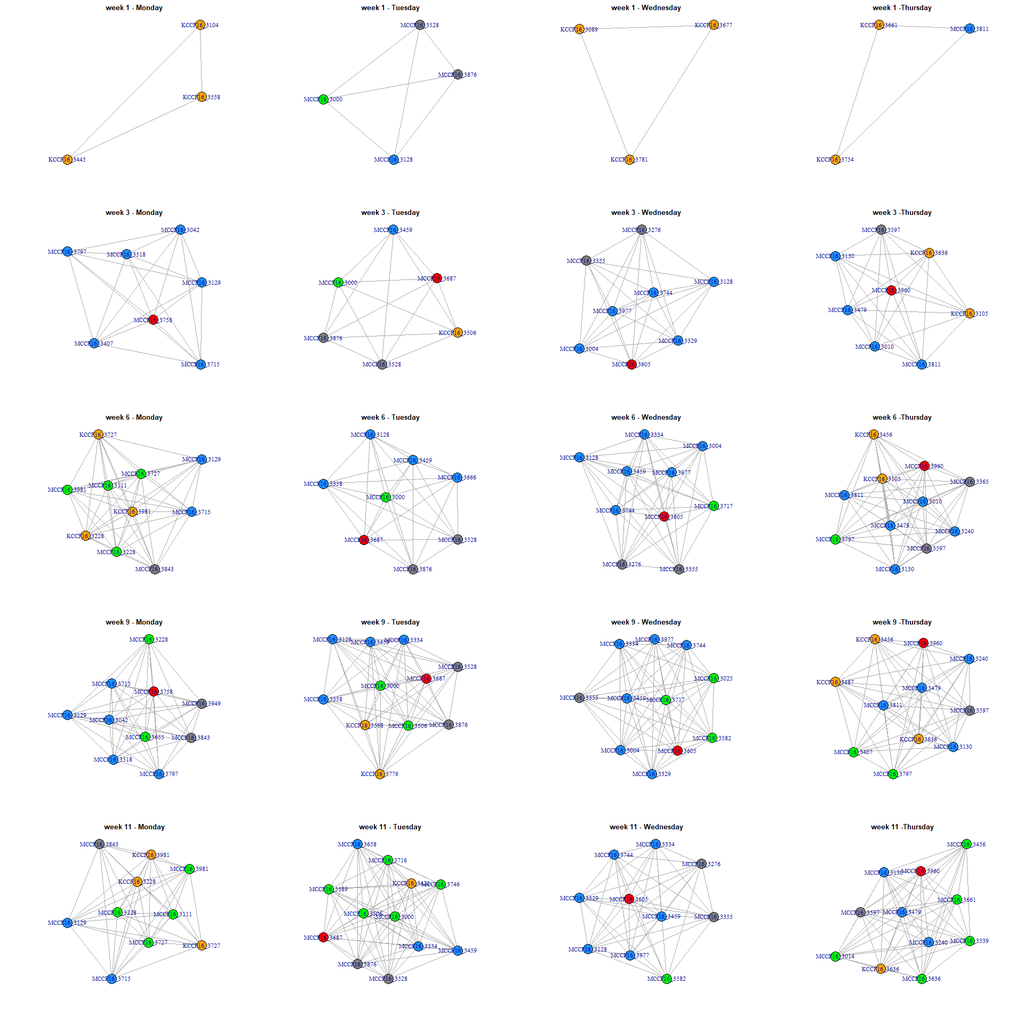

## S17

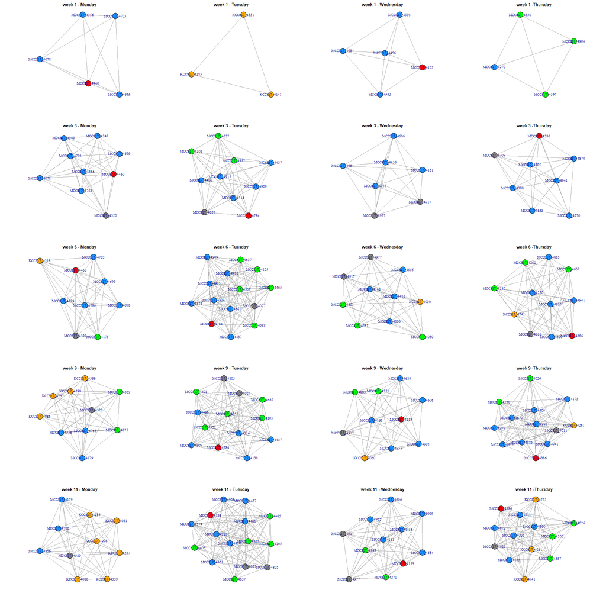

## Combine Cliques

```r
cliques <- list(F15 = F15, S16 = S16, F16 = F16, S17 = S17)
rm(F15);rm(S16);rm(F16);rm(S17)
```

# Histograms

## Tie count

### F15

```r
dow <- "monday"
#survey 1
temp_surv <- as_data_frame(as.matrix(as_adj(ALL$F15$monday$graphs$g1), rownames = TRUE), rownames = NA)
temp <- data.frame(matrix(nrow= nrow(temp_surv) , ncol= 0)) #blank dataframe
temp$sent     <- as_data_frame(as.matrix(rowSums(temp_surv)))
temp$received <- as_data_frame(as.matrix(colSums(temp_surv)))
temp$all      <- temp$sent + temp$received
temp <- as.matrix(temp)
rownames(temp) <- seq(nrow(temp)) #remove rownames
temp_surv <- temp_surv %>%
  tibble::rownames_to_column() %>%
  select(Final_ID = "rowname", everything())
temp_surv <- cbind(temp_surv, temp)
role <- staff_youth_att %>%
  mutate(
         night = if_else((!(is.na(night2)) & night2 == dow), night2, night1),
         role  = if_else((!(is.na(night2)) & night2 == dow), role2,  role1)) %>%
  filter(night == dow) %>%
  select(Final_ID, role)
ties1 <- left_join(temp_surv, role, by = "Final_ID") %>%
  mutate(surv = 1) %>%
  select(Final_ID, role, surv, sent, received, all)
#Survey 2
temp_surv <- as_data_frame(as.matrix(as_adj(ALL$F15$monday$graphs$g2), rownames = TRUE), rownames = NA)
temp <- data.frame(matrix(nrow= nrow(temp_surv) , ncol= 0)) #blank dataframe
temp$sent     <- as_data_frame(as.matrix(rowSums(temp_surv)))
temp$received <- as_data_frame(as.matrix(colSums(temp_surv)))
temp$all      <- temp$sent + temp$received
temp <- as.matrix(temp)
rownames(temp) <- seq(nrow(temp)) #remove rownames
temp_surv <- temp_surv %>%
  tibble::rownames_to_column() %>%
  select(Final_ID = "rowname", everything())
temp_surv <- cbind(temp_surv, temp)
role <- staff_youth_att %>%
  mutate(
         night = if_else((!(is.na(night2)) & night2 == dow), night2, night1),
         role  = if_else((!(is.na(night2)) & night2 == dow), role2,  role1)) %>%
  filter(night == dow) %>%
  select(Final_ID, role)
ties2 <- left_join(temp_surv, role, by = "Final_ID") %>%
  mutate(surv = 2) %>%
  select(Final_ID, role, surv, sent, received, all)
#Survey 3
temp_surv <- as_data_frame(as.matrix(as_adj(ALL$F15$monday$graphs$g3), rownames = TRUE), rownames = NA)
temp <- data.frame(matrix(nrow= nrow(temp_surv) , ncol= 0)) #blank dataframe
temp$sent     <- as_data_frame(as.matrix(rowSums(temp_surv)))
temp$received <- as_data_frame(as.matrix(colSums(temp_surv)))
temp$all      <- temp$sent + temp$received
temp <- as.matrix(temp)
rownames(temp) <- seq(nrow(temp)) #remove rownames
temp_surv <- temp_surv %>%
  tibble::rownames_to_column() %>%
  select(Final_ID = "rowname", everything())
temp_surv <- cbind(temp_surv, temp)
role <- staff_youth_att %>%
  mutate(
         night = if_else((!(is.na(night2)) & night2 == dow), night2, night1),
         role  = if_else((!(is.na(night2)) & night2 == dow), role2,  role1)) %>%
  filter(night == dow) %>%
  select(Final_ID, role)
ties3 <- left_join(temp_surv, role, by = "Final_ID") %>%
  mutate(surv = 3) %>%
  select(Final_ID, role, surv, sent, received, all)
#Survey 4
temp_surv <- as_data_frame(as.matrix(as_adj(ALL$F15$monday$graphs$g4), rownames = TRUE), rownames = NA)
temp <- data.frame(matrix(nrow= nrow(temp_surv) , ncol= 0)) #blank dataframe
temp$sent     <- as_data_frame(as.matrix(rowSums(temp_surv)))
temp$received <- as_data_frame(as.matrix(colSums(temp_surv)))
temp$all      <- temp$sent + temp$received
temp <- as.matrix(temp)
rownames(temp) <- seq(nrow(temp)) #remove rownames
temp_surv <- temp_surv %>%
  tibble::rownames_to_column() %>%
  select(Final_ID = "rowname", everything())
temp_surv <- cbind(temp_surv, temp)
role <- staff_youth_att %>%
  mutate(
         night = if_else((!(is.na(night2)) & night2 == dow), night2, night1),
         role  = if_else((!(is.na(night2)) & night2 == dow), role2,  role1)) %>%
  filter(night == dow) %>%
  select(Final_ID, role)
ties4 <- left_join(temp_surv, role, by = "Final_ID") %>%
  mutate(surv = 4) %>%
  select(Final_ID, role, surv, sent, received, all)
#Survey 5
temp_surv <- as_data_frame(as.matrix(as_adj(ALL$F15$monday$graphs$g5), rownames = TRUE), rownames = NA)
temp <- data.frame(matrix(nrow= nrow(temp_surv) , ncol= 0)) #blank dataframe
temp$sent     <- as_data_frame(as.matrix(rowSums(temp_surv)))
temp$received <- as_data_frame(as.matrix(colSums(temp_surv)))
temp$all      <- temp$sent + temp$received
temp <- as.matrix(temp)
rownames(temp) <- seq(nrow(temp)) #remove rownames
temp_surv <- temp_surv %>%
  tibble::rownames_to_column() %>%
  select(Final_ID = "rowname", everything())
temp_surv <- cbind(temp_surv, temp)
role <- staff_youth_att %>%
  mutate(
         night = if_else((!(is.na(night2)) & night2 == dow), night2, night1),
         role  = if_else((!(is.na(night2)) & night2 == dow), role2,  role1)) %>%
  filter(night == dow) %>%
  select(Final_ID, role)
ties5 <- left_join(temp_surv, role, by = "Final_ID") %>%
  mutate(surv = 5) %>%
  select(Final_ID, role, surv, sent, received, all)
ties <- rbind(ties1,ties2, ties3, ties4, ties5)
tiesm <- ties %>%
  mutate(night = dow)
#tidy data
ties.tidym <- ties %>%
  select(Final_ID, role, surv, sent, received, all) %>%
  gather(key, nties, -Final_ID, -surv, -role) %>%
  separate(key, "type") %>%
  mutate(night = factor(dow))
###TUESDAY
dow <- "tuesday"
#survey 1
temp_surv <- as_data_frame(as.matrix(as_adj(ALL$F15$tuesday$graphs$g1), rownames = TRUE), rownames = NA)
temp <- data.frame(matrix(nrow= nrow(temp_surv) , ncol= 0)) #blank dataframe
temp$sent     <- as_data_frame(as.matrix(rowSums(temp_surv)))
temp$received <- as_data_frame(as.matrix(colSums(temp_surv)))
temp$all      <- temp$sent + temp$received
temp <- as.matrix(temp)
rownames(temp) <- seq(nrow(temp)) #remove rownames
temp_surv <- temp_surv %>%
  tibble::rownames_to_column() %>%
  select(Final_ID = "rowname", everything())
temp_surv <- cbind(temp_surv, temp)
role <- staff_youth_att %>%
  mutate(
         night = if_else((!(is.na(night2)) & night2 == dow), night2, night1),
         role  = if_else((!(is.na(night2)) & night2 == dow), role2,  role1)) %>%
  filter(night == dow) %>%
  select(Final_ID, role)
ties1 <- left_join(temp_surv, role, by = "Final_ID") %>%
  mutate(surv = 1) %>%
  select(Final_ID, role, surv, sent, received, all)
#Survey 2
temp_surv <- as_data_frame(as.matrix(as_adj(ALL$F15$tuesday$graphs$g2), rownames = TRUE), rownames = NA)
temp <- data.frame(matrix(nrow= nrow(temp_surv) , ncol= 0)) #blank dataframe
temp$sent     <- as_data_frame(as.matrix(rowSums(temp_surv)))
temp$received <- as_data_frame(as.matrix(colSums(temp_surv)))
temp$all      <- temp$sent + temp$received
temp <- as.matrix(temp)
rownames(temp) <- seq(nrow(temp)) #remove rownames
temp_surv <- temp_surv %>%
  tibble::rownames_to_column() %>%
  select(Final_ID = "rowname", everything())
temp_surv <- cbind(temp_surv, temp)
role <- staff_youth_att %>%
  mutate(
         night = if_else((!(is.na(night2)) & night2 == dow), night2, night1),
         role  = if_else((!(is.na(night2)) & night2 == dow), role2,  role1)) %>%
  filter(night == dow) %>%
  select(Final_ID, role)
ties2 <- left_join(temp_surv, role, by = "Final_ID") %>%
  mutate(surv = 2) %>%
  select(Final_ID, role, surv, sent, received, all)
#Survey 3
temp_surv <- as_data_frame(as.matrix(as_adj(ALL$F15$tuesday$graphs$g3), rownames = TRUE), rownames = NA)
temp <- data.frame(matrix(nrow= nrow(temp_surv) , ncol= 0)) #blank dataframe
temp$sent     <- as_data_frame(as.matrix(rowSums(temp_surv)))
temp$received <- as_data_frame(as.matrix(colSums(temp_surv)))
temp$all      <- temp$sent + temp$received
temp <- as.matrix(temp)
rownames(temp) <- seq(nrow(temp)) #remove rownames
temp_surv <- temp_surv %>%
  tibble::rownames_to_column() %>%
  select(Final_ID = "rowname", everything())
temp_surv <- cbind(temp_surv, temp)
role <- staff_youth_att %>%
  mutate(
         night = if_else((!(is.na(night2)) & night2 == dow), night2, night1),
         role  = if_else((!(is.na(night2)) & night2 == dow), role2,  role1)) %>%
  filter(night == dow) %>%
  select(Final_ID, role)
ties3 <- left_join(temp_surv, role, by = "Final_ID") %>%
  mutate(surv = 3) %>%
  select(Final_ID, role, surv, sent, received, all)
#Survey 4
temp_surv <- as_data_frame(as.matrix(as_adj(ALL$F15$tuesday$graphs$g4), rownames = TRUE), rownames = NA)
temp <- data.frame(matrix(nrow= nrow(temp_surv) , ncol= 0)) #blank dataframe
temp$sent     <- as_data_frame(as.matrix(rowSums(temp_surv)))
temp$received <- as_data_frame(as.matrix(colSums(temp_surv)))
temp$all      <- temp$sent + temp$received
temp <- as.matrix(temp)
rownames(temp) <- seq(nrow(temp)) #remove rownames
temp_surv <- temp_surv %>%
  tibble::rownames_to_column() %>%
  select(Final_ID = "rowname", everything())
temp_surv <- cbind(temp_surv, temp)
role <- staff_youth_att %>%
  mutate(
         night = if_else((!(is.na(night2)) & night2 == dow), night2, night1),
         role  = if_else((!(is.na(night2)) & night2 == dow), role2,  role1)) %>%
  filter(night == dow) %>%
  select(Final_ID, role)
ties4 <- left_join(temp_surv, role, by = "Final_ID") %>%
  mutate(surv = 4) %>%
  select(Final_ID, role, surv, sent, received, all)
#Survey 5
temp_surv <- as_data_frame(as.matrix(as_adj(ALL$F15$tuesday$graphs$g5), rownames = TRUE), rownames = NA)
temp <- data.frame(matrix(nrow= nrow(temp_surv) , ncol= 0)) #blank dataframe
temp$sent     <- as_data_frame(as.matrix(rowSums(temp_surv)))
temp$received <- as_data_frame(as.matrix(colSums(temp_surv)))
temp$all      <- temp$sent + temp$received
temp <- as.matrix(temp)
rownames(temp) <- seq(nrow(temp)) #remove rownames
temp_surv <- temp_surv %>%
  tibble::rownames_to_column() %>%
  select(Final_ID = "rowname", everything())
temp_surv <- cbind(temp_surv, temp)
role <- staff_youth_att %>%
  mutate(
         night = if_else((!(is.na(night2)) & night2 == dow), night2, night1),
         role  = if_else((!(is.na(night2)) & night2 == dow), role2,  role1)) %>%
  filter(night == dow) %>%
  select(Final_ID, role)
ties5 <- left_join(temp_surv, role, by = "Final_ID") %>%
  mutate(surv = 5) %>%
  select(Final_ID, role, surv, sent, received, all)
ties <- rbind(ties1,ties2, ties3, ties4, ties5)
tiest <- ties %>%
  mutate(night = dow)
#tidy data
ties.tidyt <- ties %>%
  select(Final_ID, role, surv, sent, received, all) %>%
  gather(key, nties, -Final_ID, -surv, -role) %>%
  separate(key, "type") %>%
  mutate(night = factor(dow))
###Wednesday
dow <- "wednesday"
#survey 1
temp_surv <- as_data_frame(as.matrix(as_adj(ALL$F15$wednesday$graphs$g1), rownames = TRUE), rownames = NA)
temp <- data.frame(matrix(nrow= nrow(temp_surv) , ncol= 0)) #blank dataframe
temp$sent     <- as_data_frame(as.matrix(rowSums(temp_surv)))
temp$received <- as_data_frame(as.matrix(colSums(temp_surv)))
temp$all      <- temp$sent + temp$received
temp <- as.matrix(temp)
rownames(temp) <- seq(nrow(temp)) #remove rownames
temp_surv <- temp_surv %>%
  tibble::rownames_to_column() %>%
  select(Final_ID = "rowname", everything())
temp_surv <- cbind(temp_surv, temp)
role <- staff_youth_att %>%
  mutate(
         night = if_else((!(is.na(night2)) & night2 == dow), night2, night1),
         role  = if_else((!(is.na(night2)) & night2 == dow), role2,  role1)) %>%
  filter(night == dow) %>%
  select(Final_ID, role)
ties1 <- left_join(temp_surv, role, by = "Final_ID") %>%
  mutate(surv = 1) %>%
  select(Final_ID, role, surv, sent, received, all)
#Survey 2
temp_surv <- as_data_frame(as.matrix(as_adj(ALL$F15$wednesday$graphs$g2), rownames = TRUE), rownames = NA)
temp <- data.frame(matrix(nrow= nrow(temp_surv) , ncol= 0)) #blank dataframe
temp$sent     <- as_data_frame(as.matrix(rowSums(temp_surv)))
temp$received <- as_data_frame(as.matrix(colSums(temp_surv)))
temp$all      <- temp$sent + temp$received
temp <- as.matrix(temp)
rownames(temp) <- seq(nrow(temp)) #remove rownames
temp_surv <- temp_surv %>%
  tibble::rownames_to_column() %>%
  select(Final_ID = "rowname", everything())
temp_surv <- cbind(temp_surv, temp)
role <- staff_youth_att %>%
  mutate(
         night = if_else((!(is.na(night2)) & night2 == dow), night2, night1),
         role  = if_else((!(is.na(night2)) & night2 == dow), role2,  role1)) %>%
  filter(night == dow) %>%
  select(Final_ID, role)
```

```r
ties2 <- left_join(temp_surv, role, by = "Final_ID") %>%
  mutate(surv = 2) %>%
  select(Final_ID, role, surv, sent, received, all)
#Survey 3
temp_surv <- as_data_frame(as.matrix(as_adj(ALL$F15$wednesday$graphs$g3), rownames = TRUE), rownames = NA)
temp <- data.frame(matrix(nrow= nrow(temp_surv) , ncol= 0)) #blank dataframe
temp$sent     <- as_data_frame(as.matrix(rowSums(temp_surv)))
temp$received <- as_data_frame(as.matrix(colSums(temp_surv)))
temp$all      <- temp$sent + temp$received
temp <- as.matrix(temp)
rownames(temp) <- seq(nrow(temp)) #remove rownames
temp_surv <- temp_surv %>%
  tibble::rownames_to_column() %>%
  select(Final_ID = "rowname", everything())
temp_surv <- cbind(temp_surv, temp)
role <- staff_youth_att %>%
  mutate(
         night = if_else((!(is.na(night2)) & night2 == dow), night2, night1),
         role  = if_else((!(is.na(night2)) & night2 == dow), role2,  role1)) %>%
  filter(night == dow) %>%
  select(Final_ID, role)
ties3 <- left_join(temp_surv, role, by = "Final_ID") %>%
  mutate(surv = 3) %>%
  select(Final_ID, role, surv, sent, received, all)
#Survey 4
temp_surv <- as_data_frame(as.matrix(as_adj(ALL$F15$wednesday$graphs$g4), rownames = TRUE), rownames = NA)
temp <- data.frame(matrix(nrow= nrow(temp_surv) , ncol= 0)) #blank dataframe
temp$sent     <- as_data_frame(as.matrix(rowSums(temp_surv)))
temp$received <- as_data_frame(as.matrix(colSums(temp_surv)))
temp$all      <- temp$sent + temp$received
temp <- as.matrix(temp)
rownames(temp) <- seq(nrow(temp)) #remove rownames
temp_surv <- temp_surv %>%
  tibble::rownames_to_column() %>%
  select(Final_ID = "rowname", everything())
temp_surv <- cbind(temp_surv, temp)
role <- staff_youth_att %>%
  mutate(
         night = if_else((!(is.na(night2)) & night2 == dow), night2, night1),
         role  = if_else((!(is.na(night2)) & night2 == dow), role2,  role1)) %>%
  filter(night == dow) %>%
  select(Final_ID, role)
ties4 <- left_join(temp_surv, role, by = "Final_ID") %>%
  mutate(surv = 4) %>%
  select(Final_ID, role, surv, sent, received, all)
#Survey 5
temp_surv <- as_data_frame(as.matrix(as_adj(ALL$F15$wednesday$graphs$g5), rownames = TRUE), rownames = NA)
temp <- data.frame(matrix(nrow= nrow(temp_surv) , ncol= 0)) #blank dataframe
temp$sent     <- as_data_frame(as.matrix(rowSums(temp_surv)))
temp$received <- as_data_frame(as.matrix(colSums(temp_surv)))
temp$all      <- temp$sent + temp$received
temp <- as.matrix(temp)
rownames(temp) <- seq(nrow(temp)) #remove rownames
temp_surv <- temp_surv %>%
  tibble::rownames_to_column() %>%
  select(Final_ID = "rowname", everything())
temp_surv <- cbind(temp_surv, temp)
role <- staff_youth_att %>%
  mutate(
         night = if_else((!(is.na(night2)) & night2 == dow), night2, night1),
         role  = if_else((!(is.na(night2)) & night2 == dow), role2,  role1)) %>%
  filter(night == dow) %>%
  select(Final_ID, role)
ties5 <- left_join(temp_surv, role, by = "Final_ID") %>%
  mutate(surv = 5) %>%
  select(Final_ID, role, surv, sent, received, all)
ties <- rbind(ties1,ties2, ties3, ties4, ties5)
tiesw <- ties %>%
  mutate(night = dow)
#tidy data
ties.tidyw <- ties %>%
  select(Final_ID, role, surv, sent, received, all) %>%
  gather(key, nties, -Final_ID, -surv, -role) %>%
  separate(key, "type") %>%
  mutate(night = factor(dow))
###Wednesday
dow <- "thursday"
#survey 1
temp_surv <- as_data_frame(as.matrix(as_adj(ALL$F15$thursday$graphs$g1), rownames = TRUE), rownames = NA)
temp <- data.frame(matrix(nrow= nrow(temp_surv) , ncol= 0)) #blank dataframe
temp$sent     <- as_data_frame(as.matrix(rowSums(temp_surv)))
temp$received <- as_data_frame(as.matrix(colSums(temp_surv)))
temp$all      <- temp$sent + temp$received
temp <- as.matrix(temp)
rownames(temp) <- seq(nrow(temp)) #remove rownames
temp_surv <- temp_surv %>%
  tibble::rownames_to_column() %>%
  select(Final_ID = "rowname", everything())
temp_surv <- cbind(temp_surv, temp)
role <- staff_youth_att %>%
  mutate(
         night = if_else((!(is.na(night2)) & night2 == dow), night2, night1),
         role  = if_else((!(is.na(night2)) & night2 == dow), role2,  role1)) %>%
  filter(night == dow) %>%
  select(Final_ID, role)
ties1 <- left_join(temp_surv, role, by = "Final_ID") %>%
  mutate(surv = 1) %>%
  select(Final_ID, role, surv, sent, received, all)
#Survey 2
temp_surv <- as_data_frame(as.matrix(as_adj(ALL$F15$thursday$graphs$g2), rownames = TRUE), rownames = NA)
temp <- data.frame(matrix(nrow= nrow(temp_surv) , ncol= 0)) #blank dataframe
temp$sent     <- as_data_frame(as.matrix(rowSums(temp_surv)))
temp$received <- as_data_frame(as.matrix(colSums(temp_surv)))
temp$all      <- temp$sent + temp$received
temp <- as.matrix(temp)
rownames(temp) <- seq(nrow(temp)) #remove rownames
temp_surv <- temp_surv %>%
  tibble::rownames_to_column() %>%
  select(Final_ID = "rowname", everything())
temp_surv <- cbind(temp_surv, temp)
role <- staff_youth_att %>%
  mutate(
         night = if_else((!(is.na(night2)) & night2 == dow), night2, night1),
         role  = if_else((!(is.na(night2)) & night2 == dow), role2,  role1)) %>%
  filter(night == dow) %>%
  select(Final_ID, role)
ties2 <- left_join(temp_surv, role, by = "Final_ID") %>%
  mutate(surv = 2) %>%
  select(Final_ID, role, surv, sent, received, all)
#Survey 3
temp_surv <- as_data_frame(as.matrix(as_adj(ALL$F15$thursday$graphs$g3), rownames = TRUE), rownames = NA)
temp <- data.frame(matrix(nrow= nrow(temp_surv) , ncol= 0)) #blank dataframe
temp$sent     <- as_data_frame(as.matrix(rowSums(temp_surv)))
temp$received <- as_data_frame(as.matrix(colSums(temp_surv)))
temp$all      <- temp$sent + temp$received
temp <- as.matrix(temp)
rownames(temp) <- seq(nrow(temp)) #remove rownames
temp_surv <- temp_surv %>%
  tibble::rownames_to_column() %>%
  select(Final_ID = "rowname", everything())
temp_surv <- cbind(temp_surv, temp)
role <- staff_youth_att %>%
  mutate(
         night = if_else((!(is.na(night2)) & night2 == dow), night2, night1),
         role  = if_else((!(is.na(night2)) & night2 == dow), role2,  role1)) %>%
  filter(night == dow) %>%
  select(Final_ID, role)
ties3 <- left_join(temp_surv, role, by = "Final_ID") %>%
  mutate(surv = 3) %>%
  select(Final_ID, role, surv, sent, received, all)
#Survey 4
temp_surv <- as_data_frame(as.matrix(as_adj(ALL$F15$thursday$graphs$g4), rownames = TRUE), rownames = NA)
temp <- data.frame(matrix(nrow= nrow(temp_surv) , ncol= 0)) #blank dataframe
temp$sent     <- as_data_frame(as.matrix(rowSums(temp_surv)))
temp$received <- as_data_frame(as.matrix(colSums(temp_surv)))
temp$all      <- temp$sent + temp$received
temp <- as.matrix(temp)
rownames(temp) <- seq(nrow(temp)) #remove rownames
temp_surv <- temp_surv %>%
  tibble::rownames_to_column() %>%
  select(Final_ID = "rowname", everything())
temp_surv <- cbind(temp_surv, temp)
role <- staff_youth_att %>%
  mutate(
         night = if_else((!(is.na(night2)) & night2 == dow), night2, night1),
         role  = if_else((!(is.na(night2)) & night2 == dow), role2,  role1)) %>%
  filter(night == dow) %>%
  select(Final_ID, role)
ties4 <- left_join(temp_surv, role, by = "Final_ID") %>%
  mutate(surv = 4) %>%
  select(Final_ID, role, surv, sent, received, all)
#Survey 5
temp_surv <- as_data_frame(as.matrix(as_adj(ALL$F15$thursday$graphs$g5), rownames = TRUE), rownames = NA)
temp <- data.frame(matrix(nrow= nrow(temp_surv) , ncol= 0)) #blank dataframe
temp$sent     <- as_data_frame(as.matrix(rowSums(temp_surv)))
temp$received <- as_data_frame(as.matrix(colSums(temp_surv)))
temp$all      <- temp$sent + temp$received
temp <- as.matrix(temp)
rownames(temp) <- seq(nrow(temp)) #remove rownames
temp_surv <- temp_surv %>%
  tibble::rownames_to_column() %>%
  select(Final_ID = "rowname", everything())
temp_surv <- cbind(temp_surv, temp)
role <- staff_youth_att %>%
  mutate(
         night = if_else((!(is.na(night2)) & night2 == dow), night2, night1),
         role  = if_else((!(is.na(night2)) & night2 == dow), role2,  role1)) %>%
  filter(night == dow) %>%
  select(Final_ID, role)
ties5 <- left_join(temp_surv, role, by = "Final_ID") %>%
  mutate(surv = 5) %>%
  select(Final_ID, role, surv, sent, received, all)
ties <- rbind(ties1,ties2, ties3, ties4, ties5)
tiesr <- ties %>%
  mutate(night = dow)
#tidy data
ties.tidyr <- ties %>%
  select(Final_ID, role, surv, sent, received, all) %>%
  gather(key, nties, -Final_ID, -surv, -role) %>%
  separate(key, "type") %>%
  mutate(night = factor(dow))
ties.tidy <- rbind(
                    ties.tidym,
                    ties.tidyt,
                    ties.tidyw,
                    ties.tidyr
                   )
ties.wide <- rbind(
                    tiesm,
                    tiest,
                    tiesw,
                    tiesr
                  )
wideF15 <- ties.wide
check <- ties.tidy %>%
  group_by(Final_ID) %>%
  summarize(check = sum(surv)) %>%
  filter(check > 45)
check
```

| Final_ID | check |
| --- | --- |
| KCCF15_1049 | 63 |
| KCCF15_1065 | 48 |
| KCCF15_1071 | 90 |
| KCCF15_1146 | 54 |
| KCCF15_1183 | 57 |
| KCCF15_1322 | 81 |
| KCCF15_1327 | 84 |
| KCCF15_1351 | 48 |
| KCCF15_1486 | 48 |
| KCCF15_1495 | 48 |

[output cut: 38 more lines]

```r
tidy.ties <- list(F15 = ties.tidy)
sent <- ties.tidy %>%
  filter(type == "sent") %>%
  mutate(sent = nties) %>%
  select(-nties, -type)
received <- ties.tidy %>%
  filter(type == "received") %>%
  mutate(received = nties) %>%
  select(-nties, -type)
all <- ties.tidy %>%
  filter(type == "all") %>%
  mutate(all = nties) %>%
  select(-nties, -type)
ties.wide <- sent %>%
  merge(received, by = c("Final_ID", "surv", "night")) %>%
  merge(all, by = c("Final_ID", "surv", "night")) %>%
  select(-role.x, -role.y)
ties.wide <- ties.wide %>%
  group_by(Final_ID, surv, night) %>%
  slice(1)
write_csv(ties.wide, "C:/Users/ndyetz/Desktop/thao_rel.csv", na = "")
#?write_csv
ties.tidy <- ties.tidy %>%
  arrange(Final_ID, surv)
rm(ties.wide)
#?spread
#rm(ties1);rm(ties2);rm(ties3);rm(ties4);rm(ties5)
#rm(temp);rm(temp_surv)
#rm(ties.tidym);rm(ties.tidyt);rm(ties.tidyw);rm(ties.tidyr)
```

## Graphs

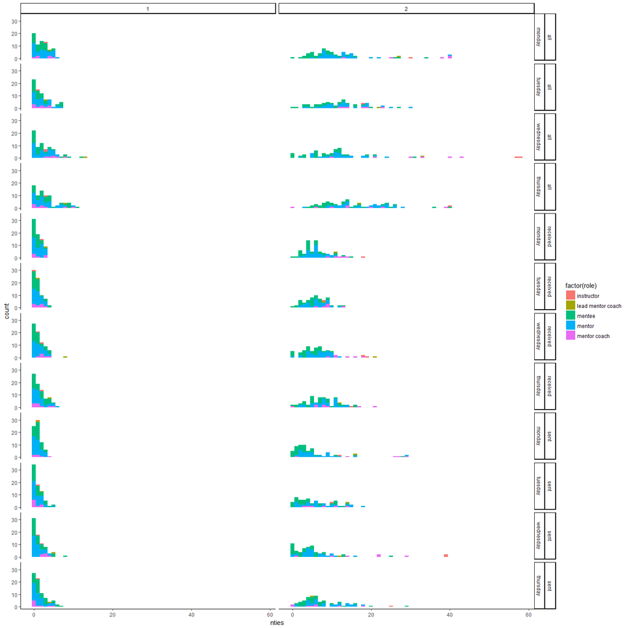

```r
ties.tidy %>%
filter(surv == 1 | surv == 2) %>%
ggplot(aes(x = nties,     fill = factor(role)))  + geom_histogram(binwidth = 1) + facet_grid(type + night ~ surv) + theme_classic()
```

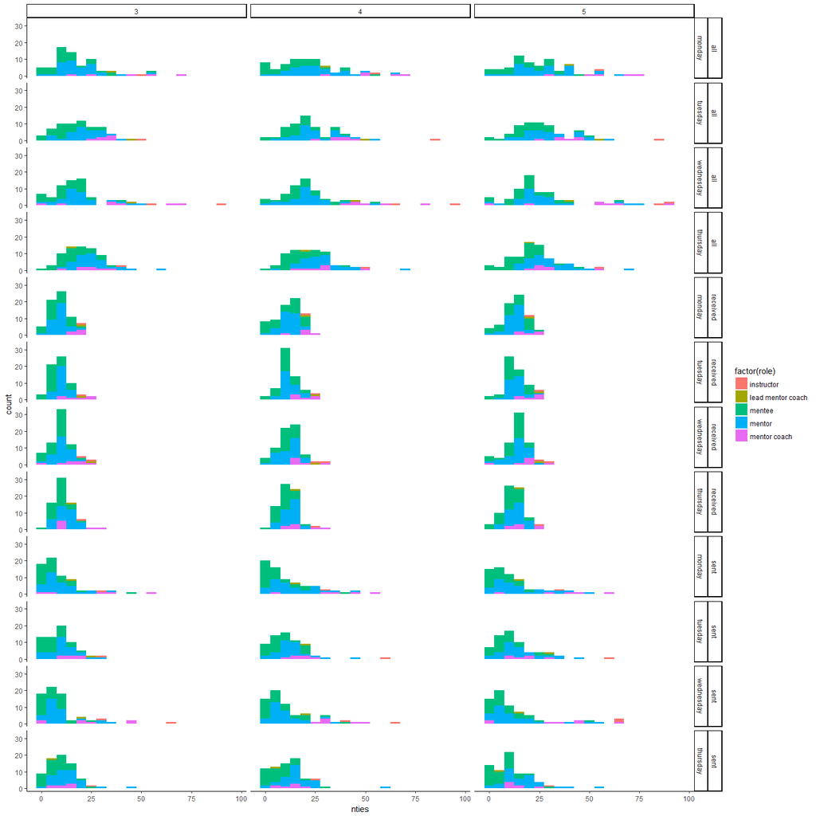

```r
ties.tidy %>%
filter(surv > 2) %>%
ggplot(aes(x = nties,     fill = factor(role)))  + geom_histogram(binwidth = 5) + facet_grid(type + night ~ surv) + theme_classic()
```

### S16

```r
dow <- "monday"
#survey 1
temp_surv <- as_data_frame(as.matrix(as_adj(ALL$S16$monday$graphs$g1), rownames = TRUE), rownames = NA)
temp <- data.frame(matrix(nrow= nrow(temp_surv) , ncol= 0)) #blank dataframe
temp$sent     <- as_data_frame(as.matrix(rowSums(temp_surv)))
temp$received <- as_data_frame(as.matrix(colSums(temp_surv)))
temp$all      <- temp$sent + temp$received
temp <- as.matrix(temp)
rownames(temp) <- seq(nrow(temp)) #remove rownames
temp_surv <- temp_surv %>%
  tibble::rownames_to_column() %>%
  select(Final_ID = "rowname", everything())
temp_surv <- cbind(temp_surv, temp)
role <- staff_youth_att %>%
  mutate(
         night = if_else((!(is.na(night2)) & night2 == dow), night2, night1),
         role  = if_else((!(is.na(night2)) & night2 == dow), role2,  role1)) %>%
  filter(night == dow) %>%
  select(Final_ID, role)
ties1 <- left_join(temp_surv, role, by = "Final_ID") %>%
  mutate(surv = 1) %>%
  select(Final_ID, role, surv, sent, received, all)
#Survey 2
temp_surv <- as_data_frame(as.matrix(as_adj(ALL$S16$monday$graphs$g2), rownames = TRUE), rownames = NA)
temp <- data.frame(matrix(nrow= nrow(temp_surv) , ncol= 0)) #blank dataframe
temp$sent     <- as_data_frame(as.matrix(rowSums(temp_surv)))
temp$received <- as_data_frame(as.matrix(colSums(temp_surv)))
temp$all      <- temp$sent + temp$received
temp <- as.matrix(temp)
rownames(temp) <- seq(nrow(temp)) #remove rownames
temp_surv <- temp_surv %>%
  tibble::rownames_to_column() %>%
  select(Final_ID = "rowname", everything())
temp_surv <- cbind(temp_surv, temp)
role <- staff_youth_att %>%
  mutate(
         night = if_else((!(is.na(night2)) & night2 == dow), night2, night1),
         role  = if_else((!(is.na(night2)) & night2 == dow), role2,  role1)) %>%
  filter(night == dow) %>%
  select(Final_ID, role)
ties2 <- left_join(temp_surv, role, by = "Final_ID") %>%
  mutate(surv = 2) %>%
  select(Final_ID, role, surv, sent, received, all)
#Survey 3
temp_surv <- as_data_frame(as.matrix(as_adj(ALL$S16$monday$graphs$g3), rownames = TRUE), rownames = NA)
temp <- data.frame(matrix(nrow= nrow(temp_surv) , ncol= 0)) #blank dataframe
temp$sent     <- as_data_frame(as.matrix(rowSums(temp_surv)))
temp$received <- as_data_frame(as.matrix(colSums(temp_surv)))
temp$all      <- temp$sent + temp$received
temp <- as.matrix(temp)
rownames(temp) <- seq(nrow(temp)) #remove rownames
temp_surv <- temp_surv %>%
  tibble::rownames_to_column() %>%
  select(Final_ID = "rowname", everything())
temp_surv <- cbind(temp_surv, temp)
role <- staff_youth_att %>%
  mutate(
         night = if_else((!(is.na(night2)) & night2 == dow), night2, night1),
         role  = if_else((!(is.na(night2)) & night2 == dow), role2,  role1)) %>%
  filter(night == dow) %>%
  select(Final_ID, role)
ties3 <- left_join(temp_surv, role, by = "Final_ID") %>%
  mutate(surv = 3) %>%
  select(Final_ID, role, surv, sent, received, all)
#Survey 4
temp_surv <- as_data_frame(as.matrix(as_adj(ALL$S16$monday$graphs$g4), rownames = TRUE), rownames = NA)
temp <- data.frame(matrix(nrow= nrow(temp_surv) , ncol= 0)) #blank dataframe
temp$sent     <- as_data_frame(as.matrix(rowSums(temp_surv)))
temp$received <- as_data_frame(as.matrix(colSums(temp_surv)))
temp$all      <- temp$sent + temp$received
temp <- as.matrix(temp)
rownames(temp) <- seq(nrow(temp)) #remove rownames
temp_surv <- temp_surv %>%
  tibble::rownames_to_column() %>%
  select(Final_ID = "rowname", everything())
temp_surv <- cbind(temp_surv, temp)
role <- staff_youth_att %>%
  mutate(
         night = if_else((!(is.na(night2)) & night2 == dow), night2, night1),
         role  = if_else((!(is.na(night2)) & night2 == dow), role2,  role1)) %>%
  filter(night == dow) %>%
  select(Final_ID, role)
ties4 <- left_join(temp_surv, role, by = "Final_ID") %>%
  mutate(surv = 4) %>%
  select(Final_ID, role, surv, sent, received, all)
#Survey 5
temp_surv <- as_data_frame(as.matrix(as_adj(ALL$S16$monday$graphs$g5), rownames = TRUE), rownames = NA)
temp <- data.frame(matrix(nrow= nrow(temp_surv) , ncol= 0)) #blank dataframe
temp$sent     <- as_data_frame(as.matrix(rowSums(temp_surv)))
temp$received <- as_data_frame(as.matrix(colSums(temp_surv)))
temp$all      <- temp$sent + temp$received
temp <- as.matrix(temp)
rownames(temp) <- seq(nrow(temp)) #remove rownames
temp_surv <- temp_surv %>%
  tibble::rownames_to_column() %>%
  select(Final_ID = "rowname", everything())
temp_surv <- cbind(temp_surv, temp)
role <- staff_youth_att %>%
  mutate(
         night = if_else((!(is.na(night2)) & night2 == dow), night2, night1),
         role  = if_else((!(is.na(night2)) & night2 == dow), role2,  role1)) %>%
  filter(night == dow) %>%
  select(Final_ID, role)
ties5 <- left_join(temp_surv, role, by = "Final_ID") %>%
  mutate(surv = 5) %>%
  select(Final_ID, role, surv, sent, received, all)
ties <- rbind(ties1,ties2, ties3, ties4, ties5)
tiesm <- ties %>%
  mutate(night = dow)
#tidy data
ties.tidym <- ties %>%
  select(Final_ID, role, surv, sent, received, all) %>%
  gather(key, nties, -Final_ID, -surv, -role) %>%
  separate(key, "type") %>%
  mutate(night = factor(dow))
###TUESDAY
dow <- "tuesday"
#survey 1
temp_surv <- as_data_frame(as.matrix(as_adj(ALL$S16$tuesday$graphs$g1), rownames = TRUE), rownames = NA)
temp <- data.frame(matrix(nrow= nrow(temp_surv) , ncol= 0)) #blank dataframe
temp$sent     <- as_data_frame(as.matrix(rowSums(temp_surv)))
temp$received <- as_data_frame(as.matrix(colSums(temp_surv)))
temp$all      <- temp$sent + temp$received
temp <- as.matrix(temp)
rownames(temp) <- seq(nrow(temp)) #remove rownames
temp_surv <- temp_surv %>%
  tibble::rownames_to_column() %>%
  select(Final_ID = "rowname", everything())
temp_surv <- cbind(temp_surv, temp)
role <- staff_youth_att %>%
  mutate(
         night = if_else((!(is.na(night2)) & night2 == dow), night2, night1),
         role  = if_else((!(is.na(night2)) & night2 == dow), role2,  role1)) %>%
  filter(night == dow) %>%
  select(Final_ID, role)
ties1 <- left_join(temp_surv, role, by = "Final_ID") %>%
  mutate(surv = 1) %>%
  select(Final_ID, role, surv, sent, received, all)
#Survey 2
temp_surv <- as_data_frame(as.matrix(as_adj(ALL$S16$tuesday$graphs$g2), rownames = TRUE), rownames = NA)
temp <- data.frame(matrix(nrow= nrow(temp_surv) , ncol= 0)) #blank dataframe
temp$sent     <- as_data_frame(as.matrix(rowSums(temp_surv)))
temp$received <- as_data_frame(as.matrix(colSums(temp_surv)))
temp$all      <- temp$sent + temp$received
temp <- as.matrix(temp)
rownames(temp) <- seq(nrow(temp)) #remove rownames
temp_surv <- temp_surv %>%
  tibble::rownames_to_column() %>%
  select(Final_ID = "rowname", everything())
temp_surv <- cbind(temp_surv, temp)
role <- staff_youth_att %>%
  mutate(
         night = if_else((!(is.na(night2)) & night2 == dow), night2, night1),
         role  = if_else((!(is.na(night2)) & night2 == dow), role2,  role1)) %>%
  filter(night == dow) %>%
  select(Final_ID, role)
ties2 <- left_join(temp_surv, role, by = "Final_ID") %>%
  mutate(surv = 2) %>%
  select(Final_ID, role, surv, sent, received, all)
#Survey 3
temp_surv <- as_data_frame(as.matrix(as_adj(ALL$S16$tuesday$graphs$g3), rownames = TRUE), rownames = NA)
temp <- data.frame(matrix(nrow= nrow(temp_surv) , ncol= 0)) #blank dataframe
temp$sent     <- as_data_frame(as.matrix(rowSums(temp_surv)))
temp$received <- as_data_frame(as.matrix(colSums(temp_surv)))
temp$all      <- temp$sent + temp$received
temp <- as.matrix(temp)
rownames(temp) <- seq(nrow(temp)) #remove rownames
temp_surv <- temp_surv %>%
  tibble::rownames_to_column() %>%
  select(Final_ID = "rowname", everything())
temp_surv <- cbind(temp_surv, temp)
role <- staff_youth_att %>%
  mutate(
         night = if_else((!(is.na(night2)) & night2 == dow), night2, night1),
         role  = if_else((!(is.na(night2)) & night2 == dow), role2,  role1)) %>%
  filter(night == dow) %>%
  select(Final_ID, role)
ties3 <- left_join(temp_surv, role, by = "Final_ID") %>%
  mutate(surv = 3) %>%
  select(Final_ID, role, surv, sent, received, all)
#Survey 4
temp_surv <- as_data_frame(as.matrix(as_adj(ALL$S16$tuesday$graphs$g4), rownames = TRUE), rownames = NA)
temp <- data.frame(matrix(nrow= nrow(temp_surv) , ncol= 0)) #blank dataframe
temp$sent     <- as_data_frame(as.matrix(rowSums(temp_surv)))
temp$received <- as_data_frame(as.matrix(colSums(temp_surv)))
temp$all      <- temp$sent + temp$received
temp <- as.matrix(temp)
rownames(temp) <- seq(nrow(temp)) #remove rownames
temp_surv <- temp_surv %>%
  tibble::rownames_to_column() %>%
  select(Final_ID = "rowname", everything())
temp_surv <- cbind(temp_surv, temp)
role <- staff_youth_att %>%
  mutate(
         night = if_else((!(is.na(night2)) & night2 == dow), night2, night1),
         role  = if_else((!(is.na(night2)) & night2 == dow), role2,  role1)) %>%
  filter(night == dow) %>%
  select(Final_ID, role)
ties4 <- left_join(temp_surv, role, by = "Final_ID") %>%
  mutate(surv = 4) %>%
  select(Final_ID, role, surv, sent, received, all)
#Survey 5
temp_surv <- as_data_frame(as.matrix(as_adj(ALL$S16$tuesday$graphs$g5), rownames = TRUE), rownames = NA)
temp <- data.frame(matrix(nrow= nrow(temp_surv) , ncol= 0)) #blank dataframe
temp$sent     <- as_data_frame(as.matrix(rowSums(temp_surv)))
temp$received <- as_data_frame(as.matrix(colSums(temp_surv)))
temp$all      <- temp$sent + temp$received
temp <- as.matrix(temp)
rownames(temp) <- seq(nrow(temp)) #remove rownames
temp_surv <- temp_surv %>%
  tibble::rownames_to_column() %>%
  select(Final_ID = "rowname", everything())
temp_surv <- cbind(temp_surv, temp)
role <- staff_youth_att %>%
  mutate(
         night = if_else((!(is.na(night2)) & night2 == dow), night2, night1),
         role  = if_else((!(is.na(night2)) & night2 == dow), role2,  role1)) %>%
  filter(night == dow) %>%
  select(Final_ID, role)
ties5 <- left_join(temp_surv, role, by = "Final_ID") %>%
  mutate(surv = 5) %>%
  select(Final_ID, role, surv, sent, received, all)
ties <- rbind(ties1,ties2, ties3, ties4, ties5)
tiest <- ties %>%
  mutate(night = dow)
#tidy data
ties.tidyt <- ties %>%
  select(Final_ID, role, surv, sent, received, all) %>%
  gather(key, nties, -Final_ID, -surv, -role) %>%
  separate(key, "type") %>%
  mutate(night = factor(dow))
###Wednesday
dow <- "wednesday"
#survey 1
temp_surv <- as_data_frame(as.matrix(as_adj(ALL$S16$wednesday$graphs$g1), rownames = TRUE), rownames = NA)
temp <- data.frame(matrix(nrow= nrow(temp_surv) , ncol= 0)) #blank dataframe
temp$sent     <- as_data_frame(as.matrix(rowSums(temp_surv)))
temp$received <- as_data_frame(as.matrix(colSums(temp_surv)))
temp$all      <- temp$sent + temp$received
temp <- as.matrix(temp)
rownames(temp) <- seq(nrow(temp)) #remove rownames
temp_surv <- temp_surv %>%
  tibble::rownames_to_column() %>%
  select(Final_ID = "rowname", everything())
temp_surv <- cbind(temp_surv, temp)
role <- staff_youth_att %>%
  mutate(
         night = if_else((!(is.na(night2)) & night2 == dow), night2, night1),
         role  = if_else((!(is.na(night2)) & night2 == dow), role2,  role1)) %>%
  filter(night == dow) %>%
  select(Final_ID, role)
ties1 <- left_join(temp_surv, role, by = "Final_ID") %>%
  mutate(surv = 1) %>%
  select(Final_ID, role, surv, sent, received, all)
#Survey 2
temp_surv <- as_data_frame(as.matrix(as_adj(ALL$S16$wednesday$graphs$g2), rownames = TRUE), rownames = NA)
temp <- data.frame(matrix(nrow= nrow(temp_surv) , ncol= 0)) #blank dataframe
temp$sent     <- as_data_frame(as.matrix(rowSums(temp_surv)))
temp$received <- as_data_frame(as.matrix(colSums(temp_surv)))
temp$all      <- temp$sent + temp$received
temp <- as.matrix(temp)
rownames(temp) <- seq(nrow(temp)) #remove rownames
temp_surv <- temp_surv %>%
  tibble::rownames_to_column() %>%
  select(Final_ID = "rowname", everything())
temp_surv <- cbind(temp_surv, temp)
role <- staff_youth_att %>%
  mutate(
         night = if_else((!(is.na(night2)) & night2 == dow), night2, night1),
         role  = if_else((!(is.na(night2)) & night2 == dow), role2,  role1)) %>%
  filter(night == dow) %>%
  select(Final_ID, role)
```

```r
ties2 <- left_join(temp_surv, role, by = "Final_ID") %>%
  mutate(surv = 2) %>%
  select(Final_ID, role, surv, sent, received, all)
#Survey 3
temp_surv <- as_data_frame(as.matrix(as_adj(ALL$S16$wednesday$graphs$g3), rownames = TRUE), rownames = NA)
temp <- data.frame(matrix(nrow= nrow(temp_surv) , ncol= 0)) #blank dataframe
temp$sent     <- as_data_frame(as.matrix(rowSums(temp_surv)))
temp$received <- as_data_frame(as.matrix(colSums(temp_surv)))
temp$all      <- temp$sent + temp$received
temp <- as.matrix(temp)
rownames(temp) <- seq(nrow(temp)) #remove rownames
temp_surv <- temp_surv %>%
  tibble::rownames_to_column() %>%
  select(Final_ID = "rowname", everything())
temp_surv <- cbind(temp_surv, temp)
role <- staff_youth_att %>%
  mutate(
         night = if_else((!(is.na(night2)) & night2 == dow), night2, night1),
         role  = if_else((!(is.na(night2)) & night2 == dow), role2,  role1)) %>%
  filter(night == dow) %>%
  select(Final_ID, role)
ties3 <- left_join(temp_surv, role, by = "Final_ID") %>%
  mutate(surv = 3) %>%
  select(Final_ID, role, surv, sent, received, all)
#Survey 4
temp_surv <- as_data_frame(as.matrix(as_adj(ALL$S16$wednesday$graphs$g4), rownames = TRUE), rownames = NA)
temp <- data.frame(matrix(nrow= nrow(temp_surv) , ncol= 0)) #blank dataframe
temp$sent     <- as_data_frame(as.matrix(rowSums(temp_surv)))
temp$received <- as_data_frame(as.matrix(colSums(temp_surv)))
temp$all      <- temp$sent + temp$received
temp <- as.matrix(temp)
rownames(temp) <- seq(nrow(temp)) #remove rownames
temp_surv <- temp_surv %>%
  tibble::rownames_to_column() %>%
  select(Final_ID = "rowname", everything())
temp_surv <- cbind(temp_surv, temp)
role <- staff_youth_att %>%
  mutate(
         night = if_else((!(is.na(night2)) & night2 == dow), night2, night1),
         role  = if_else((!(is.na(night2)) & night2 == dow), role2,  role1)) %>%
  filter(night == dow) %>%
  select(Final_ID, role)
ties4 <- left_join(temp_surv, role, by = "Final_ID") %>%
  mutate(surv = 4) %>%
  select(Final_ID, role, surv, sent, received, all)
#Survey 5
temp_surv <- as_data_frame(as.matrix(as_adj(ALL$S16$wednesday$graphs$g5), rownames = TRUE), rownames = NA)
temp <- data.frame(matrix(nrow= nrow(temp_surv) , ncol= 0)) #blank dataframe
temp$sent     <- as_data_frame(as.matrix(rowSums(temp_surv)))
temp$received <- as_data_frame(as.matrix(colSums(temp_surv)))
temp$all      <- temp$sent + temp$received
temp <- as.matrix(temp)
rownames(temp) <- seq(nrow(temp)) #remove rownames
temp_surv <- temp_surv %>%
  tibble::rownames_to_column() %>%
  select(Final_ID = "rowname", everything())
temp_surv <- cbind(temp_surv, temp)
role <- staff_youth_att %>%
  mutate(
         night = if_else((!(is.na(night2)) & night2 == dow), night2, night1),
         role  = if_else((!(is.na(night2)) & night2 == dow), role2,  role1)) %>%
  filter(night == dow) %>%
  select(Final_ID, role)
ties5 <- left_join(temp_surv, role, by = "Final_ID") %>%
  mutate(surv = 5) %>%
  select(Final_ID, role, surv, sent, received, all)
ties <- rbind(ties1,ties2, ties3, ties4, ties5)
tiesw <- ties %>%
  mutate(night = dow)
#tidy data
ties.tidyw <- ties %>%
  select(Final_ID, role, surv, sent, received, all) %>%
  gather(key, nties, -Final_ID, -surv, -role) %>%
  separate(key, "type") %>%
  mutate(night = factor(dow))
###Wednesday
dow <- "thursday"
#survey 1
temp_surv <- as_data_frame(as.matrix(as_adj(ALL$S16$thursday$graphs$g1), rownames = TRUE), rownames = NA)
temp <- data.frame(matrix(nrow= nrow(temp_surv) , ncol= 0)) #blank dataframe
temp$sent     <- as_data_frame(as.matrix(rowSums(temp_surv)))
temp$received <- as_data_frame(as.matrix(colSums(temp_surv)))
temp$all      <- temp$sent + temp$received
temp <- as.matrix(temp)
rownames(temp) <- seq(nrow(temp)) #remove rownames
temp_surv <- temp_surv %>%
  tibble::rownames_to_column() %>%
  select(Final_ID = "rowname", everything())
temp_surv <- cbind(temp_surv, temp)
role <- staff_youth_att %>%
  mutate(
         night = if_else((!(is.na(night2)) & night2 == dow), night2, night1),
         role  = if_else((!(is.na(night2)) & night2 == dow), role2,  role1)) %>%
  filter(night == dow) %>%
  select(Final_ID, role)
ties1 <- left_join(temp_surv, role, by = "Final_ID") %>%
  mutate(surv = 1) %>%
  select(Final_ID, role, surv, sent, received, all)
#Survey 2
temp_surv <- as_data_frame(as.matrix(as_adj(ALL$S16$thursday$graphs$g2), rownames = TRUE), rownames = NA)
temp <- data.frame(matrix(nrow= nrow(temp_surv) , ncol= 0)) #blank dataframe
temp$sent     <- as_data_frame(as.matrix(rowSums(temp_surv)))
temp$received <- as_data_frame(as.matrix(colSums(temp_surv)))
temp$all      <- temp$sent + temp$received
temp <- as.matrix(temp)
rownames(temp) <- seq(nrow(temp)) #remove rownames
temp_surv <- temp_surv %>%
  tibble::rownames_to_column() %>%
  select(Final_ID = "rowname", everything())
temp_surv <- cbind(temp_surv, temp)
role <- staff_youth_att %>%
  mutate(
         night = if_else((!(is.na(night2)) & night2 == dow), night2, night1),
         role  = if_else((!(is.na(night2)) & night2 == dow), role2,  role1)) %>%
  filter(night == dow) %>%
  select(Final_ID, role)
ties2 <- left_join(temp_surv, role, by = "Final_ID") %>%
  mutate(surv = 2) %>%
  select(Final_ID, role, surv, sent, received, all)
#Survey 3
temp_surv <- as_data_frame(as.matrix(as_adj(ALL$S16$thursday$graphs$g3), rownames = TRUE), rownames = NA)
temp <- data.frame(matrix(nrow= nrow(temp_surv) , ncol= 0)) #blank dataframe
temp$sent     <- as_data_frame(as.matrix(rowSums(temp_surv)))
temp$received <- as_data_frame(as.matrix(colSums(temp_surv)))
temp$all      <- temp$sent + temp$received
temp <- as.matrix(temp)
rownames(temp) <- seq(nrow(temp)) #remove rownames
temp_surv <- temp_surv %>%
  tibble::rownames_to_column() %>%
  select(Final_ID = "rowname", everything())
temp_surv <- cbind(temp_surv, temp)
role <- staff_youth_att %>%
  mutate(
         night = if_else((!(is.na(night2)) & night2 == dow), night2, night1),
         role  = if_else((!(is.na(night2)) & night2 == dow), role2,  role1)) %>%
  filter(night == dow) %>%
  select(Final_ID, role)
ties3 <- left_join(temp_surv, role, by = "Final_ID") %>%
  mutate(surv = 3) %>%
  select(Final_ID, role, surv, sent, received, all)
#Survey 4
temp_surv <- as_data_frame(as.matrix(as_adj(ALL$S16$thursday$graphs$g4), rownames = TRUE), rownames = NA)
temp <- data.frame(matrix(nrow= nrow(temp_surv) , ncol= 0)) #blank dataframe
temp$sent     <- as_data_frame(as.matrix(rowSums(temp_surv)))
temp$received <- as_data_frame(as.matrix(colSums(temp_surv)))
temp$all      <- temp$sent + temp$received
temp <- as.matrix(temp)
rownames(temp) <- seq(nrow(temp)) #remove rownames
temp_surv <- temp_surv %>%
  tibble::rownames_to_column() %>%
  select(Final_ID = "rowname", everything())
temp_surv <- cbind(temp_surv, temp)
role <- staff_youth_att %>%
  mutate(
         night = if_else((!(is.na(night2)) & night2 == dow), night2, night1),
         role  = if_else((!(is.na(night2)) & night2 == dow), role2,  role1)) %>%
  filter(night == dow) %>%
  select(Final_ID, role)
ties4 <- left_join(temp_surv, role, by = "Final_ID") %>%
  mutate(surv = 4) %>%
  select(Final_ID, role, surv, sent, received, all)
#Survey 5
temp_surv <- as_data_frame(as.matrix(as_adj(ALL$S16$thursday$graphs$g5), rownames = TRUE), rownames = NA)
temp <- data.frame(matrix(nrow= nrow(temp_surv) , ncol= 0)) #blank dataframe
temp$sent     <- as_data_frame(as.matrix(rowSums(temp_surv)))
temp$received <- as_data_frame(as.matrix(colSums(temp_surv)))
temp$all      <- temp$sent + temp$received
temp <- as.matrix(temp)
rownames(temp) <- seq(nrow(temp)) #remove rownames
temp_surv <- temp_surv %>%
  tibble::rownames_to_column() %>%
  select(Final_ID = "rowname", everything())
temp_surv <- cbind(temp_surv, temp)
role <- staff_youth_att %>%
  mutate(
         night = if_else((!(is.na(night2)) & night2 == dow), night2, night1),
         role  = if_else((!(is.na(night2)) & night2 == dow), role2,  role1)) %>%
  filter(night == dow) %>%
  select(Final_ID, role)
ties5 <- left_join(temp_surv, role, by = "Final_ID") %>%
  mutate(surv = 5) %>%
  select(Final_ID, role, surv, sent, received, all)
ties <- rbind(ties1,ties2, ties3, ties4, ties5)
tiesr <- ties %>%
  mutate(night = dow)
#tidy data
ties.tidyr <- ties %>%
  select(Final_ID, role, surv, sent, received, all) %>%
  gather(key, nties, -Final_ID, -surv, -role) %>%
  separate(key, "type") %>%
  mutate(night = factor(dow))
ties.tidy <- rbind(
                    ties.tidym,
                    ties.tidyt,
                    ties.tidyw,
                    ties.tidyr
                   )
ties.wide <- rbind(
                    tiesm,
                    tiest,
                    tiesw,
                    tiesr
                  )
wideS16 <- ties.wide
check <- ties.tidy %>%
  group_by(Final_ID) %>%
  summarize(check = sum(surv)) %>%
  filter(check > 45)
check
```

| Final_ID | check |
| --- | --- |
| KCCS16_2006 | 48 |
| KCCS16_2020 | 60 |
| KCCS16_2032 | 54 |
| KCCS16_2056 | 66 |
| KCCS16_2078 | 48 |
| KCCS16_2098 | 48 |
| KCCS16_2146 | 57 |
| KCCS16_2160 | 48 |
| KCCS16_2166 | 48 |
| KCCS16_2169 | 48 |

[output cut: 65 more lines]

```r
tidy.ties <- list(S16 = ties.tidy)
sent <- ties.tidy %>%
  filter(type == "sent") %>%
  mutate(sent = nties) %>%
  select(-nties, -type)
received <- ties.tidy %>%
  filter(type == "received") %>%
  mutate(received = nties) %>%
  select(-nties, -type)
all <- ties.tidy %>%
  filter(type == "all") %>%
  mutate(all = nties) %>%
  select(-nties, -type)
ties.wide <- sent %>%
  merge(received, by = c("Final_ID", "surv", "night")) %>%
  merge(all, by = c("Final_ID", "surv", "night")) %>%
  select(-role.x, -role.y)
ties.wide <- ties.wide %>%
  group_by(Final_ID, surv, night) %>%
  slice(1)
write_csv(ties.wide, "C:/Users/ndyetz/Desktop/thao_relS16.csv", na = "")
#?write_csv
ties.tidy <- ties.tidy %>%
  arrange(Final_ID, surv)
rm(ties.wide)
#?spread
#rm(ties1);rm(ties2);rm(ties3);rm(ties4);rm(ties5)
#rm(temp);rm(temp_surv)
#rm(ties.tidym);rm(ties.tidyt);rm(ties.tidyw);rm(ties.tidyr)
```

### F16

```r
dow <- "monday"
#survey 1
temp_surv <- as_data_frame(as.matrix(as_adj(ALL$F16$monday$graphs$g1), rownames = TRUE), rownames = NA)
temp <- data.frame(matrix(nrow= nrow(temp_surv) , ncol= 0)) #blank dataframe
temp$sent     <- as_data_frame(as.matrix(rowSums(temp_surv)))
temp$received <- as_data_frame(as.matrix(colSums(temp_surv)))
temp$all      <- temp$sent + temp$received
temp <- as.matrix(temp)
rownames(temp) <- seq(nrow(temp)) #remove rownames
temp_surv <- temp_surv %>%
  tibble::rownames_to_column() %>%
  select(Final_ID = "rowname", everything())
temp_surv <- cbind(temp_surv, temp)
role <- staff_youth_att %>%
  mutate(
         night = if_else((!(is.na(night2)) & night2 == dow), night2, night1),
         role  = if_else((!(is.na(night2)) & night2 == dow), role2,  role1)) %>%
  filter(night == dow) %>%
  select(Final_ID, role)
ties1 <- left_join(temp_surv, role, by = "Final_ID") %>%
  mutate(surv = 1) %>%
  select(Final_ID, role, surv, sent, received, all)
#Survey 2
temp_surv <- as_data_frame(as.matrix(as_adj(ALL$F16$monday$graphs$g2), rownames = TRUE), rownames = NA)
temp <- data.frame(matrix(nrow= nrow(temp_surv) , ncol= 0)) #blank dataframe
temp$sent     <- as_data_frame(as.matrix(rowSums(temp_surv)))
temp$received <- as_data_frame(as.matrix(colSums(temp_surv)))
temp$all      <- temp$sent + temp$received
temp <- as.matrix(temp)
rownames(temp) <- seq(nrow(temp)) #remove rownames
temp_surv <- temp_surv %>%
  tibble::rownames_to_column() %>%
  select(Final_ID = "rowname", everything())
temp_surv <- cbind(temp_surv, temp)
role <- staff_youth_att %>%
  mutate(
         night = if_else((!(is.na(night2)) & night2 == dow), night2, night1),
         role  = if_else((!(is.na(night2)) & night2 == dow), role2,  role1)) %>%
  filter(night == dow) %>%
  select(Final_ID, role)
ties2 <- left_join(temp_surv, role, by = "Final_ID") %>%
  mutate(surv = 2) %>%
  select(Final_ID, role, surv, sent, received, all)
#Survey 3
temp_surv <- as_data_frame(as.matrix(as_adj(ALL$F16$monday$graphs$g3), rownames = TRUE), rownames = NA)
temp <- data.frame(matrix(nrow= nrow(temp_surv) , ncol= 0)) #blank dataframe
temp$sent     <- as_data_frame(as.matrix(rowSums(temp_surv)))
temp$received <- as_data_frame(as.matrix(colSums(temp_surv)))
temp$all      <- temp$sent + temp$received
temp <- as.matrix(temp)
rownames(temp) <- seq(nrow(temp)) #remove rownames
temp_surv <- temp_surv %>%
  tibble::rownames_to_column() %>%
  select(Final_ID = "rowname", everything())
temp_surv <- cbind(temp_surv, temp)
role <- staff_youth_att %>%
  mutate(
         night = if_else((!(is.na(night2)) & night2 == dow), night2, night1),
         role  = if_else((!(is.na(night2)) & night2 == dow), role2,  role1)) %>%
  filter(night == dow) %>%
  select(Final_ID, role)
ties3 <- left_join(temp_surv, role, by = "Final_ID") %>%
  mutate(surv = 3) %>%
  select(Final_ID, role, surv, sent, received, all)
#Survey 4
temp_surv <- as_data_frame(as.matrix(as_adj(ALL$F16$monday$graphs$g4), rownames = TRUE), rownames = NA)
temp <- data.frame(matrix(nrow= nrow(temp_surv) , ncol= 0)) #blank dataframe
temp$sent     <- as_data_frame(as.matrix(rowSums(temp_surv)))
temp$received <- as_data_frame(as.matrix(colSums(temp_surv)))
temp$all      <- temp$sent + temp$received
temp <- as.matrix(temp)
rownames(temp) <- seq(nrow(temp)) #remove rownames
temp_surv <- temp_surv %>%
  tibble::rownames_to_column() %>%
  select(Final_ID = "rowname", everything())
temp_surv <- cbind(temp_surv, temp)
role <- staff_youth_att %>%
  mutate(
         night = if_else((!(is.na(night2)) & night2 == dow), night2, night1),
         role  = if_else((!(is.na(night2)) & night2 == dow), role2,  role1)) %>%
  filter(night == dow) %>%
  select(Final_ID, role)
ties4 <- left_join(temp_surv, role, by = "Final_ID") %>%
  mutate(surv = 4) %>%
  select(Final_ID, role, surv, sent, received, all)
#Survey 5
temp_surv <- as_data_frame(as.matrix(as_adj(ALL$F16$monday$graphs$g5), rownames = TRUE), rownames = NA)
temp <- data.frame(matrix(nrow= nrow(temp_surv) , ncol= 0)) #blank dataframe
temp$sent     <- as_data_frame(as.matrix(rowSums(temp_surv)))
temp$received <- as_data_frame(as.matrix(colSums(temp_surv)))
temp$all      <- temp$sent + temp$received
temp <- as.matrix(temp)
rownames(temp) <- seq(nrow(temp)) #remove rownames
temp_surv <- temp_surv %>%
  tibble::rownames_to_column() %>%
  select(Final_ID = "rowname", everything())
temp_surv <- cbind(temp_surv, temp)
role <- staff_youth_att %>%
  mutate(
         night = if_else((!(is.na(night2)) & night2 == dow), night2, night1),
         role  = if_else((!(is.na(night2)) & night2 == dow), role2,  role1)) %>%
  filter(night == dow) %>%
  select(Final_ID, role)
ties5 <- left_join(temp_surv, role, by = "Final_ID") %>%
  mutate(surv = 5) %>%
  select(Final_ID, role, surv, sent, received, all)
ties <- rbind(ties1,ties2, ties3, ties4, ties5)
tiesm <- ties %>%
  mutate(night = dow)
#tidy data
ties.tidym <- ties %>%
  select(Final_ID, role, surv, sent, received, all) %>%
  gather(key, nties, -Final_ID, -surv, -role) %>%
  separate(key, "type") %>%
  mutate(night = factor(dow))
###TUESDAY
dow <- "tuesday"
#survey 1
temp_surv <- as_data_frame(as.matrix(as_adj(ALL$F16$tuesday$graphs$g1), rownames = TRUE), rownames = NA)
temp <- data.frame(matrix(nrow= nrow(temp_surv) , ncol= 0)) #blank dataframe
temp$sent     <- as_data_frame(as.matrix(rowSums(temp_surv)))
temp$received <- as_data_frame(as.matrix(colSums(temp_surv)))
temp$all      <- temp$sent + temp$received
temp <- as.matrix(temp)
rownames(temp) <- seq(nrow(temp)) #remove rownames
temp_surv <- temp_surv %>%
  tibble::rownames_to_column() %>%
  select(Final_ID = "rowname", everything())
temp_surv <- cbind(temp_surv, temp)
role <- staff_youth_att %>%
  mutate(
         night = if_else((!(is.na(night2)) & night2 == dow), night2, night1),
         role  = if_else((!(is.na(night2)) & night2 == dow), role2,  role1)) %>%
  filter(night == dow) %>%
  select(Final_ID, role)
ties1 <- left_join(temp_surv, role, by = "Final_ID") %>%
  mutate(surv = 1) %>%
  select(Final_ID, role, surv, sent, received, all)
#Survey 2
temp_surv <- as_data_frame(as.matrix(as_adj(ALL$F16$tuesday$graphs$g2), rownames = TRUE), rownames = NA)
temp <- data.frame(matrix(nrow= nrow(temp_surv) , ncol= 0)) #blank dataframe
temp$sent     <- as_data_frame(as.matrix(rowSums(temp_surv)))
temp$received <- as_data_frame(as.matrix(colSums(temp_surv)))
temp$all      <- temp$sent + temp$received
temp <- as.matrix(temp)
rownames(temp) <- seq(nrow(temp)) #remove rownames
temp_surv <- temp_surv %>%
  tibble::rownames_to_column() %>%
  select(Final_ID = "rowname", everything())
temp_surv <- cbind(temp_surv, temp)
role <- staff_youth_att %>%
  mutate(
         night = if_else((!(is.na(night2)) & night2 == dow), night2, night1),
         role  = if_else((!(is.na(night2)) & night2 == dow), role2,  role1)) %>%
  filter(night == dow) %>%
  select(Final_ID, role)
ties2 <- left_join(temp_surv, role, by = "Final_ID") %>%
  mutate(surv = 2) %>%
  select(Final_ID, role, surv, sent, received, all)
#Survey 3
temp_surv <- as_data_frame(as.matrix(as_adj(ALL$F16$tuesday$graphs$g3), rownames = TRUE), rownames = NA)
temp <- data.frame(matrix(nrow= nrow(temp_surv) , ncol= 0)) #blank dataframe
temp$sent     <- as_data_frame(as.matrix(rowSums(temp_surv)))
temp$received <- as_data_frame(as.matrix(colSums(temp_surv)))
temp$all      <- temp$sent + temp$received
temp <- as.matrix(temp)
rownames(temp) <- seq(nrow(temp)) #remove rownames
temp_surv <- temp_surv %>%
  tibble::rownames_to_column() %>%
  select(Final_ID = "rowname", everything())
temp_surv <- cbind(temp_surv, temp)
role <- staff_youth_att %>%
  mutate(
         night = if_else((!(is.na(night2)) & night2 == dow), night2, night1),
         role  = if_else((!(is.na(night2)) & night2 == dow), role2,  role1)) %>%
  filter(night == dow) %>%
  select(Final_ID, role)
ties3 <- left_join(temp_surv, role, by = "Final_ID") %>%
  mutate(surv = 3) %>%
  select(Final_ID, role, surv, sent, received, all)
#Survey 4
temp_surv <- as_data_frame(as.matrix(as_adj(ALL$F16$tuesday$graphs$g4), rownames = TRUE), rownames = NA)
temp <- data.frame(matrix(nrow= nrow(temp_surv) , ncol= 0)) #blank dataframe
temp$sent     <- as_data_frame(as.matrix(rowSums(temp_surv)))
temp$received <- as_data_frame(as.matrix(colSums(temp_surv)))
temp$all      <- temp$sent + temp$received
temp <- as.matrix(temp)
rownames(temp) <- seq(nrow(temp)) #remove rownames
temp_surv <- temp_surv %>%
  tibble::rownames_to_column() %>%
  select(Final_ID = "rowname", everything())
temp_surv <- cbind(temp_surv, temp)
role <- staff_youth_att %>%
  mutate(
         night = if_else((!(is.na(night2)) & night2 == dow), night2, night1),
         role  = if_else((!(is.na(night2)) & night2 == dow), role2,  role1)) %>%
  filter(night == dow) %>%
  select(Final_ID, role)
ties4 <- left_join(temp_surv, role, by = "Final_ID") %>%
  mutate(surv = 4) %>%
  select(Final_ID, role, surv, sent, received, all)
#Survey 5
temp_surv <- as_data_frame(as.matrix(as_adj(ALL$F16$tuesday$graphs$g5), rownames = TRUE), rownames = NA)
temp <- data.frame(matrix(nrow= nrow(temp_surv) , ncol= 0)) #blank dataframe
temp$sent     <- as_data_frame(as.matrix(rowSums(temp_surv)))
temp$received <- as_data_frame(as.matrix(colSums(temp_surv)))
temp$all      <- temp$sent + temp$received
temp <- as.matrix(temp)
rownames(temp) <- seq(nrow(temp)) #remove rownames
temp_surv <- temp_surv %>%
  tibble::rownames_to_column() %>%
  select(Final_ID = "rowname", everything())
temp_surv <- cbind(temp_surv, temp)
role <- staff_youth_att %>%
  mutate(
         night = if_else((!(is.na(night2)) & night2 == dow), night2, night1),
         role  = if_else((!(is.na(night2)) & night2 == dow), role2,  role1)) %>%
  filter(night == dow) %>%
  select(Final_ID, role)
ties5 <- left_join(temp_surv, role, by = "Final_ID") %>%
  mutate(surv = 5) %>%
  select(Final_ID, role, surv, sent, received, all)
ties <- rbind(ties1,ties2, ties3, ties4, ties5)
tiest <- ties %>%
  mutate(night = dow)
#tidy data
ties.tidyt <- ties %>%
  select(Final_ID, role, surv, sent, received, all) %>%
  gather(key, nties, -Final_ID, -surv, -role) %>%
  separate(key, "type") %>%
  mutate(night = factor(dow))
###Wednesday
dow <- "wednesday"
#survey 1
temp_surv <- as_data_frame(as.matrix(as_adj(ALL$F16$wednesday$graphs$g1), rownames = TRUE), rownames = NA)
temp <- data.frame(matrix(nrow= nrow(temp_surv) , ncol= 0)) #blank dataframe
temp$sent     <- as_data_frame(as.matrix(rowSums(temp_surv)))
temp$received <- as_data_frame(as.matrix(colSums(temp_surv)))
temp$all      <- temp$sent + temp$received
temp <- as.matrix(temp)
rownames(temp) <- seq(nrow(temp)) #remove rownames
temp_surv <- temp_surv %>%
  tibble::rownames_to_column() %>%
  select(Final_ID = "rowname", everything())
temp_surv <- cbind(temp_surv, temp)
role <- staff_youth_att %>%
  mutate(
         night = if_else((!(is.na(night2)) & night2 == dow), night2, night1),
         role  = if_else((!(is.na(night2)) & night2 == dow), role2,  role1)) %>%
  filter(night == dow) %>%
  select(Final_ID, role)
ties1 <- left_join(temp_surv, role, by = "Final_ID") %>%
  mutate(surv = 1) %>%
  select(Final_ID, role, surv, sent, received, all)
#Survey 2
temp_surv <- as_data_frame(as.matrix(as_adj(ALL$F16$wednesday$graphs$g2), rownames = TRUE), rownames = NA)
temp <- data.frame(matrix(nrow= nrow(temp_surv) , ncol= 0)) #blank dataframe
temp$sent     <- as_data_frame(as.matrix(rowSums(temp_surv)))
temp$received <- as_data_frame(as.matrix(colSums(temp_surv)))
temp$all      <- temp$sent + temp$received
temp <- as.matrix(temp)
rownames(temp) <- seq(nrow(temp)) #remove rownames
temp_surv <- temp_surv %>%
  tibble::rownames_to_column() %>%
  select(Final_ID = "rowname", everything())
temp_surv <- cbind(temp_surv, temp)
role <- staff_youth_att %>%
  mutate(
         night = if_else((!(is.na(night2)) & night2 == dow), night2, night1),
         role  = if_else((!(is.na(night2)) & night2 == dow), role2,  role1)) %>%
  filter(night == dow) %>%
  select(Final_ID, role)
```

```r
ties2 <- left_join(temp_surv, role, by = "Final_ID") %>%
  mutate(surv = 2) %>%
  select(Final_ID, role, surv, sent, received, all)
#Survey 3
temp_surv <- as_data_frame(as.matrix(as_adj(ALL$F16$wednesday$graphs$g3), rownames = TRUE), rownames = NA)
temp <- data.frame(matrix(nrow= nrow(temp_surv) , ncol= 0)) #blank dataframe
temp$sent     <- as_data_frame(as.matrix(rowSums(temp_surv)))
temp$received <- as_data_frame(as.matrix(colSums(temp_surv)))
temp$all      <- temp$sent + temp$received
temp <- as.matrix(temp)
rownames(temp) <- seq(nrow(temp)) #remove rownames
temp_surv <- temp_surv %>%
  tibble::rownames_to_column() %>%
  select(Final_ID = "rowname", everything())
temp_surv <- cbind(temp_surv, temp)
role <- staff_youth_att %>%
  mutate(
         night = if_else((!(is.na(night2)) & night2 == dow), night2, night1),
         role  = if_else((!(is.na(night2)) & night2 == dow), role2,  role1)) %>%
  filter(night == dow) %>%
  select(Final_ID, role)
ties3 <- left_join(temp_surv, role, by = "Final_ID") %>%
  mutate(surv = 3) %>%
  select(Final_ID, role, surv, sent, received, all)
#Survey 4
temp_surv <- as_data_frame(as.matrix(as_adj(ALL$F16$wednesday$graphs$g4), rownames = TRUE), rownames = NA)
temp <- data.frame(matrix(nrow= nrow(temp_surv) , ncol= 0)) #blank dataframe
temp$sent     <- as_data_frame(as.matrix(rowSums(temp_surv)))
temp$received <- as_data_frame(as.matrix(colSums(temp_surv)))
temp$all      <- temp$sent + temp$received
temp <- as.matrix(temp)
rownames(temp) <- seq(nrow(temp)) #remove rownames
temp_surv <- temp_surv %>%
  tibble::rownames_to_column() %>%
  select(Final_ID = "rowname", everything())
temp_surv <- cbind(temp_surv, temp)
role <- staff_youth_att %>%
  mutate(
         night = if_else((!(is.na(night2)) & night2 == dow), night2, night1),
         role  = if_else((!(is.na(night2)) & night2 == dow), role2,  role1)) %>%
  filter(night == dow) %>%
  select(Final_ID, role)
ties4 <- left_join(temp_surv, role, by = "Final_ID") %>%
  mutate(surv = 4) %>%
  select(Final_ID, role, surv, sent, received, all)
#Survey 5
temp_surv <- as_data_frame(as.matrix(as_adj(ALL$F16$wednesday$graphs$g5), rownames = TRUE), rownames = NA)
temp <- data.frame(matrix(nrow= nrow(temp_surv) , ncol= 0)) #blank dataframe
temp$sent     <- as_data_frame(as.matrix(rowSums(temp_surv)))
temp$received <- as_data_frame(as.matrix(colSums(temp_surv)))
temp$all      <- temp$sent + temp$received
temp <- as.matrix(temp)
rownames(temp) <- seq(nrow(temp)) #remove rownames
temp_surv <- temp_surv %>%
  tibble::rownames_to_column() %>%
  select(Final_ID = "rowname", everything())
temp_surv <- cbind(temp_surv, temp)
role <- staff_youth_att %>%
  mutate(
         night = if_else((!(is.na(night2)) & night2 == dow), night2, night1),
         role  = if_else((!(is.na(night2)) & night2 == dow), role2,  role1)) %>%
  filter(night == dow) %>%
  select(Final_ID, role)
ties5 <- left_join(temp_surv, role, by = "Final_ID") %>%
  mutate(surv = 5) %>%
  select(Final_ID, role, surv, sent, received, all)
ties <- rbind(ties1,ties2, ties3, ties4, ties5)
tiesw <- ties %>%
  mutate(night = dow)
#tidy data
ties.tidyw <- ties %>%
  select(Final_ID, role, surv, sent, received, all) %>%
  gather(key, nties, -Final_ID, -surv, -role) %>%
  separate(key, "type") %>%
  mutate(night = factor(dow))
###Wednesday
dow <- "thursday"
#survey 1
temp_surv <- as_data_frame(as.matrix(as_adj(ALL$F16$thursday$graphs$g1), rownames = TRUE), rownames = NA)
temp <- data.frame(matrix(nrow= nrow(temp_surv) , ncol= 0)) #blank dataframe
temp$sent     <- as_data_frame(as.matrix(rowSums(temp_surv)))
temp$received <- as_data_frame(as.matrix(colSums(temp_surv)))
temp$all      <- temp$sent + temp$received
temp <- as.matrix(temp)
rownames(temp) <- seq(nrow(temp)) #remove rownames
temp_surv <- temp_surv %>%
  tibble::rownames_to_column() %>%
  select(Final_ID = "rowname", everything())
temp_surv <- cbind(temp_surv, temp)
role <- staff_youth_att %>%
  mutate(
         night = if_else((!(is.na(night2)) & night2 == dow), night2, night1),
         role  = if_else((!(is.na(night2)) & night2 == dow), role2,  role1)) %>%
  filter(night == dow) %>%
  select(Final_ID, role)
ties1 <- left_join(temp_surv, role, by = "Final_ID") %>%
  mutate(surv = 1) %>%
  select(Final_ID, role, surv, sent, received, all)
#Survey 2
temp_surv <- as_data_frame(as.matrix(as_adj(ALL$F16$thursday$graphs$g2), rownames = TRUE), rownames = NA)
temp <- data.frame(matrix(nrow= nrow(temp_surv) , ncol= 0)) #blank dataframe
temp$sent     <- as_data_frame(as.matrix(rowSums(temp_surv)))
temp$received <- as_data_frame(as.matrix(colSums(temp_surv)))
temp$all      <- temp$sent + temp$received
temp <- as.matrix(temp)
rownames(temp) <- seq(nrow(temp)) #remove rownames
temp_surv <- temp_surv %>%
  tibble::rownames_to_column() %>%
  select(Final_ID = "rowname", everything())
temp_surv <- cbind(temp_surv, temp)
role <- staff_youth_att %>%
  mutate(
         night = if_else((!(is.na(night2)) & night2 == dow), night2, night1),
         role  = if_else((!(is.na(night2)) & night2 == dow), role2,  role1)) %>%
  filter(night == dow) %>%
  select(Final_ID, role)
ties2 <- left_join(temp_surv, role, by = "Final_ID") %>%
  mutate(surv = 2) %>%
  select(Final_ID, role, surv, sent, received, all)
#Survey 3
temp_surv <- as_data_frame(as.matrix(as_adj(ALL$F16$thursday$graphs$g3), rownames = TRUE), rownames = NA)
temp <- data.frame(matrix(nrow= nrow(temp_surv) , ncol= 0)) #blank dataframe
temp$sent     <- as_data_frame(as.matrix(rowSums(temp_surv)))
temp$received <- as_data_frame(as.matrix(colSums(temp_surv)))
temp$all      <- temp$sent + temp$received
temp <- as.matrix(temp)
rownames(temp) <- seq(nrow(temp)) #remove rownames
temp_surv <- temp_surv %>%
  tibble::rownames_to_column() %>%
  select(Final_ID = "rowname", everything())
temp_surv <- cbind(temp_surv, temp)
role <- staff_youth_att %>%
  mutate(
         night = if_else((!(is.na(night2)) & night2 == dow), night2, night1),
         role  = if_else((!(is.na(night2)) & night2 == dow), role2,  role1)) %>%
  filter(night == dow) %>%
  select(Final_ID, role)
ties3 <- left_join(temp_surv, role, by = "Final_ID") %>%
  mutate(surv = 3) %>%
  select(Final_ID, role, surv, sent, received, all)
#Survey 4
temp_surv <- as_data_frame(as.matrix(as_adj(ALL$F16$thursday$graphs$g4), rownames = TRUE), rownames = NA)
temp <- data.frame(matrix(nrow= nrow(temp_surv) , ncol= 0)) #blank dataframe
temp$sent     <- as_data_frame(as.matrix(rowSums(temp_surv)))
temp$received <- as_data_frame(as.matrix(colSums(temp_surv)))
temp$all      <- temp$sent + temp$received
temp <- as.matrix(temp)
rownames(temp) <- seq(nrow(temp)) #remove rownames
temp_surv <- temp_surv %>%
  tibble::rownames_to_column() %>%
  select(Final_ID = "rowname", everything())
temp_surv <- cbind(temp_surv, temp)
role <- staff_youth_att %>%
  mutate(
         night = if_else((!(is.na(night2)) & night2 == dow), night2, night1),
         role  = if_else((!(is.na(night2)) & night2 == dow), role2,  role1)) %>%
  filter(night == dow) %>%
  select(Final_ID, role)
ties4 <- left_join(temp_surv, role, by = "Final_ID") %>%
  mutate(surv = 4) %>%
  select(Final_ID, role, surv, sent, received, all)
#Survey 5
temp_surv <- as_data_frame(as.matrix(as_adj(ALL$F16$thursday$graphs$g5), rownames = TRUE), rownames = NA)
temp <- data.frame(matrix(nrow= nrow(temp_surv) , ncol= 0)) #blank dataframe
temp$sent     <- as_data_frame(as.matrix(rowSums(temp_surv)))
temp$received <- as_data_frame(as.matrix(colSums(temp_surv)))
temp$all      <- temp$sent + temp$received
temp <- as.matrix(temp)
rownames(temp) <- seq(nrow(temp)) #remove rownames
temp_surv <- temp_surv %>%
  tibble::rownames_to_column() %>%
  select(Final_ID = "rowname", everything())
temp_surv <- cbind(temp_surv, temp)
role <- staff_youth_att %>%
  mutate(
         night = if_else((!(is.na(night2)) & night2 == dow), night2, night1),
         role  = if_else((!(is.na(night2)) & night2 == dow), role2,  role1)) %>%
  filter(night == dow) %>%
  select(Final_ID, role)
ties5 <- left_join(temp_surv, role, by = "Final_ID") %>%
  mutate(surv = 5) %>%
  select(Final_ID, role, surv, sent, received, all)
ties <- rbind(ties1,ties2, ties3, ties4, ties5)
tiesr <- ties %>%
  mutate(night = dow)
#tidy data
ties.tidyr <- ties %>%
  select(Final_ID, role, surv, sent, received, all) %>%
  gather(key, nties, -Final_ID, -surv, -role) %>%
  separate(key, "type") %>%
  mutate(night = factor(dow))
ties.tidy <- rbind(
                    ties.tidym,
                    ties.tidyt,
                    ties.tidyw,
                    ties.tidyr
                   )
ties.wide <- rbind(
                    tiesm,
                    tiest,
                    tiesw,
                    tiesr
                  )
wideF16 <- ties.wide
check <- ties.tidy %>%
  group_by(Final_ID) %>%
  summarize(check = sum(surv)) %>%
  filter(check > 45)
check
```

| Final_ID | check |
| --- | --- |
| KCCF16_3018 | 48 |
| KCCF16_3040 | 48 |
| KCCF16_3228 | 48 |
| KCCF16_3259 | 51 |
| KCCF16_3281 | 48 |
| KCCF16_3284 | 54 |
| KCCF16_3308 | 57 |
| KCCF16_3318 | 48 |
| KCCF16_3384 | 48 |
| KCCF16_3489 | 63 |

[output cut: 50 more lines]

```r
tidy.ties <- list(F16 = ties.tidy)
sent <- ties.tidy %>%
  filter(type == "sent") %>%
  mutate(sent = nties) %>%
  select(-nties, -type)
received <- ties.tidy %>%
  filter(type == "received") %>%
  mutate(received = nties) %>%
  select(-nties, -type)
all <- ties.tidy %>%
  filter(type == "all") %>%
  mutate(all = nties) %>%
  select(-nties, -type)
ties.wide <- sent %>%
  merge(received, by = c("Final_ID", "surv", "night")) %>%
  merge(all, by = c("Final_ID", "surv", "night")) %>%
  select(-role.x, -role.y)
ties.wide <- ties.wide %>%
  group_by(Final_ID, surv, night) %>%
  slice(1)
write_csv(ties.wide, "C:/Users/ndyetz/Desktop/thao_relF16.csv", na = "")
#?write_csv
ties.tidy <- ties.tidy %>%
  arrange(Final_ID, surv)
rm(ties.wide)
#?spread
#rm(ties1);rm(ties2);rm(ties3);rm(ties4);rm(ties5)
#rm(temp);rm(temp_surv)
#rm(ties.tidym);rm(ties.tidyt);rm(ties.tidyw);rm(ties.tidyr)
```

### S17

```r
dow <- "monday"
#survey 1
temp_surv <- as_data_frame(as.matrix(as_adj(ALL$S17$monday$graphs$g1), rownames = TRUE), rownames = NA)
temp <- data.frame(matrix(nrow= nrow(temp_surv) , ncol= 0)) #blank dataframe
temp$sent     <- as_data_frame(as.matrix(rowSums(temp_surv)))
temp$received <- as_data_frame(as.matrix(colSums(temp_surv)))
temp$all      <- temp$sent + temp$received
temp <- as.matrix(temp)
rownames(temp) <- seq(nrow(temp)) #remove rownames
temp_surv <- temp_surv %>%
  tibble::rownames_to_column() %>%
  select(Final_ID = "rowname", everything())
temp_surv <- cbind(temp_surv, temp)
role <- staff_youth_att %>%
  mutate(
         night = if_else((!(is.na(night2)) & night2 == dow), night2, night1),
         role  = if_else((!(is.na(night2)) & night2 == dow), role2,  role1)) %>%
  filter(night == dow) %>%
  select(Final_ID, role)
ties1 <- left_join(temp_surv, role, by = "Final_ID") %>%
  mutate(surv = 1) %>%
  select(Final_ID, role, surv, sent, received, all)
#Survey 2
temp_surv <- as_data_frame(as.matrix(as_adj(ALL$S17$monday$graphs$g2), rownames = TRUE), rownames = NA)
temp <- data.frame(matrix(nrow= nrow(temp_surv) , ncol= 0)) #blank dataframe
temp$sent     <- as_data_frame(as.matrix(rowSums(temp_surv)))
temp$received <- as_data_frame(as.matrix(colSums(temp_surv)))
temp$all      <- temp$sent + temp$received
temp <- as.matrix(temp)
rownames(temp) <- seq(nrow(temp)) #remove rownames
temp_surv <- temp_surv %>%
  tibble::rownames_to_column() %>%
  select(Final_ID = "rowname", everything())
temp_surv <- cbind(temp_surv, temp)
role <- staff_youth_att %>%
  mutate(
         night = if_else((!(is.na(night2)) & night2 == dow), night2, night1),
         role  = if_else((!(is.na(night2)) & night2 == dow), role2,  role1)) %>%
  filter(night == dow) %>%
  select(Final_ID, role)
ties2 <- left_join(temp_surv, role, by = "Final_ID") %>%
  mutate(surv = 2) %>%
  select(Final_ID, role, surv, sent, received, all)
#Survey 3
temp_surv <- as_data_frame(as.matrix(as_adj(ALL$S17$monday$graphs$g3), rownames = TRUE), rownames = NA)
temp <- data.frame(matrix(nrow= nrow(temp_surv) , ncol= 0)) #blank dataframe
temp$sent     <- as_data_frame(as.matrix(rowSums(temp_surv)))
temp$received <- as_data_frame(as.matrix(colSums(temp_surv)))
temp$all      <- temp$sent + temp$received
temp <- as.matrix(temp)
rownames(temp) <- seq(nrow(temp)) #remove rownames
temp_surv <- temp_surv %>%
  tibble::rownames_to_column() %>%
  select(Final_ID = "rowname", everything())
temp_surv <- cbind(temp_surv, temp)
role <- staff_youth_att %>%
  mutate(
         night = if_else((!(is.na(night2)) & night2 == dow), night2, night1),
         role  = if_else((!(is.na(night2)) & night2 == dow), role2,  role1)) %>%
  filter(night == dow) %>%
  select(Final_ID, role)
ties3 <- left_join(temp_surv, role, by = "Final_ID") %>%
  mutate(surv = 3) %>%
  select(Final_ID, role, surv, sent, received, all)
#Survey 4
temp_surv <- as_data_frame(as.matrix(as_adj(ALL$S17$monday$graphs$g4), rownames = TRUE), rownames = NA)
temp <- data.frame(matrix(nrow= nrow(temp_surv) , ncol= 0)) #blank dataframe
temp$sent     <- as_data_frame(as.matrix(rowSums(temp_surv)))
temp$received <- as_data_frame(as.matrix(colSums(temp_surv)))
temp$all      <- temp$sent + temp$received
temp <- as.matrix(temp)
rownames(temp) <- seq(nrow(temp)) #remove rownames
temp_surv <- temp_surv %>%
  tibble::rownames_to_column() %>%
  select(Final_ID = "rowname", everything())
temp_surv <- cbind(temp_surv, temp)
role <- staff_youth_att %>%
  mutate(
         night = if_else((!(is.na(night2)) & night2 == dow), night2, night1),
         role  = if_else((!(is.na(night2)) & night2 == dow), role2,  role1)) %>%
  filter(night == dow) %>%
  select(Final_ID, role)
ties4 <- left_join(temp_surv, role, by = "Final_ID") %>%
  mutate(surv = 4) %>%
  select(Final_ID, role, surv, sent, received, all)
#Survey 5
temp_surv <- as_data_frame(as.matrix(as_adj(ALL$S17$monday$graphs$g5), rownames = TRUE), rownames = NA)
temp <- data.frame(matrix(nrow= nrow(temp_surv) , ncol= 0)) #blank dataframe
temp$sent     <- as_data_frame(as.matrix(rowSums(temp_surv)))
temp$received <- as_data_frame(as.matrix(colSums(temp_surv)))
temp$all      <- temp$sent + temp$received
temp <- as.matrix(temp)
rownames(temp) <- seq(nrow(temp)) #remove rownames
temp_surv <- temp_surv %>%
  tibble::rownames_to_column() %>%
  select(Final_ID = "rowname", everything())
temp_surv <- cbind(temp_surv, temp)
role <- staff_youth_att %>%
  mutate(
         night = if_else((!(is.na(night2)) & night2 == dow), night2, night1),
         role  = if_else((!(is.na(night2)) & night2 == dow), role2,  role1)) %>%
  filter(night == dow) %>%
  select(Final_ID, role)
ties5 <- left_join(temp_surv, role, by = "Final_ID") %>%
  mutate(surv = 5) %>%
  select(Final_ID, role, surv, sent, received, all)
ties <- rbind(ties1,ties2, ties3, ties4, ties5)
tiesm <- ties %>%
  mutate(night = dow)
#tidy data
ties.tidym <- ties %>%
  select(Final_ID, role, surv, sent, received, all) %>%
  gather(key, nties, -Final_ID, -surv, -role) %>%
  separate(key, "type") %>%
  mutate(night = factor(dow))
###TUESDAY
dow <- "tuesday"
#survey 1
temp_surv <- as_data_frame(as.matrix(as_adj(ALL$S17$tuesday$graphs$g1), rownames = TRUE), rownames = NA)
temp <- data.frame(matrix(nrow= nrow(temp_surv) , ncol= 0)) #blank dataframe
temp$sent     <- as_data_frame(as.matrix(rowSums(temp_surv)))
temp$received <- as_data_frame(as.matrix(colSums(temp_surv)))
temp$all      <- temp$sent + temp$received
temp <- as.matrix(temp)
rownames(temp) <- seq(nrow(temp)) #remove rownames
temp_surv <- temp_surv %>%
  tibble::rownames_to_column() %>%
  select(Final_ID = "rowname", everything())
temp_surv <- cbind(temp_surv, temp)
role <- staff_youth_att %>%
  mutate(
         night = if_else((!(is.na(night2)) & night2 == dow), night2, night1),
         role  = if_else((!(is.na(night2)) & night2 == dow), role2,  role1)) %>%
  filter(night == dow) %>%
  select(Final_ID, role)
ties1 <- left_join(temp_surv, role, by = "Final_ID") %>%
  mutate(surv = 1) %>%
  select(Final_ID, role, surv, sent, received, all)
#Survey 2
temp_surv <- as_data_frame(as.matrix(as_adj(ALL$S17$tuesday$graphs$g2), rownames = TRUE), rownames = NA)
temp <- data.frame(matrix(nrow= nrow(temp_surv) , ncol= 0)) #blank dataframe
temp$sent     <- as_data_frame(as.matrix(rowSums(temp_surv)))
temp$received <- as_data_frame(as.matrix(colSums(temp_surv)))
temp$all      <- temp$sent + temp$received
temp <- as.matrix(temp)
rownames(temp) <- seq(nrow(temp)) #remove rownames
temp_surv <- temp_surv %>%
  tibble::rownames_to_column() %>%
  select(Final_ID = "rowname", everything())
temp_surv <- cbind(temp_surv, temp)
role <- staff_youth_att %>%
  mutate(
         night = if_else((!(is.na(night2)) & night2 == dow), night2, night1),
         role  = if_else((!(is.na(night2)) & night2 == dow), role2,  role1)) %>%
  filter(night == dow) %>%
  select(Final_ID, role)
ties2 <- left_join(temp_surv, role, by = "Final_ID") %>%
  mutate(surv = 2) %>%
  select(Final_ID, role, surv, sent, received, all)
#Survey 3
temp_surv <- as_data_frame(as.matrix(as_adj(ALL$S17$tuesday$graphs$g3), rownames = TRUE), rownames = NA)
temp <- data.frame(matrix(nrow= nrow(temp_surv) , ncol= 0)) #blank dataframe
temp$sent     <- as_data_frame(as.matrix(rowSums(temp_surv)))
temp$received <- as_data_frame(as.matrix(colSums(temp_surv)))
temp$all      <- temp$sent + temp$received
temp <- as.matrix(temp)
rownames(temp) <- seq(nrow(temp)) #remove rownames
temp_surv <- temp_surv %>%
  tibble::rownames_to_column() %>%
  select(Final_ID = "rowname", everything())
temp_surv <- cbind(temp_surv, temp)
role <- staff_youth_att %>%
  mutate(
         night = if_else((!(is.na(night2)) & night2 == dow), night2, night1),
         role  = if_else((!(is.na(night2)) & night2 == dow), role2,  role1)) %>%
  filter(night == dow) %>%
  select(Final_ID, role)
ties3 <- left_join(temp_surv, role, by = "Final_ID") %>%
  mutate(surv = 3) %>%
  select(Final_ID, role, surv, sent, received, all)
#Survey 4
temp_surv <- as_data_frame(as.matrix(as_adj(ALL$S17$tuesday$graphs$g4), rownames = TRUE), rownames = NA)
temp <- data.frame(matrix(nrow= nrow(temp_surv) , ncol= 0)) #blank dataframe
temp$sent     <- as_data_frame(as.matrix(rowSums(temp_surv)))
temp$received <- as_data_frame(as.matrix(colSums(temp_surv)))
temp$all      <- temp$sent + temp$received
temp <- as.matrix(temp)
rownames(temp) <- seq(nrow(temp)) #remove rownames
temp_surv <- temp_surv %>%
  tibble::rownames_to_column() %>%
  select(Final_ID = "rowname", everything())
temp_surv <- cbind(temp_surv, temp)
role <- staff_youth_att %>%
  mutate(
         night = if_else((!(is.na(night2)) & night2 == dow), night2, night1),
         role  = if_else((!(is.na(night2)) & night2 == dow), role2,  role1)) %>%
  filter(night == dow) %>%
  select(Final_ID, role)
ties4 <- left_join(temp_surv, role, by = "Final_ID") %>%
  mutate(surv = 4) %>%
  select(Final_ID, role, surv, sent, received, all)
#Survey 5
temp_surv <- as_data_frame(as.matrix(as_adj(ALL$S17$tuesday$graphs$g5), rownames = TRUE), rownames = NA)
temp <- data.frame(matrix(nrow= nrow(temp_surv) , ncol= 0)) #blank dataframe
temp$sent     <- as_data_frame(as.matrix(rowSums(temp_surv)))
temp$received <- as_data_frame(as.matrix(colSums(temp_surv)))
temp$all      <- temp$sent + temp$received
temp <- as.matrix(temp)
rownames(temp) <- seq(nrow(temp)) #remove rownames
temp_surv <- temp_surv %>%
  tibble::rownames_to_column() %>%
  select(Final_ID = "rowname", everything())
temp_surv <- cbind(temp_surv, temp)
role <- staff_youth_att %>%
  mutate(
         night = if_else((!(is.na(night2)) & night2 == dow), night2, night1),
         role  = if_else((!(is.na(night2)) & night2 == dow), role2,  role1)) %>%
  filter(night == dow) %>%
  select(Final_ID, role)
ties5 <- left_join(temp_surv, role, by = "Final_ID") %>%
  mutate(surv = 5) %>%
  select(Final_ID, role, surv, sent, received, all)
ties <- rbind(ties1,ties2, ties3, ties4, ties5)
tiest <- ties %>%
  mutate(night = dow)
#tidy data
ties.tidyt <- ties %>%
  select(Final_ID, role, surv, sent, received, all) %>%
  gather(key, nties, -Final_ID, -surv, -role) %>%
  separate(key, "type") %>%
  mutate(night = factor(dow))
###Wednesday
dow <- "wednesday"
#survey 1
temp_surv <- as_data_frame(as.matrix(as_adj(ALL$S17$wednesday$graphs$g1), rownames = TRUE), rownames = NA)
temp <- data.frame(matrix(nrow= nrow(temp_surv) , ncol= 0)) #blank dataframe
temp$sent     <- as_data_frame(as.matrix(rowSums(temp_surv)))
temp$received <- as_data_frame(as.matrix(colSums(temp_surv)))
temp$all      <- temp$sent + temp$received
temp <- as.matrix(temp)
rownames(temp) <- seq(nrow(temp)) #remove rownames
temp_surv <- temp_surv %>%
  tibble::rownames_to_column() %>%
  select(Final_ID = "rowname", everything())
temp_surv <- cbind(temp_surv, temp)
role <- staff_youth_att %>%
  mutate(
         night = if_else((!(is.na(night2)) & night2 == dow), night2, night1),
         role  = if_else((!(is.na(night2)) & night2 == dow), role2,  role1)) %>%
  filter(night == dow) %>%
  select(Final_ID, role)
ties1 <- left_join(temp_surv, role, by = "Final_ID") %>%
  mutate(surv = 1) %>%
  select(Final_ID, role, surv, sent, received, all)
#Survey 2
temp_surv <- as_data_frame(as.matrix(as_adj(ALL$S17$wednesday$graphs$g2), rownames = TRUE), rownames = NA)
temp <- data.frame(matrix(nrow= nrow(temp_surv) , ncol= 0)) #blank dataframe
temp$sent     <- as_data_frame(as.matrix(rowSums(temp_surv)))
temp$received <- as_data_frame(as.matrix(colSums(temp_surv)))
temp$all      <- temp$sent + temp$received
temp <- as.matrix(temp)
rownames(temp) <- seq(nrow(temp)) #remove rownames
temp_surv <- temp_surv %>%
  tibble::rownames_to_column() %>%
  select(Final_ID = "rowname", everything())
temp_surv <- cbind(temp_surv, temp)
role <- staff_youth_att %>%
  mutate(
         night = if_else((!(is.na(night2)) & night2 == dow), night2, night1),
         role  = if_else((!(is.na(night2)) & night2 == dow), role2,  role1)) %>%
  filter(night == dow) %>%
  select(Final_ID, role)
```

```r
ties2 <- left_join(temp_surv, role, by = "Final_ID") %>%
  mutate(surv = 2) %>%
  select(Final_ID, role, surv, sent, received, all)
#Survey 3
temp_surv <- as_data_frame(as.matrix(as_adj(ALL$S17$wednesday$graphs$g3), rownames = TRUE), rownames = NA)
temp <- data.frame(matrix(nrow= nrow(temp_surv) , ncol= 0)) #blank dataframe
temp$sent     <- as_data_frame(as.matrix(rowSums(temp_surv)))
temp$received <- as_data_frame(as.matrix(colSums(temp_surv)))
temp$all      <- temp$sent + temp$received
temp <- as.matrix(temp)
rownames(temp) <- seq(nrow(temp)) #remove rownames
temp_surv <- temp_surv %>%
  tibble::rownames_to_column() %>%
  select(Final_ID = "rowname", everything())
temp_surv <- cbind(temp_surv, temp)
role <- staff_youth_att %>%
  mutate(
         night = if_else((!(is.na(night2)) & night2 == dow), night2, night1),
         role  = if_else((!(is.na(night2)) & night2 == dow), role2,  role1)) %>%
  filter(night == dow) %>%
  select(Final_ID, role)
ties3 <- left_join(temp_surv, role, by = "Final_ID") %>%
  mutate(surv = 3) %>%
  select(Final_ID, role, surv, sent, received, all)
#Survey 4
temp_surv <- as_data_frame(as.matrix(as_adj(ALL$S17$wednesday$graphs$g4), rownames = TRUE), rownames = NA)
temp <- data.frame(matrix(nrow= nrow(temp_surv) , ncol= 0)) #blank dataframe
temp$sent     <- as_data_frame(as.matrix(rowSums(temp_surv)))
temp$received <- as_data_frame(as.matrix(colSums(temp_surv)))
temp$all      <- temp$sent + temp$received
temp <- as.matrix(temp)
rownames(temp) <- seq(nrow(temp)) #remove rownames
temp_surv <- temp_surv %>%
  tibble::rownames_to_column() %>%
  select(Final_ID = "rowname", everything())
temp_surv <- cbind(temp_surv, temp)
role <- staff_youth_att %>%
  mutate(
         night = if_else((!(is.na(night2)) & night2 == dow), night2, night1),
         role  = if_else((!(is.na(night2)) & night2 == dow), role2,  role1)) %>%
  filter(night == dow) %>%
  select(Final_ID, role)
ties4 <- left_join(temp_surv, role, by = "Final_ID") %>%
  mutate(surv = 4) %>%
  select(Final_ID, role, surv, sent, received, all)
#Survey 5
temp_surv <- as_data_frame(as.matrix(as_adj(ALL$S17$wednesday$graphs$g5), rownames = TRUE), rownames = NA)
temp <- data.frame(matrix(nrow= nrow(temp_surv) , ncol= 0)) #blank dataframe
temp$sent     <- as_data_frame(as.matrix(rowSums(temp_surv)))
temp$received <- as_data_frame(as.matrix(colSums(temp_surv)))
temp$all      <- temp$sent + temp$received
temp <- as.matrix(temp)
rownames(temp) <- seq(nrow(temp)) #remove rownames
temp_surv <- temp_surv %>%
  tibble::rownames_to_column() %>%
  select(Final_ID = "rowname", everything())
temp_surv <- cbind(temp_surv, temp)
role <- staff_youth_att %>%
  mutate(
         night = if_else((!(is.na(night2)) & night2 == dow), night2, night1),
         role  = if_else((!(is.na(night2)) & night2 == dow), role2,  role1)) %>%
  filter(night == dow) %>%
  select(Final_ID, role)
ties5 <- left_join(temp_surv, role, by = "Final_ID") %>%
  mutate(surv = 5) %>%
  select(Final_ID, role, surv, sent, received, all)
ties <- rbind(ties1,ties2, ties3, ties4, ties5)
tiesw <- ties %>%
  mutate(night = dow)
#tidy data
ties.tidyw <- ties %>%
  select(Final_ID, role, surv, sent, received, all) %>%
  gather(key, nties, -Final_ID, -surv, -role) %>%
  separate(key, "type") %>%
  mutate(night = factor(dow))
###Wednesday
dow <- "thursday"
#survey 1
temp_surv <- as_data_frame(as.matrix(as_adj(ALL$S17$thursday$graphs$g1), rownames = TRUE), rownames = NA)
temp <- data.frame(matrix(nrow= nrow(temp_surv) , ncol= 0)) #blank dataframe
temp$sent     <- as_data_frame(as.matrix(rowSums(temp_surv)))
temp$received <- as_data_frame(as.matrix(colSums(temp_surv)))
temp$all      <- temp$sent + temp$received
temp <- as.matrix(temp)
rownames(temp) <- seq(nrow(temp)) #remove rownames
temp_surv <- temp_surv %>%
  tibble::rownames_to_column() %>%
  select(Final_ID = "rowname", everything())
temp_surv <- cbind(temp_surv, temp)
role <- staff_youth_att %>%
  mutate(
         night = if_else((!(is.na(night2)) & night2 == dow), night2, night1),
         role  = if_else((!(is.na(night2)) & night2 == dow), role2,  role1)) %>%
  filter(night == dow) %>%
  select(Final_ID, role)
ties1 <- left_join(temp_surv, role, by = "Final_ID") %>%
  mutate(surv = 1) %>%
  select(Final_ID, role, surv, sent, received, all)
#Survey 2
temp_surv <- as_data_frame(as.matrix(as_adj(ALL$S17$thursday$graphs$g2), rownames = TRUE), rownames = NA)
temp <- data.frame(matrix(nrow= nrow(temp_surv) , ncol= 0)) #blank dataframe
temp$sent     <- as_data_frame(as.matrix(rowSums(temp_surv)))
temp$received <- as_data_frame(as.matrix(colSums(temp_surv)))
temp$all      <- temp$sent + temp$received
temp <- as.matrix(temp)
rownames(temp) <- seq(nrow(temp)) #remove rownames
temp_surv <- temp_surv %>%
  tibble::rownames_to_column() %>%
  select(Final_ID = "rowname", everything())
temp_surv <- cbind(temp_surv, temp)
role <- staff_youth_att %>%
  mutate(
         night = if_else((!(is.na(night2)) & night2 == dow), night2, night1),
         role  = if_else((!(is.na(night2)) & night2 == dow), role2,  role1)) %>%
  filter(night == dow) %>%
  select(Final_ID, role)
ties2 <- left_join(temp_surv, role, by = "Final_ID") %>%
  mutate(surv = 2) %>%
  select(Final_ID, role, surv, sent, received, all)
#Survey 3
temp_surv <- as_data_frame(as.matrix(as_adj(ALL$S17$thursday$graphs$g3), rownames = TRUE), rownames = NA)
temp <- data.frame(matrix(nrow= nrow(temp_surv) , ncol= 0)) #blank dataframe
temp$sent     <- as_data_frame(as.matrix(rowSums(temp_surv)))
temp$received <- as_data_frame(as.matrix(colSums(temp_surv)))
temp$all      <- temp$sent + temp$received
temp <- as.matrix(temp)
rownames(temp) <- seq(nrow(temp)) #remove rownames
temp_surv <- temp_surv %>%
  tibble::rownames_to_column() %>%
  select(Final_ID = "rowname", everything())
temp_surv <- cbind(temp_surv, temp)
role <- staff_youth_att %>%
  mutate(
         night = if_else((!(is.na(night2)) & night2 == dow), night2, night1),
         role  = if_else((!(is.na(night2)) & night2 == dow), role2,  role1)) %>%
  filter(night == dow) %>%
  select(Final_ID, role)
ties3 <- left_join(temp_surv, role, by = "Final_ID") %>%
  mutate(surv = 3) %>%
  select(Final_ID, role, surv, sent, received, all)
#Survey 4
temp_surv <- as_data_frame(as.matrix(as_adj(ALL$S17$thursday$graphs$g4), rownames = TRUE), rownames = NA)
temp <- data.frame(matrix(nrow= nrow(temp_surv) , ncol= 0)) #blank dataframe
temp$sent     <- as_data_frame(as.matrix(rowSums(temp_surv)))
temp$received <- as_data_frame(as.matrix(colSums(temp_surv)))
temp$all      <- temp$sent + temp$received
temp <- as.matrix(temp)
rownames(temp) <- seq(nrow(temp)) #remove rownames
temp_surv <- temp_surv %>%
  tibble::rownames_to_column() %>%
  select(Final_ID = "rowname", everything())
temp_surv <- cbind(temp_surv, temp)
role <- staff_youth_att %>%
  mutate(
         night = if_else((!(is.na(night2)) & night2 == dow), night2, night1),
         role  = if_else((!(is.na(night2)) & night2 == dow), role2,  role1)) %>%
  filter(night == dow) %>%
  select(Final_ID, role)
ties4 <- left_join(temp_surv, role, by = "Final_ID") %>%
  mutate(surv = 4) %>%
  select(Final_ID, role, surv, sent, received, all)
#Survey 5
temp_surv <- as_data_frame(as.matrix(as_adj(ALL$S17$thursday$graphs$g5), rownames = TRUE), rownames = NA)
temp <- data.frame(matrix(nrow= nrow(temp_surv) , ncol= 0)) #blank dataframe
temp$sent     <- as_data_frame(as.matrix(rowSums(temp_surv)))
temp$received <- as_data_frame(as.matrix(colSums(temp_surv)))
temp$all      <- temp$sent + temp$received
temp <- as.matrix(temp)
rownames(temp) <- seq(nrow(temp)) #remove rownames
temp_surv <- temp_surv %>%
  tibble::rownames_to_column() %>%
  select(Final_ID = "rowname", everything())
temp_surv <- cbind(temp_surv, temp)
role <- staff_youth_att %>%
  mutate(
         night = if_else((!(is.na(night2)) & night2 == dow), night2, night1),
         role  = if_else((!(is.na(night2)) & night2 == dow), role2,  role1)) %>%
  filter(night == dow) %>%
  select(Final_ID, role)
ties5 <- left_join(temp_surv, role, by = "Final_ID") %>%
  mutate(surv = 5) %>%
  select(Final_ID, role, surv, sent, received, all)
ties <- rbind(ties1,ties2, ties3, ties4, ties5)
tiesr <- ties %>%
  mutate(night = dow)
#tidy data
ties.tidyr <- ties %>%
  select(Final_ID, role, surv, sent, received, all) %>%
  gather(key, nties, -Final_ID, -surv, -role) %>%
  separate(key, "type") %>%
  mutate(night = factor(dow))
ties.tidy <- rbind(
                    ties.tidym,
                    ties.tidyt,
                    ties.tidyw,
                    ties.tidyr
                   )
ties.wide <- rbind(
                    tiesm,
                    tiest,
                    tiesw,
                    tiesr
                  )
wideS17 <- ties.wide
check <- ties.tidy %>%
  group_by(Final_ID) %>%
  summarize(check = sum(surv)) %>%
  filter(check > 45)
check
```

| Final_ID | check |
| --- | --- |
| KCCS17_4035 | 51 |
| KCCS17_4065 | 75 |
| KCCS17_4102 | 90 |
| KCCS17_4120 | 48 |
| KCCS17_4271 | 57 |
| KCCS17_4339 | 48 |
| KCCS17_4373 | 66 |
| KCCS17_4385 | 51 |
| KCCS17_4393 | 75 |
| KCCS17_4446 | 72 |

[output cut: 58 more lines]

```r
tidy.ties <- list(S17 = ties.tidy)
sent <- ties.tidy %>%
  filter(type == "sent") %>%
  mutate(sent = nties) %>%
  select(-nties, -type)
received <- ties.tidy %>%
  filter(type == "received") %>%
  mutate(received = nties) %>%
  select(-nties, -type)
all <- ties.tidy %>%
  filter(type == "all") %>%
  mutate(all = nties) %>%
  select(-nties, -type)
ties.wide <- sent %>%
  merge(received, by = c("Final_ID", "surv", "night")) %>%
  merge(all, by = c("Final_ID", "surv", "night")) %>%
  select(-role.x, -role.y)
ties.wide <- ties.wide %>%
  group_by(Final_ID, surv, night) %>%
  slice(1)
ties.wide <- ties.wide %>%
  filter(!is.na(role))
write_csv(ties.wide, "C:/Users/ndyetz/Desktop/thao_relS17.csv", na = "")
#?write_csv
ties.tidy <- ties.tidy %>%
  arrange(Final_ID, surv)
rm(ties.wide)
#?spread
#rm(ties1);rm(ties2);rm(ties3);rm(ties4);rm(ties5)
#rm(temp);rm(temp_surv)
#rm(ties.tidym);rm(ties.tidyt);rm(ties.tidyw);rm(ties.tidyr)
```

## Combine Semesters

```r
ties.wide <- rbind(
                    wideF15,
                    wideS16,
                    wideF16,
                    wideS17
                  )
ties.wide <- ties.wide %>%
  filter(!is.na(role))
ties.wide.m <- ties.wide %>%
  filter(role != "mentee") %>%
  group_by(Final_ID, surv, night) %>%
  slice(1)
#Have no idea why, but the youth data gets coerced into a list...Need to convert back into a data frame
ties.wide.m <- as_data_frame(ties.wide.m)
ties.wide.y <- ties.wide %>%
  filter(role == "mentee") %>%
  group_by(Final_ID, surv) %>%
  slice(1)
#Have no idea why, but the youth data gets coerced into a list...Need to convert back into a data frame
ties.wide.y <- as_data_frame(ties.wide.y)
ties.wide <- rbind(
                   ties.wide.m,
                   ties.wide.y
                  )
ties.wide <- ties.wide %>%
  arrange(Final_ID, surv)
```

# Network checks

```r
#Check for those that have MORE than 5 time points (No mentees should be here)
check <- ties.wide %>%
#  filter(role == "mentee") %>%
  group_by(Final_ID) %>%
  summarise(count = n()) %>%
  filter(count > 5)
#Check mentors that have more than 5 surveys to make sure they're not on the same night
check_nights <- ties.wide %>%
  right_join(check, by = "Final_ID") %>%
  arrange(Final_ID, night)
#Check how many people have LESS than 5 timepoints (Participants that dropped or came into the network late)
check2 <- ties.wide %>%
  group_by(Final_ID) %>%
  summarise(count = n()) %>%
  filter(count < 5)
```

# Write_CSV for thao

```r
write_csv(ties.wide, "C:/Users/ndyetz/Desktop/thao_rel.csv", na = "")
```